# The Synthetic Causal Framework

# 5 Analyses

With the overall aim of replicating the meta-analytic estimate of the effect of deservingness on welfare support, this section first covers (1) a confirmatory analysis that tests the hypothesized causal relationship between deservingness and welfare support (i.e., $H_1$). The robustness of the results are then assessed in (2) a sensitivity analysis, which includes numerous alternative model specifications, including a test of heterogenous effects across the specified characteristics, and a test of whether the partial violation of the simultaneity assumption results in time confounding the results. To test the hypothesis that results are the same whether derived from synthetic or human respondents (i.e., $H_2$), the section then (3) compares the results from the main analysis to the meta-analytic estimate derived from the human-based studies (i.e., Aarøe and Petersen 2014; Kane et al. 2023; Mummolo and Peterson 2019). Lastly, to provide researchers with an overview of the costs induced by using the *Synthetic Causal Framework* (SCF), (4) a cost analysis assesses the financial and time costs of its implementation as a *Synthetically Controlled Trial* (SCT).

## 5.1 Confirmatory Analysis

To test the theorized relationship between deservingness and welfare support ($H_1$), the specified multilevel Bayesian statistical model (see table 4.10) is fitted to the synthetic data. Similar to estimating the Bayesian models for the meta-analysis and the test of the simultaneity assumption, this procedures uses the NUTS Hamiltonian MCMC (Hoffman and Gelman 2014) of STAN (Stan Development Team 2024), implemented by the `brms` *R* package (Bürkner 2017, 2018), using 7 independent sampling chains, with 2,000 warmup samples per chain, followed by a total of approximately 40,000 post-warmup samples. For ease of overview, results are provided graphically and metrically. To give a sense of the difference in welfare support induced by the manipulations, predicted welfare support across manipulation conditions are illustrated in figure 5.1. For the exact difference, the posterior of the estimated difference across manipulation conditions is provided in figure 5.2. For summary estimates and model diagnostics, summary statistics in a metric format are provided in table 5.1. Model diagnostics and results not covered here are provided in the appendix.

Figure 5.1: Differences in Welfare Support across Manipulation Conditions

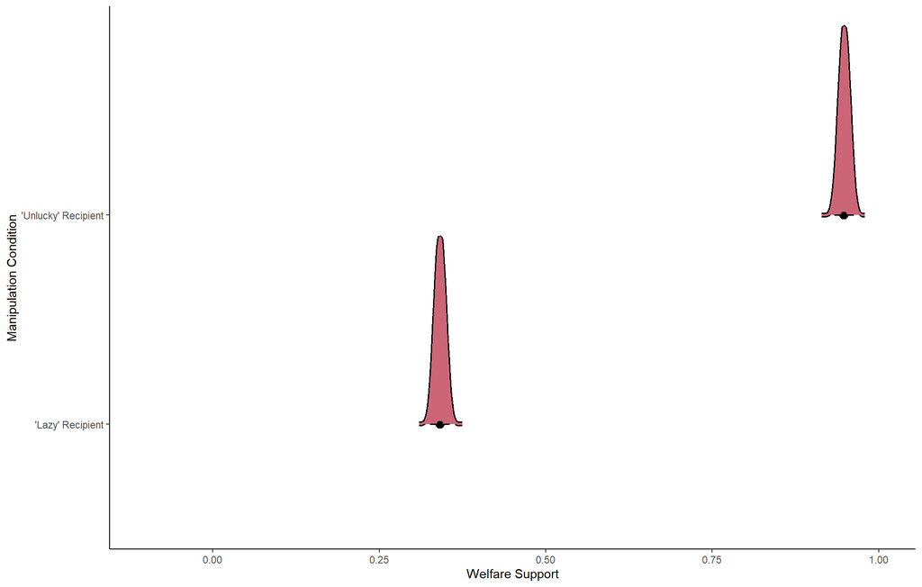

**NOTE**: Posterior distributions of the normalized (0 - 1) welfare support across group conditions. Posterior samples = 40,005. The geometric below the distributions indicate the posterior mode (circle) and the 95% HDCI. Results derived from synthetic data generated by OpenAI’s (2024a) gpt-4o-mini using vignettes and questions based on Aarøe and Petersen (2014) and Petersen et al. (2012), as well as data by the IPUMS (Ruggles et al. 2024) and ANES (2021).

To first assess, whether the results by the model are reliable, model diagnostics are inspected. These reveal that the posterior has been reliably identified, with chain convergence being ‘excellent’ ($\hat{R}$ < 1.01, Gelman and Rubin 1992; Vehtari et al. 2021), the effective sample size being ‘sufficient’ (ESS > 1,000, Bürkner 2017), and there is almost no sampling uncertainty (MCSE < .000, Kruschke 2014). By comparing the results to a Frequentist bootstrapped version of the same model (see the ‘Sentivity Analysis’-section), which found an overlap of 97.17% and no difference with 95% credibility, priors were validated as ‘noninformative’ relative to the data.[^29] In terms of the model’s goodness-of-fit, the *posterior predictive p-value* ($PP_P$, Gelman et al. 1996) of 0.942 indicates that the model tends to make exaggerated estimates of welfare support, but the Bayesian $R^2$ (Gelman et al. 2019) of .721 (SD = .011; 95% HDI[.701; .742]), by contrast, indicates that the model’s explanatory power can with 99.99% credibility be interpreted as ‘substantial’ (Cohen 1988), suggesting a relatively high fit. Since the results of the model are thus relatively reliable, with the priors being ‘noninformative’ relative to the data, focus can be directed to the model parameters, which can be used to assess whether deservingness increases welfare support (i.e., $H_1$).

Figure 5.2: Difference in Welfare Support for an ‘Unlucky’ Welfare Recipient compared to a ‘Lazy’ Welfare Recipient

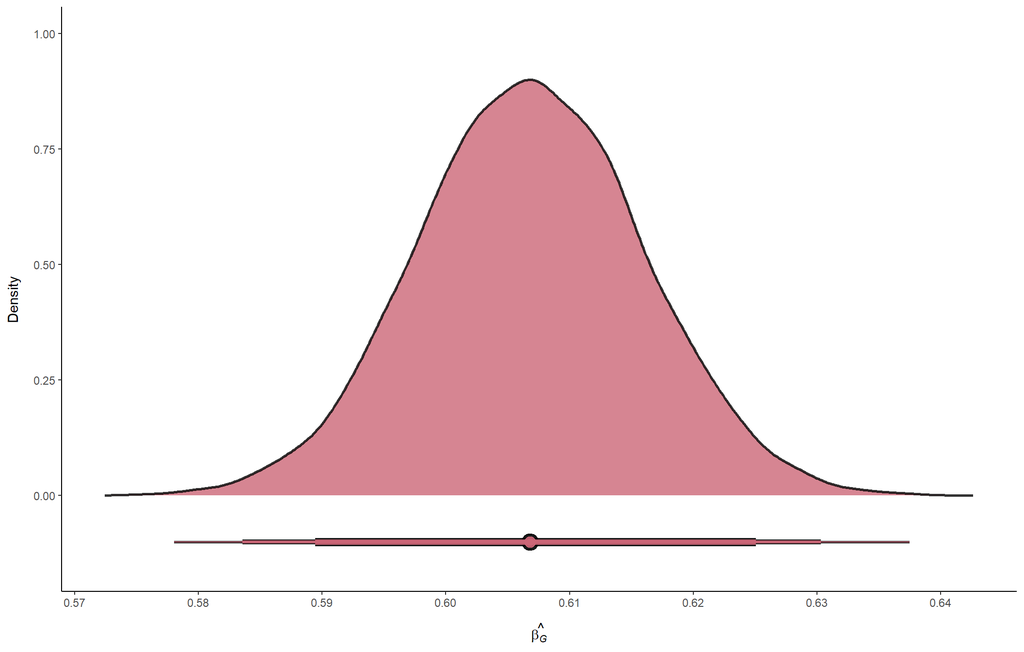

**NOTE**: Posterior distribution of the normalized (0 - 1) coefficient of deservingness on welfare support. Posterior samples = 40,005. The geometric below the distribution indicates the posterior mode (circle), the 95% HDCI (thick bar), 99% HDCI (thin bar), and 99.9% HDCI (line). Results derived from synthetic data generated by OpenAI’s (2024a) gpt-4o-mini using vignettes and questions based on Aarøe and Petersen (2014) and Petersen et al. (2012), as well as data by the IPUMS (Ruggles et al. 2024) and ANES (2021).

**Does deservingness increase welfare support?** Since the difference across the manipulation conditions are positive with 95% credibility, and the relative evidence (i.e., $BF_{1,0}$) overwhelmingly supports $H_1$, deservingness would seem to increase welfare support among synthetic respondents. This is indicated by the normalized (0 - 1) ‘deservingness’-coefficient of .607 (SD = .009; 95% HDI[.590; .625]; $ln(BF_{1,0})$ = 228.24), where the 95% *highest density interval* (HDI, cf. McElreath 2019: 56-58; Makowski et al. 2019a) indicates that the coefficient is positive and discernible from zero with 95% credibility. The estimated effect of deservingness on welfare support can, following King et al. (2000), specifically be interpreted as the following: *Ceteris paribus*, compared to seeing a ‘lazy’ welfare recipient (i.e., someone low in deservingness), an individual’s support for less strict requirements for welfare eligibility is on average 60.68 *percentage points (pp)* higher, plus or minus .91*pp*, and with 95% credibility between 58.96*pp* and 62.51*pp*, when seeing an ‘unlucky’ welfare recipient (i.e., someone high in deservingness).

Table 5.1: Relationship Between Deservingness & Welfare Support

| $\hat{\theta}$ | $Parameter$ | $Summary$ | $p$ | $ln(BF_{1,0})$ | $\hat{R}$ | $ESS$ | $MCSE$ | $Prior$ |
| --- | --- | --- | --- | --- | --- | --- | --- | --- |
| $\hat{\beta_G}$ | Deservingness | .607*** (.009) [.590; .625] | 0 | 228 | 1 | 81,461 | 0 | $\mathcal{T}_3(.000, .077)$ |
| $\hat{\mu_\alpha}$ | Intercept | .341*** (.008) [.326; .356] | 0 | 152 | 1 | 49,026 | 0 | $\mathcal{T}_3(.500, .039)$ |

**NOTE**: Bayesian Generalized Linear Model, estimated using Bayes MCMC with NUTS, with respondent ID-varying intercepts. Normalized coefficient posterior means (0 - 1) with standard deviations in parentheses and 95% HDI in brackets. Posterior samples = 40,005. $n$ = 2,018; $n_{ID}$ = 1,009. *p* = Two-tailed probability of at least as extreme a sample estimate if assuming no difference in the population: ${}^{\#}\!$p ≤ .1, ${}^{*}\!$p ≤ .05, ${}^{**}\!$p ≤ .01, ${}^{***}\!$p ≤ .001. $ln(BF_{1,0})$ = Natural-logarithm-scaled Bayes factor with the null-hypothesis ($H_0: \beta_G = 0$) in the denominator. $\hat{R}$ = Rubin-Gelman Convergence metric: ‘Excellent’ if < 1.01 (Vehtari et al. 2021), ‘Acceptable’ if < 1.1 (Gelman and Rubin 1992), otherwise ‘Unacceptable’. ESS = *Effective sample size*, ‘Sufficient’ if ≥ 1,000, otherwise ‘Insufficient’ (Bürkner 2017). MCSE = *Monte-Carlo Standard Error* (Kruschke 2014). $\mathcal{T}_3$ = *Student t* distribution with 3 degrees of freedom, both validated as ‘noninformative’ relative to the data. $PP_P$ (Gelman et al. 1996) = 0.942. Bayesian $R^2$ (Gelman et al. 2019) = .721 (SD = .011; 95% HDI[.701; .742]). RMSE ($\hat{\sigma}$) = .204 (SD = .005; 95% HDI[.195; .213]; $\hat{R}$ = 1; ESS = 15,715; MCSE = 0; Prior = $\mathcal{T}^{(0; \infty]}_3(.500, .039)$). Intercept (residual) dispersion ($\hat{\sigma_\alpha}$) = .126 (SD = .008; 95% HDI[.111; .141]; $\hat{R}$ = 1; ESS = 11,326; MCSE = 0; Prior = $\mathcal{T}^{(0; \infty]}_3(.000, .039)$). Model degrees of freedom ($\hat{\nu}$) = 1849.486 (SD = 172.901; 95% HDI[1531.889; 2017.997]; $\hat{R}$ = 1; ESS = 59,833; MCSE = 0.707; Prior = $\mathcal{T}^{(1; 2018)}_3(2013.000, 155.757)$). Results derived from synthetic data generated by OpenAI’s (2024a) gpt-4o-mini using vignettes and questions based on Aarøe and Petersen (2014) and Petersen et al. (2012), as well as data by the IPUMS (Ruggles et al. 2024) and ANES (2021).

These results are consistent with the theorized relationship and is further corroborated by the computed Bayes factor (i.e., $BF_{1,0}$, cf. Makowski et al. 2019a; Wagenmakers et al. 2010), which is reported on the natural-logarithmic scale due to its size. Assuming *a priori* that the hypothesized effect is as probable as the hypothesis of no effect, the $BF_{1,0}$ indicates that the hypothesized effect (i.e., $H_1$) is much more probable than the hypothesis of no effect given the data. Following the guidelines by Raftery (1995), the relative evidence provided by the $BF_{1,0}$ can specifically be interpreted to provide ‘very strong evidence in favour of’ the hypothesized relationship between deservingness and welfare support given the data. Having thus found substantial support for the hypothesized causal relationship between deservingness and welfare support among synthetic respondents ($H_1$), an assessment can be made regarding the robustness of these results.

## 5.2 Sensitivity Analysis

**Are the results robust?** With the estimates seeing no substantial difference as a result of changing the Bayesian model (table 4.10) to (1) a Frequentist bootstrapped version, (2) changing from random effects to fixed effects, (3) including interactions with the assigned characteristics, nor (4) omitting synthetic respondents for whom the measurement time difference was non-zero, this insensitivity to varying model specifications suggest that the results from the main analysis are generally robust. This is based on a *sensitivity analysis* (cf. Athey and Imbens 2017: 19-21), which involved 4 separate assessments, each focused on different aspects by which the results could vary as a function of the model specification. The first assessment addressed the reliance on Bayesian inference and the possible impact that the specification of priors could have on the results. The second assessment examined whether a change from the model’s random effects (i.e., ID-varying intercepts) to fixed effects impacted inference. The third assessment investigated the possibility of heterogenous treatment effects, which involved re-specifying the main model to include interactions with the assigned characteristics. The fourth assessment sought to address the possibility that the violation of the simultaneity assumption for some of the synthetic respondents (see the ‘Testing Simultaneity’-section) could confound the results.

Considering first the possibility that Bayesian inference involves specifying priors which may inadvertantly impact results due to being ‘strongly informative’ relatively to the data (Gelman et al. 2014: 55-56; Gelman et al. 2021: 123-127), the main model was changed to its Frequentist counterpart by omitting the priors. The Frequentist model was then estimated using *restricted maximum likelihood* (REML, Bates et al. 2015; Patterson and Thompson 1971), and for comparability with the Bayesian results, inferential statistics was estimated using the relatively computationally intensive *non-parametric bootstrap* (Efron 1979, 2003), with the number of permutations being equivalent to the Bayesian posterior samples (i.e., 40,005 permutations). Similar to the Frequentist counterpart-model estimated for the meta-analysis and simultaneity test, inferential statistics apply Frequentist *estimators* to produce *bias-reduced standard errors* (SE, Park et al. 2022; Park and Wang 2020, 2022) and *bias-corrected and accelerated* (BCa) confidence intervals (Efron 1987; Makowski et al. 2019a). The resulting estimated average effect of deservingness in this Frequentist model is .607 (SE = .009; 95% BCa[.590; .625]), indicating a 95% confident difference in welfare support of 60.74*pp* on average when exposed to a ‘unlucky’ welfare recipient compared to a ‘lazy’ welfare recipient, all else equal. This closely resembles the Bayesian estimate, and the exact difference is -.001 (SD = .013; 95% HDI[-.025; .025]), which indicates a negligible difference that is zero with 95% credibility. Accordingly, the impact of the priors is negligible, and they can be considered ‘noninformative’ relative to the data, showing that results are robust across the Bayesian and Frequentist approaches.

The second assessment involved changing the random effects of the Bayesian model to *fixed effects* (Wooldridge 2019: 463-472; Stock and Watson 2019: 367-376), with both random and fixed effects having their own advantages in different circumstances (Wooldridge 2019: 473-474; Rabe-Hesketh and Skrondal 2012: 95-97; McElreath 2019: 399-431). While fixed effects can remove all unit-invariant confounding (Wooldridge 2019: 463-472; Stock and Watson 2019: 367-376), since intra-unit comparisons are part of the identification strategy of the SCF, this property is already incorporated into the design of the SCF, and random effects were thus preferred for the main analysis due to its properties of *partial-pooling* making results more generalizable (Rabe-Hesketh and Skrondal 2012: 96; Yarkoni 2020) and less prone to overfitting (McElreath 2019: 399-431). Since a non-parametric bootstrap becomes more computationally demanding with fixed effects, inference for the Frequentist fixed-effects model solely relied on asymptotics (Stock and Watson 2019: 690-695; Wooldridge 2019: 117-180), employing 95% *equal-tailed confidence intervals* (Stock and Watson 2019: 117-118) and *cluster-robust standard errors* (Stock and Watson 2019: 376) to account for the multiple observations. Accordingly, the estimates are reported as provided by the statistical software used for this model (i.e., Bergé 2018) without applying extra bias-corrections. The results of this model are .607 (SE = .009; 95% CI[.590; .625]), and the fact that these estimates do *not* differ in any substantial way to the results from the main analysis indicates that the results are insensitive to the specification of random or fixed effects.

Having argued that assigning and generating life-histories based on nationally representative characteristics could make the behavior of the synthetic respondents more nuanced and realistic, a third assessment served to analyse whether the estimates varied across the assigned characteristics, which could imply that the assignment of nationally representative characteristics mattered for the results. This involved modifying the main model to include linear interactions between the manipulation condition and each characteristic. Similar to the Frequentist fixed-effects model, for computational ease, inference for the model relied on asymptotics. Due to the relatively large number of estimated parameters in this model, consistent with the Frequentist approach, the *p*-values are adjusted to account for the inflated *false-discovery rate* (FDR, Benjamini and Yekutieli 2001) associated with the *multiple comparisons* (Shaffer 1995; Wright 1992) made by the model. While a run-down of every parameter is beyond the scope of this paper, it should be briefly mentioned that, statistically discernible heterogenous deservingness-effects on welfare support were identified for political ideology and preferred political party ($p_{adj} \le .05$), and prior to the adjustments, interactions with sex, 2 levels of education, and 3 US states (i.e., Arkansas, Alabama, and Florida) were also confidently non-zero. Given the substantial statistical power necessary to identify interactions (Gelman et al. 2021), and the model’s assumption that the interactions for the continuous variables are linear, these results regarding the presence or absence of interactions should be taken with caution. The main takeaway of this assessment is that the interactions for some of the assigned characteristics are consistent with heterogenous effects, suggesting that the assignment of relevant characteristics from which to generate life-histories could indeed impact results and possibly make results more generalizable to the human population of interest.

The last assessment of robustness sought to address the finding that the simultaneity assumption appeared to have been violated for a relatively small subset of synthetic respondents. This was an issue, since it allowed time to possibly confound the results, because time-invariant confounders were no longer eliminated by design. An analysis of this possibility involved omitting all synthetic respondents for whom the time difference in measuring the counterfactual outcomes was non-zero, resulting in a nominal sample size of 946. Fitting a Frequentist non-parametric bootstrapped version of the main model to the long-form of this data, with inference again relying on the aforementioned bias-reduced estimators, this resulted in an estimated effect of deservingness of .607 (SE = .009; 95% BCa[.588; .625]). This estimate is with 95% confidence non-zero and of similar direction and magnitude as the main results. In fact, the exact difference is .000 (SD = .013; 95% HDI[-.025; .026]), which again is neglible and zero with 95% credibility. As such, when completely eliminating the possibility of time confounding results, there is no substantial impact on the main results, and the main results can be considered relatively robust to time confounding. With this sensitivity analysis in mind, the results can thus be considered robust. This leaves the question of whether this SCF-based approach has managed to adequately replicate the meta-analytic results derived from the human-based studies (i.e., $H_2$), which is addressed in the subsequent section.

## 5.3 Replication Analysis

**Do the results replicate the meta-analysis?** Comparing the SCF-based estimate derived from a synthetic sample to the meta-analytic estimate derived from human samples, while revealing varying magnitudes, they are both positive and discernible from zero with 95% credibility. Assessing the exact difference reveals support for $H_2$ with there being *no* difference with 95% credibility, and the results can be considered to replicate the meta-analysis. This is made evident by first comparing the results from the SCF-based main analysis to the human-based results from the Bayesian analysis. For robustness, this is followed by comparing the main results with the results from the aforementioned Frequentist meta-analysis.

To compare the Bayesian estimates from the main analysis with the meta-analytic estimate, recall that the results of the Bayesian meta-analysis of the human-based studies (i.e., Aarøe and Petersen 2014; Kane et al. 2023; Mummolo and Peterson 2019) revealed an uncertainty-weighted average estimated effect of deservingness on welfare support of .44 (SD = .12; 95% HDI[.12; .61]). Visually comparing the estimates reveals both to be positive and different from zero with 95% credibility, which can be taken as evidence that the SCF can produce estimates of similar direction and certainty as human-based studies. However, the SCF-based estimates do appear to be of a larger magnitude than the meta-analytic estimate, though it remains of a similar magnitude to the individual human-based studies by Mummelo and Peterson (2019, their MTurk study) and Kane et al. (2023) of approximately .550 (SE = .023; 95% CI[.505; .595]) and .583 (SE = .026; 95% CI[.532; .634], respectively. The fact that the human-based estimates are also of similarly larger magnitudes than the meta-analytic estimate is consistent with the SCF-based estimates similarly deviating from the meta-analytic mean due to the known properties of sampling variability and heterogeneous effects across studies. This can be further examined by computing the exact difference between the SCF-based and human-based results, revealing a difference (in *pp*) of 16.77 (SD = 11.92; 95% HDI[-1.14; 48.30]), which provides support for $H_2$ by indicating no systematic difference between the SCF-based and human-based estimates with 95% credibility.

To further ensure the robustness of this finding, the SCF-based results are also compared to the Frequentist-version of the meta-analysis, which yielded the aforementioned SE-weighted estimated average of .50 (SE = .06; 95% BCa[.38; .62]). Visually comparing these estimates to the SCF-based estimates leads to the same conclusions of similar direction and credibility of the results, with the exact difference (in *pp*) between the Frequentist meta-analytic estimate and the SCF-based estimate being 10.40 (SD = 6.43; 95% HDI[-1.37; 22.43]). While the SCF-based estimates again are somewhat exaggerated compared to the meta-analytic estimate, though now to a lesser extent and still of similar magnitude to results by Mummolo and Peterson (2019) and Kane et al. (2023), it can again be stated that there is *no* systematic difference between the estimates with 95% credibility, thus further supporting $H_2$.

Considering that the SCF manages to replicate the direction and credibility of human-based studies, with some exaggeration subject to sampling variability and study-based heterogeneity, this replication analysis do find relatively robust evidence that this SCF-based replication of the relationship between deservingness and welfare support among synthetic respondents succeeds in replicating the human-based results. With support for $H_2$ by merit of the similarity in the results, this demonstrates not just the high *internal validity* (cf. Stock and Watson 2019: 478-481) of the SCF, corroborating the theoretical justifications outlined in its conceptualization, but also its relatively high *external validity* (cf. Stock and Watson 2019: 481; Gelman et al. 2021: 354-355), as indicated by its ability to replicate the robust human-based causal relationship between deservingness and welfare support. As such, based on the analysis of this replication study, it is concluded that *the LLM-driven SCF, at least as implemented in the form of an SCT, is capable of generating causal estimates using an adequately-powered and representative sample of synthetic respondents, that if investigated in human populations, can be expected to replicate*. At the same time, despite the relatively large sample used here (*n* = 1,009), no single replication can ultimately validate a theoretical framework, and it thus remains a possibility that SCF-results can fail to generalize beyond the topic of deservingness and welfare support investigated in this study. Before discussing the implications of the formalization of the SCF, the novel concepts of synthetic units, ‘parallel worlds’-estimation, the SCT, its external validity, and this replication, a cost analysis will ascertain the financial and time costs of implementing the SCF as an SCT.

## 5.4 Cost Analysis

As the final part of the analysis of this demonstrative replication study and proof-of-concept of the SCF, this section ascertains the costs associated with the SCF. This serves to help researchers estimate the expected costs of relying on the SCF compared to using human samples. For this, it should be emphasized that all costs reported in this analysis are based on the application of the SCF specific to the replication study, such as the choice of the gpt-4o-mini LLM by Openai (2024a), the sample size, number of characteristics from which to generate life-histories, the length and wording of the life-history prompts, the token limitations on the output by the LLM, the length and wording of the prompt containing the manipulation conditions, and the number of manipulation conditions from which to generate counterfactual outcomes. Note also that the only costs considered for this analysis involves financial and time costs incurred from making requests to the LLM API, specifically the gpt-4o-mini LLM API by Openai (2024a), with usage costs being specific to the chosen LLM. Such costs incur due to the LLM using resources to process the prompt and generate a response output, with financial costs being tied to the length of the prompt in terms of tokens, with each token in a text-based prompt corresponding to approximately one word. At the same time, costs vary for input and output tokens. Researchers should keep in mind that while newer models may show better performance, that the selected gpt-4o-mini are among the cheapest and most cost-efficient at the time of writing (cf. OpenAI 2025b), charging on average 0.375 $US per 1,000,000 input/output tokens used. Besides considering financial costs, time costs are also considered, which involve the time that the LLM takes to process requests and the pauses enforced between making calls to the LLM to respect the time limits by OpenAI. With these considerations in mind, the financial and time costs incurred by relying on the SCF to generate the life-histories and the counterfactual outcomes can be estimated.

**Financial Costs**. In terms of financial costs, generating 1,009 life-histories and two counterfactual outcomes with the provided prompts and specified settings, the total cost is estimated to be .56 $US. This means that the expected financial cost per respondent is merely .001 (SD = .000) US dollars. Compared to studies that rely on human participants, this can be considered significantly cheap, especially considering that human-based studies may costs thousands of dollars to achieve a sample size compared to the 1,009 used in this replication study. At the same time, with an implementation of SCF as demonstrated here, saving the resources that it could otherwise cost to ensure that a human-based sample is representative could allow the researcher to re-allocate the resources where they are needed more. Similarly, while laboratory experiments and field experiments arguably do provide a high internal validity (Gerber and Green 2012), the SCF, as demonstrated here, provides a comparably high internal validity, and researchers may consider how many resources could be saved to working within the framework of the SCF.

**Time Costs**. Another relevant cost for researchers to consider is time costs. Generating the life-histories and the counterfactual outcomes for the ‘lazy’ and ‘unlucky’ welfare recipient manipulation conditions took a total of 374.76 minutes (i.e., 6.25 hours.). With 1,009 synthetic respondents, the expected time cost per respondent is 22.29 (SD = .00) seconds. Compared to human studies that may take months to obtain such a sample size, this can generally be considered a substantial reduction in the time taking to obtain this many survey responses. This means that researchers can save a substantial amount of time by applying the SCF to conduct an SCT compared to having to rely on human respondents, which can be considered advantageous, since their work effort can be dedicated more to doing research rather than waiting for data collection to finish.

Taken together, this cost analysis thus reveals that the SCF, through is implementation as an SCT, can be considered substantively less costly, both in terms of the financial and time resources needed to conduct a study. The demonstration has revealed that the SCF is capable is generating large and representative samples of data, where synthetic respondents can be subjected to numerous manipulation conditions to have their counterfactual outcomes generated in simultaneous and independent parallel processes, producing results that can generalize to human-based studies. The SCT can thus be expected to save surmountable resources for researchers, and the financial bar needed to conduct a study with a high internal validity and external validity is substantially lowered, thus increasing the ability of researchers to make reliable causal inferences across disciplines, particularly when the theorized cause is non-manipulable and where both the theorized cause and outcome are meaningfully expressible through natural language.

# 6 Discussion

With this paper having introduced the conceptualization of a novel causal framework, the *Synthetic Causal Framework* (SCF), theoretically outlined to enable *reliable causal inference when the theorized cause is non-manipulable in human populations*, it solves the existing issue of researchers being unable to manipulate relevant phenomena of interest (e.g., Buunk and van Vugt 2013: 17). Solving this issue was found to be especially pertinent given that practically any result derived from non-manipulated (i.e., *endogenous*) phenomena could, in principle, be subject to confounding (Fisher 1935; Greenland et al. 1999; VanderWeele and Shpitser 2013). As mentioned, while the existing concept of the *longitudinal design* (Wooldridge 2019: 7-10, 334-335) does help address the issue of *reverse causality* (cf. Hume 2011), for *any* endogenous phenomenon, *neither positive results nor negative results imply causality* (cf. Kennaway 2015; Manninen 2019c; Pearson 2015[1900]) due to the respective possibilities of *spuriousness* and *masking* (Gumbel 1933; McElreath 2019: 123-153; Stock and Watson 2019: 584-586). By recognizing that the burden of proof rests upon the researcher making a causal claim (cf. Cargile 1988; Hume 2010[1748]; Russo 2019; Sagan 1979), existing methods for making causal inference proved generally unreliable (e.g., Baker et al. 2022; Bertrand et al. 2004; Ferman 2023; Kahn-Lang and Lang 2020; Ryan et al. 2015; Samii 2016; Wan et al. 2024) due to their reliance on untestable and dubious assumptions that, contrary to best practice (cf. Rohrer 2018: 34; Stuart 2010: 3; Samii 2016), were *not* guaranteed by design. By contrast, the SCF does *not* suffer these limitations due to eliminating confounding *by design*. To gather the insights derived from its development, a summary and discussion of its theoretical formalization and empirical validation are provided in this section.

With a definition of causality based on the *Neyman-Rubin Potential Outcomes Framework* (POF, Holland 1986; Imbens 2015: 374-377; Imbens and Rubin 2015; Neyman 1923; Rubin 2005) as the *difference in potential outcomes between two physically and temporally distinct phenomena, with solely the temporally-precedent cause varying across the potential outcomes*, the SCF is formalized using the POF. As such, it can be considered as an extension of it, with the causal identification strategy of the SCF being directly derived from POF-based equations, which involve *intra-unit comparisons of simultaneous and independent counterfactual outcomes*. To enable this counterfactual comparison, the SCF is based on the theoretical foundation that language and behavior are closely related and mutually informative: The behavior of individuals shape their language, and their language shape their behavior (cf. Bandura 1999; Chung et al. 2007; Galton 1884; Holtgraves 2013; Lucy 1992; Pennebaker et al. 2003; Thibodeau and Boroditsky 2011; Whorf 2011[1956]). With *Large Language Models* (LLMs, Shanahan 2024) having proved increasingly capable of emulating human natural language and showing human-comparable performance in numerous disciplines (cf. Colette et al. 2024; Holderried et al. 2024; Jansen et al. 2023; Ornstein et al. 2024; Pang et al. 2024), the use of LLMs to emulate human behavior is paramount to the SCF. This also means that the SCF is formalized to enable reliable causal inference with non-manipulable phenomena in *human populations*, limiting its intended scope of application to topics belonging to the *social and behavioral sciences* (cf. Wright 2015). Accordingly, through its reliance on LLMs to achieve this goal, a key assumption of the SCF is that *the theorized cause and outcome must be meaningfully expressed through natural language*, and for the ability of the LLM to emulate behavior associated with the theorized cause and outcome, it must have been trained on data containing expressions of these phenomena. While these restrictions can limit the usefulness of the SCF, they nonetheless reflect relevant considerations about the areas of application for which the SCF can be considered meaningful. Similarly, explicitly specifying the intended scope and expected limitations serve to make researchers aware that the SCF may *not* be equally valid *nor* as reliable across all topics of interest and that applications outside of its intended area of application warrants further considerations, justification, and validation.

The reliance of the SCF on LLMs in emulating human behavior to enable the manipulation of a non-manipulable phenomena specifically involves the generation of *simulated units*. These units are defined here to possess human characteristics, whose inclusion serve as a basis to guide the behavior of the LLM when controlling each unit in a more nuanced and human-like direction. It is here important that an adequate number of relevant characteristics are simulated so that the resulting behavior becomes as realistic as possible. At the same time, since applications of the SCF will likely involve simulated samples of human units drawn from a particular population of interest, to enable better inference, it is important that the characteristics assigned to these units are simulated in proportion to their prevalence in that particular population. To further make the behavior of the LLM-controlled simulated units more realistic and generalizable, *life-histories* (cf. Schütze 2008) are generated by the LLM based on the assigned characteristics, enabling a more fleshed-out and realistic characterization of each unit. This step is taken to infuse the simulated units with human-nuance not captured by the assigned characteristics, resulting in these units being conceptually distinguished as *synthetic units*. With the intended use of the SCF being the inference of causality to human populations, the use of simulated data may be seen as invalid or meaningless because human units are not *directly* used in an SCF-based analysis. However, this criticism would fail to account for indirect way that human text-based behavioral data are used to train the LLMs, not to mention the existing use of simulated and synthetic data for research into real-world phenomena (e.g., Abowd et al. 2004; Emam et al. 2020; Kinney et al. 2011; Macy and Willer 2002; Nikolenko 2021; van Lange et al. 2013: 31; Zivenko et al. 2025). Similarly, from the recognized disciplines of *functionalist* and *behaviorist psychology* (Farrell 2014: 88, 111, 362-403), the study of human behavior does *not* necessitate the studied unit necessarily being human, with the key requirement instead being the respective functional or behavioral equivalence between humans and the studied unit. As long as researchers can plausibly justify why the function or behavior is expectedly similar, if not equivalent, between synthetic units and human units, SCF-based research can be considered valid and meaningfully inferrable to human populations.

Once synthetic units have been generated, each of these can be manipulated with respect to the theorized cause enabling reliable causal inference through the elimination of all unit- and time-invariant confounders. Similar to a *random assignment mechanism* (RAM) employed in *Randomized Controlled Trials* (RCTs, cf. Angrist and Pischke 2015: 1-46; Angrist and Pischke 2009: 15-22; Stock and Watson 2019: 48-49), the SCF employs a *simultaneous and independent exogenous assignment mechanism* (SIXAM), which simultaneously and independently assigns each synthetic unit to every manipulation condition through a parallel process, jointly referred to as *‘parallel worlds’-estimation*. The simultaneous and independent nature of this assignment helps eliminate most concerns for *pre-treatment* and *post-treatment biases* (cf. Linos and Twist 2018; Montgomery et al. 2018). Once a counterfactual outcome for each manipulation condition has been generated, intra-unit comparisons thus provide an unbiased and efficient strategy for causal identification (cf. Westreich et al. 2015). While this procedure essentially enables the researcher to multiply the initial sample of synthetic units by a factor equivalent to the number of manipulation conditions, this does result in a sample with *autocorrelated* observations (cf. Gelman et al. 2021: 459; Stock and Watson 2019: 375), since the multiple counterfactual observations are clustered around each synthetic unit. This, however, is not a critical concern, since the multiple observations of each unit easily addressed through the use of *multilevel statistical models* (cf. Gelman and Hill 2007) or alternatively through the use of *cluster-robust standard errors* (cf. Stock and Watson 2019: 376). One might criticize that the ability to eliminate unit-invariant and time-invariant confounders with these intra-unit comparisons of counterfactual outcomes may be invalid and/or unreliable by relying on dubious assumptions. For example, the ability to measure counterfactual outcomes for the same synthetic respondent assumes (1) that the LLM treats the synthetic unit as the exact same unit across the multiple manipulation conditions (e.g., prior to each manipulation conditions, unit *i* in manipulation condition *k* is exactly the same as unit *i* in manipulation condition *k’*), and (2) that the responses are generated simultaneously (i.e., the *simultaneity assumption*). As a response to these criticisms, it can be argued that the former assumption can be justified by stating that the units across the manipulation conditions are the same conditional on their life-histories, and should the LLM possibly infer different characteristics not specified in the life-histories conditional on the manipulation condition that this is *not* innately different from how varying manipulation conditions, such as *framing* or *priming* vignettes (cf. Bargh and Chartrand 2000; Tversky and Kahneman 1981), could affect the self-perceptions of human participants, with certain memories, characteristics, thoughts, and behaviors varying in saliency (see, e.g., Fausey and Boroditsky 2010; Thibodeau and Boroditsky 2011). Regarding the latter assumption, simultaneity can be promoted by implementing the outlined ‘parallel worlds’-estimation procedure and ensuring that the manipulation conditions, if implemented as text-based prompts, are of the same character length and word length. Similarly, as demonstrated in the proof-of-concept, the simultaneity assumption can be tested, with the analysis being capable of accounting for possible violations. Accordingly, the assumptions made by the SCF can be justified and they do *not* invoke premises innately contradicting existing research.

While the formalization of the SCF as reiterated above arguably provides a strong justification for the high *internal validity* of this framework (cf. Stock and Watson 2019: 478-481), there are justified concerns, especially regarding its *external validity* (cf. Stock and Watson 2019: 481; Gelman et al. 2021: 354-355). To address such concerns and provide a demonstrative proof-of-concept, the SCF was implemented with the purpose of comparing its results to human-based studies. Specifically, this sought to replicate the robustly established causal relationship between deservingness and welfare support (cf. Aarøe and Petersen 2014; Kane et al. 2023; Mummolo and Peterson 2019). This relationship was theoretically grounded in *evolutionary psychology* (cf. Buss 2019), with the causal mechanism involving a distinct *cognitive module* (cf. Kurzban and Aktipis 2007) dubbed the *deservingness heuristic* (cf. Petersen 2012), an automatic and compulsory mechanism that evaluates the deservingness of individuals with respect to (welfare) support through use of information shortcuts, such as *stereotypes* (Aarøe and Petersen 2014; Petersen et al. 2011, 2012). A *meta-analysis* was used to aggregate results from existing studies (cf. Sharpe and Poets 2020), leading to the formalization of the hypotheses that deservingness increases welfare support and, based on the theoretical basis of the SCF, that this relationship did *not* differ between human and SCF-based studies. Conceptually replicating the ‘original study’ on deservingness and welfare support (i.e., Aarøe and Petersen 2014), a random sample of 1,009 simulated humans from the adult population of the United States (US) was drawn. Each simulated unit were assigned the relevant characteristics of US state of residence, area of residence, sex, age, number of children, ‘ethnoracial’ group, marital status, level of education, employment status, annual household gross income in 2022 US dollars, preferred political party, and political ideology, with each characteristics being jointly simulated using population-based estimates derived from the IPUMS (Ruggles et al. 2024) and ANES (2021), resulting in a sample representative on all the relevant characteristics. Based on these characteristics, life-histories were then generated using the cost-efficient and highly capable *gpt-4o-mini* LLM (OpenAI 2024a), with requests being made through its API for efficiency and privacy concerns. These life-histories were validated to consistently reflect the assigned characteristics, though each characteristic was *not* necessarily explicitly mentioned. To serve as the manipulation conditions in a *Synthetically Controlled Trial* (SCT), the SCF’s version of an RCT, vignettes detailing a ‘lazy’ and ‘unlucky’ welfare recipient were adapted to have the same word and character length without changing their substantive meaning, which served to ensure that the counterfactual outcomes could be generated simultaneously. Using an implementation of the ‘parallel worlds’-estimation procedure, the life-histories and vignettes were supplied as prompts to the gpt-4o-mini LLM, and a counterfactual outcome of welfare support was generated for each synthetic respondent in response to each manipulation condition. Assessments then unsurprisingly revealed perfect balance on the assigned characteristics across manipulation conditions, though a test of the simultaneity of the ‘parallel worlds’-estimation procedure revealed a non-zero time difference for a small subset of synthetic respondents, which could enable time to confound results. A multilevel Bayesian model was specified for the analysis (cf. Bürkner 2017, 2018), which confirmed the hypothesis that deservingness increases welfare support among synthetic respondents. This was reinforced by a *sensitivity analysis* (cf. Athey and Imbens 2017: 19-21), and the partial non-zero time differences was also found *not* to substantively impact the results. A replication analysis then found that the results did *not* credibly differ from the human-based meta-analytic results, indicating that results were externally valid and generalizable to a human population. A cost analysis was also conducted to reveal that compared to human studies that the SCF was substantially cheaper and more time-efficient.

While this conceptual replication study does provide evidence for both the internal and external validity of the SCF, corroborating its central aim of enabling causal effects to be identified from synthetic samples and generalized to human populations, no single study can sufficiently validate a framework. Despite the strong theoretical foundation for its internal validity, in part due to the SCT mimicking the strengths of the RCT, it is impossible to properly validate the ability of the SCF to derive the ‘correct’ causal estimate from a non-manipulable phenomenon and infer it to humans because it is *by definition* not manipulable in human populations. This means that justifying a reliance on the SCF will, in part, have to rely on a continued validation against results from theorized cause that are manipulable in human populations. Another concern of the SCF is that for it to fulfill its intended goal of enabling researchers to draw reliable causal inference for non-manipulable phenomena, it needs to be relatively easily implementable. With this study having done its best not only to describe the theoretical foundation and rationale of the SCF in an attempt to explain the scope, area of application, assumptions, and limitations behind the SCF, it has also provided a proof-of-concept and validation of the SCF, including making the data and code to replicate its entire implementation freely available. By doing this, the hope is that researchers can relatively easily implement the SCF for their particular research topic. However, since the SCF does require modifying the provided code to suit their particular research context, researchers may nonetheless find the SCF difficult to implement. It is the hope of the researcher that future work will serve to address these practical limitations by making the SCF more easily implementable. At the same time, future studies could be conducted to expand the implementation of the SCF to designs besides the SCT. For example, an SCF-based version of a *field experiment* (cf. Gerber and Green 2012), which by merit of simulating a more realistic study environment may provide more *ecologically valid* results than the SCT (cf. Schmuckler 2001). At the same time, following the mantra of *garbage-in-garbage-out* (GIGO, Yoder-Wise 2023), researchers implementing the SCF needs to be aware that a central premise for its reliability is the quality of the results are contingent on the quality of the input and that *not* all LLMs may be equally capable of emulating human behavior (cf. Edyko et al. 2023; Koga and Du 2024; Lecler et al. 2023; Obaid et al. 2023; Saka et al. 2024; Shea and Ma 2023). For these reasons, it is important that future research also targets the continued development of LLMs, including validations of their use within the SCF, though given the recent advances, it is likely that the ability of LLMs to emulate human behavior will only increase with time.

# 7 Conclusion

This paper sought to answer the research question of whether an LLM-based causal framework could be developed to provide reliable causal inference for instances where the theorized cause were otherwise non-manipulable. This endeavor was motivated by the substantial issues that researchers face when the theorized case is non-manipulable (e.g., Buunk and van Vugt 2013: 17), which prevent them from using the ‘golden’ standard of *Randomized Controlled Trials* (RCTs, Meldrum 2000) and effectively makes causal inference unreliable due to the possibility of confounding (Fisher 1970; McElreath 2019). While alternative methods have been developed to help mitigate these issues, a review found them to be generally unreliable due to relying on dubious and untestable assumptions that failed to be as reliable as RCTs (Baker et al. 2022; Bertrand et al. 2004; cf. Rohrer 2024; Ryan et al. 2015; Samii 2016; Wan et al. 2024). To mitigate these shortcomings within the social and behavioral sciences, using theory based in linguistics, psychology, and natural language processing, this paper developed the novel *Synthetic Causal Framework* (SCF). The SCF specifically exploits *Large Language Models* (LLMs, Shanahan 2024) to emulate human behavior in the form of synthetic units, produced through a synthesis of simulated characteristics randomly sampled in proportion to a population of interest. These synthetic units can be manipulated where humans cannot, thus making an otherwise non-manipulable phenomenon manipulable. Recognizing the limitations of LLMs, an application of the SCF within its intended area of application requires the theorized cause and outcome to be meaningfully expressible through natural language. The concept of *‘parallel worlds’-estimation* was further introduced to exploit the fact that synthetic units can be independently, simultaneously, and exogenously assigned to an arbitrary number of manipulation conditions, enabling researchers to measure a counterfactual outcome for each type of manipulation. With every synthetic unit being in all manipulation conditions, the SCF ensures perfect balance between the manipulation groups. Being formalized using the *Neyman-Rubin Potential Outcomes Framework* (Imbens and Rubin 2015; Neyman 1923; Rubin 2005), the causal identification strategy enabled by the SCF specifically involves intra-unit comparisons of independently and simultaneously generated couterfactual outcomes, eliminating all unit- and time-invariant confounding by design.

A proof-of-concept and validation of the generalizability of SCF-based results to human populations followed in the form of a *Synthetically Controlled Trial* (SCT) that sought to replicate the established relationship between deservingness and welfare support (cf. Aarøe and Petersen 2014; Kane et al. 2023; Mummolo and Peterson 2019). This demonstration showed how to simulate respondent characteristics jointly proportional to the population of the United States using estimates derived from the IPUMS (Ruggles et al. 2024) and ANES (ANES 2021), making results more representative of that population. It was then shown how to create prompts to generate *life-histories* (cf. Bertaux 1981) for the simulated respondents, adding extra nuance to the simulated characteristics. This served to make the selected LLM-model, OpenAI’s (2024a) *gpt-4o-mini*, more capable of realistically imitating the behavior of a person with those traits. An implementation of ‘parallel worlds’-estimation was provided, which utilized parallel processing to generate and measure two counterfactual levels of welfare support from exposure to a ‘lazy’ and ‘unlucky’ welfare recipient vignette. The replication then proved perfect group balance in terms of the simulated characteristics and tested the *simultaneity assumption*, finding a partial violation among a small subset of the synthetic respondents, though a subsequent *sensitivity analysis* (cf. Athey and Imbens 2017: 19-21) revealed that time nonetheless did *not* confound the results. A *multilevel Bayesian statistical model* was specified (cf. Bürkner 2017, 2018), with a *multilevel Frequentist model* for robustness (cf. Bates et al. 2015), producing results that closely replicated the human-based results of an effect of deservingness on welfare support. A cost analysis found that the implementation of the SCF was substantively cheaper compared to studies on human samples. As such, this paper managed to successfully develop the SCF, which constitutes a novel causal framework that enables researchers to manipulate an otherwise non-manipulable phenomenon, thus making causal inference derived from this procedure reliable. While the SCF currently shows a promising generalizability to human populations, further validations are needed. Lastly, it should be noted that the SCF does *not* constitute a substitute for employing RCTs when the theorized cause is manipulable in human populations, and caution is advised if applying the SCF outside of its intended area of application. Development of the SCF is planned in future studies, which are expected to further increase and demonstrate its scientific utility.

# 8 Declarations

**Author Contributions**

- Emil Meyer-Hansen independently conceived, conceptualized, and formalized the Synthetic Causal Framework (SCF), Synthetically Controlled Trials (SCTs), and ‘Parallel Worlds’-estimation.[^30], implemented the demonstration, simulated and synthesized the data, conducted the analyses, and wrote this manuscript.

**Funding**

- Emil Meyer-Hansen received no funding to assist with this project.

**Conflicts of Interest**

- Emil Meyer-Hansen has no competing interests to declare that are relevant to the content of this project.

**Availability of Data & Materials**

- Data and materials are *not* made available in this preview version. They will be made available in the preprint version of this study.

**Code availability**

- The computer code for the simulation is *not* made available in this preview version. They will be made available in the preprint version of this study.

**Acknowledgements**

- This project was made possible by building on insights and contributions from numerous researchers across disciplines. While the author is indebted to an insurmountable number of researchers, a special gratitude, in no particular order, is extended to Jerzy Neyman, Ronald A. Fisher, Donald B. Rubin, Guido W. Imbens, Joshua Angrist, Jörn-Steffen Pischke, Judea Pearl, Susan Athey, Alberto Abadie, Aexis Diamond, Jens Hainmueller, Peter M. Aronow, Cyrus Samii, Francis Galton, Karl Pearson, Egon Pearson, Bradley Efron, David R. Cox, Andrew Gelman, Aki Vehtari, Gary King, Jennifer Hill, the R Core Team, the Posit Team, Hadley Wickham, Thomas Bayes, Pierre-Simon Laplace, Carl Friedrich Gauss, Iegor Rudnytskyi, Steve Weston, Paul-Christian Bürkner, Dominique Makowski, Mattan S. Ben-Shachar, Daniel Lüdecke, Benjamin Goodrich, Jonah Gabry, Jacob Cohen, Gert Gigerenzer, Paul Meehl, Uri Simonsohn, Leif D. Nelson, Joseph Simmons, Richard McElreath, Tal Yarkoni, and Elizabeth A. Stuart. For the development of the GPT models, which were vital to the implementation of the Synthetic Causal Framework in this project, a special gratitude is extended to OpenAI and the numerous researchers contributing to the development of natural language processing.

# 9 References

Aarøe, L., and Petersen, M. B. (2014), “Crowding out culture: Scandinavians and americans agree on social welfare in the face of deservingness cues,” *The Journal of Politics*, 76, 684–697. https://doi.org/10.1017/S002238161400019X.

Aarøe, L., Petersen, M. B., and Arceneaux, K. (2017), “The behavioral immune system shapes political intuitions: Why and how individual differences in disgust sensitivity underlie opposition to immigration,” *American Political Science Review*, 111, 277–294. https://doi.org/10.1017/S0003055416000770.

Abadie, A., Diamond, A., and Hainmueller, J. (2010), “Synthetic control methods for comparative case studies: Estimating the effect of california’s tobacco control program,” *Journal of the American Statistical Association*, 105, 493–505. https://doi.org/10.1198/jasa.2009.ap08746.

Abadie, A., Diamond, A., and Hainmueller, J. (2011), “Synth: An r package for synthetic control methods in comparative case studies,” *Journal of Statistical Software*, 42. https://doi.org/10.18637/jss.v042.i13.

Abadie, A., Diamond, A., and Hainmueller, J. (2015), “Comparative politics and the synthetic control method,” *American Journal of Political Science*, 59, 495–510. https://doi.org/10.1111/ajps.12116.

Abadie, A., and L’Hour, J. (2021), “A penalized synthetic control estimator for disaggregated data,” *Journal of the American Statistical Association*, 116, 1817–1834. https://doi.org/10.1080/01621459.2021.1971535.

Abowd, J. M., Lane, J., Torra, V., Domingo-Ferrer, J., and Torra, V. (2004), “New approaches to confidentiality protection: Synthetic data, remote access and research data centers,” *Lecture notes in computer science*, 3050, 282–289. https://doi.org/10.1007/978-3-540-25955-8_22.

Agarwal, A., Agarwal, A., and Vijaykumar, S. (2023), “Synthetic combinations: A causal inference framework for combinatorial interventions,” *arXiv*, 2303.14226v2. https://doi.org/10.48550/arXiv.2303.14226.

Agnihotri, D. S., Bhise, A. R., Mahishale, A. V., Saini, V. K., Amersheda, S. B., Mange, Y. N., Gupta, S., Bhojani, U., and Biswas, G. (2024), “Inter-rater and intra-rater reliability of het’s MMT in pelvic floor assessment,” *Journal of the Scientific Society (Belgaum)*, 51, 571–575. https://doi.org/10.4103/jss.jss_103_24.

Ajzen, I., and Fishbein, M. (1977), “Attitude-behavior relations: A theoretical analysis and review of empirical research,” *Psychological Bulletin*, 84, 888–918. https://doi.org/10.1037/0033-2909.84.5.888.

Alea, N. (2008), “Does the life story interview make us make sense? Spontaneous and cued redemption and contamination in life story scenes,” *Imagination, Cognition and Personality*, 37, 271–292. https://doi.org/10.1177/0276236617733837.

Alister, M., Vickers-Jones, R., Sewell, D. K., and Ballard, T. (2021), “How do we choose our giants? Perceptions of replicability in psychological science,” *Advances in Methods and Practices in Psychological Science*, 4, 251524592110181. https://doi.org/10.1177/25152459211018199.

Allaire, J. J., Xie, Y., Dervieux, C., McPherson, J., Luraschi, J., Ushey, K., Atkins, A., Wickham, H., Cheng, J., Chang, W., and Iannone, R. (2024), *[Rmarkdown: Dynamic documents for r](https://github.com/rstudio/rmarkdown)*.

Allers, M. A., and Hoeben, C. (2010), “Effects of unit-based garbage pricing: A differences-in-differences approach,” *Environmental & Resource Economics*, 45, 405–428. https://doi.org/10.1007/s10640-009-9320-6.

Allport, G. W. (1954), *The nature of prejudice*, Addison-Wesley.

Alrababa’h, A., and Blaydes, L. (2021), “Authoritarian media and diversionary threats: Lessons from 30 years of syrian state discourse,” *Political Science Research and Methods*, 9, 693–708. https://doi.org/10.1017/psrm.2020.28.

Al-Shawaf, L., Conroy-Beam, D., Asao, K., and Buss, D. M. (2015), “Human emotions: An evolutionary psychological perspective,” *Emotion Review*, 8, 173–186. https://doi.org/10.1177/1754073914565518.

Altman, D. G., and Bland, J. M. (1994), “Diagnostic tests 2: Predictive values,” *BMJ*, 309, 102. https://doi.org/10.1136/bmj.309.6947.102.

American Statistical Association (2016), “[American statistical association releases statement on statistical significance and p-values: Provides principles to improve the conduct and interpretation of quantitative science](https://www.amstat.org/asa/files/pdfs/p-valuestatement.pdf),” American Statistical Association; ASA News.

Anderson, J. R. (2020), *Cognitive psychology and its implications*, Worth Publishers.

ANES (2021), “[ANES 2020 time series study full release [dataset and documentation]](https://electionstudies.org/data-center/2020-time-series-study/),” American National Election Studies; ANES.

Angrist, J. D., Imbens, G. W., and Rubin, D. B. (1996), “Identification of causal effects using instrumental variables,” *Journal of the American Statistical Association*, 91, 444–455. https://doi.org/10.1080/01621459.1996.10476902.

Angrist, J. D., and Krueger, A. B. (1991), “Does compulsory school attendance affect schooling and earnings?” *The Quarterly Journal of Economics*, 106, 979–1014. https://doi.org/10.2307/2937954.

Angrist, J. D., and Pischke, J.-S. (2015), *Mastering ’metrics: The path from cause to effect*, Princeton: Princeton University Press.

Angrist, J., and Pischke, J.-S. (2009), *Mostly harmless econometrics*, Princeton: Princeton University Press.

Appelbaum, L. D. (2002), “Who deserves help? Students’ opinions about the deservingness of different groups living in germany to receive aid,” *Social Justice Research*, 15, 201–225. https://doi.org/10.1023/A:1021025528408.

Arkhangelsky, D., Athey, S., Hirshberg, D. A., Imbens, G. W., and Wager, S. (2021), “Synthetic difference-in-differences,” *The American Economic Review*, 111, 4088–4118. https://doi.org/10.1257/aer.20190159.

Aronow, P. M., and Samii, C. (2016), “Does regression produce representative estimates of causal effects?” *American Journal of Political Science*, 60, 250–267. https://doi.org/10.1111/ajps.12185.

Aronow, P. M., and Samii, C. (2017), “Estimating average causal effects under general interference, with application to a social network experiment,” *The Annals Of Applied Statistics*, 11, 1912–1947. https://doi.org/10.1214/16-AOAS1005.

Aronson, E., Wilson, T. D., Akert, R. M., and Sommers, S. R. (2018), *Social psychology*, Pearson Educated, Ltd.

Arp, R., Barbone, S., and Bruce, M. (2019), *Bad arguments: 100 of the most important fallacies in western philosophy*, John Wiley & Sons, Ltd.

Athey, S., and Imbens, G. W. (2017), “The state of applied econometrics: Causality and policy evaluation,” *Journal of Economic Perspectives*, 31, 3–32. https://doi.org/10.1257/jep.31.2.3.

Back, M. D., Schmukle, S. C., and Egloff, B. (2009), “Predicting actual behavior from the explicit and implicit self-concept of personality,” *Journal of Personality and Social Psychology*, 97, 533–548. https://doi.org/10.1037/a0016229.

Bail, C. A. (2024), “Can generative AI improve social science?” *Proceedings of the National Academy of Sciences*, 121, e2314021121. https://doi.org/10.1073/pnas.2314021121.

Baker, A. C., Larcker, D. F., and Wang, C. C. Y. (2022), “How much should we trust staggered difference-in-differences estimates?” *Journal of Financial Economics*, 144, 370–395. https://doi.org/10.1016/j.jfineco.2022.01.004.

Bakker, B. N., and Lelkes, Y. (2018), “Selling ourselves short? How abbreviated measures of personality change the way we think about personality and politics,” *The Journal of Politics*, 80, 1311–1325. https://doi.org/10.1086/698928.

Bakker, B. N., Schumacher, G., Gothreau, C. G., and Arceneaux, K. (2020), “Conservatives and liberals have similar physiological responses to threats,” *Nature Human Behaviour*, 4, 613–621. https://doi.org/10.1038/s41562-020-0823-z.

Bandalos, D. L. (2018), *Measurement theory and applications for the social sciences*, Guilford Press.

Bandura, A. (1999), “Moral disengagement in the perpetration of inhumanities,” *Personality and Social Psychology Review*, 3, 193–209. https://doi.org/10.1207/s15327957pspr0303_3.

Barber, J. A., and Thompson, S. G. (2000), “Analysis of cost data in randomized trials: An application of the non-parametric bootstrap,” *Statistics in Medicine*, 19, 3219–3236. https://doi.org/10.1002/1097-0258(20001215)19:23<3219::AID-SIM623>3.0.CO;2-P.

Barberá, P., and Rivero, G. (2014), “Understanding the political representativeness of twitter users,” *Social Science Computer Review*, 33, 712–729. https://doi.org/10.1177/0894439314558836.

Bargh, J. A., and Chartrand, T. L. (2000), “The mind in the middle: A practical guide to priming and automaticity research,” in *Handbook of research methods in social psychology*, eds. H. T. Reis and C. M. Judd, Cambridge University Press, pp. 1–39. https://doi.org/10.1017/CBO9780511996481.017.

Barrett, M. (2024), *[Ggdag: Analyze and create elegant directed acyclic graphs](https://CRAN.R-project.org/package=ggdag)*.

Bates, D., Mächler, M., Bolker, B., and Walker, S. (2015), “Fitting linear mixed-effects models using lme4,” *Journal of Statistical Software*, 67, 1–48. https://doi.org/10.18637/jss.v067.i01.

Batinic, B., Reips, U.-D., and Bosnjak, M. (2002), *Online social sciences*, Hogrefe & Huber.

Baumeister, R. F., Vohsa, K. D., DeWall, C. N., and Zhang, L. (2007), “How emotion shapes behavior: Feedback, anticipation, and reflection, rather than direct causation,” *Personality and Social Psychology Review*, 11, 167–203. https://doi.org/10.1177/1088868307301033.

Baumrind, D. (1983), “Specious causal attributions in the social sciences: The reformulated stepping-stone theory of heroin use as exemplar,” *Journal of Personality and Social Psychology*, 45, 1289–1298. https://doi.org/10.1037/0022-3514.45.6.1289.

Bayes, T., and Price, R. (1763), “An essay towards solving a problem in the doctrine of chance. By the late rev. Mr. Bayes, communicated by mr. Price, in a letter to john canton, a.m.f.r.s.” *Philosophical Transactions of the Royal Society of London*, 53, 370–417. https://doi.org/10.1098/rstl.1763.0053.

Bebbington, D. (2011), “Argument from personal incredulity,” *Think: Philosophy for Everyone*, 10, 27–28. https://doi.org/10.1017/S1477175611000030.

Bechtel, M. M., and Hainmueller, J. (2011), “How lasting is voter gratitude? An analysis of the short-and long-term electoral returns to beneficial policy,” *American Journal of Political Science*, 55, 852–868. https://doi.org/10.1111/j.1540-5907.2011.00533.x.

Bellana, B., Mahabal, A., and Honey, C. J. (2022), “Narrative thinking lingers in spontaneous thought,” *Nature Communications*, 13, 4585. https://doi.org/10.1038/s41467-022-32113-6.

Benjamini, Y., and Yekutieli, D. (2001), “The control of the false discovery rate in multiple testing under dependency,” *Annals of Statistics*, 29, 1165–1188. https://doi.org/10.1214/aos/1013699998.

Ben-Shachar, M. S., Lüdecke, D., and Makowski, D. (2020), “effectsize: Estimation of effect size indices and standardized parameters,” *Journal of Open Source Software*, The Open Journal, 5, 2815. https://doi.org/10.21105/joss.02815.

Bergé, L. (2018), “Efficient estimation of maximum likelihood models with multiple fixed-effects: The R package FENmlm,” *CREA Discussion Papers*.

Berk, R. A. (1994), *Regression analysis: A constructive critique*, Sage.

Bernoulli, J. (1713[2006]), *The art of conjecturing, together with letter to a friend on sets in court tennis*, Johns Hopkins University Press.

Bertaux, D. (1981), *Biography and society: The life history approach in the social sciences*, SAGE Publications.

Bertrand, M., Duflo, E., and Mullainathan, S. (2004), “How much should we trust differences-in-differences estimates?” *The Quarterly Journal of Economics*, 119, 249–275. https://doi.org/10.1162/003355304772839588.

Bettinsoli, M. L., Maass, A., Kashima, Y., and Suitner, C. (2015), “Word-order and causal inference: The temporal attribution bias,” *Journal of Experimental Social Psychology*, 60, 144–149. https://doi.org/10.1016/j.jesp.2015.05.011.

Bhrolcháin, M. N., and Dyson, T. (2007), “On causation in demography: Issues and illustrations,” *Population and Development Review*, 33, 1–36. https://doi.org/10.1111/j.1728-4457.2007.00157.x.

Bilgel, F., and Galle, B. (2015), “Financial incentives for kidney donation: A comparative case study using synthetic controls,” *Journal of Health Economics*, 43, 103–117. https://doi.org/10.1016/j.jhealeco.2015.06.007.

Birdsall, C. (2011), “The synthetic control method for comparative case studies: An application estimating the effect of managerial discretion under performance management,” *International Public Management Journal*, 20, 49–77. https://doi.org/10.1080/10967494.2015.1121178.

Bishop, D. V. M. (2006), “The psychology of experimental psychologists: Overcoming cognitive constraints to improve research: The 47th sir frederic bartlett lecture,” *Quarterly Journal of Experimental Psychology*, 73, 1–19. https://doi.org/10.1177/1747021819886519.

Block, J., and Block, J. H. (2006), “Nursery school personality and political orientations two decades later,” *Journal of Research in Personality*, 40, 734–749. https://doi.org/10.1016/j.jrp.2005.09.005.

Bodenhausen, G. V., and Lichtenstein, M. (1987), “Social stereotypes and information-processing strategies: The impact of task complexity,” *Journal of Personality and Social Psychology*, 52, 871–880. https://doi.org/10.1037/0022-3514.52.5.871.

Bolker, B., and Robinson, D. (2024), *[Broom.mixed: Tidying methods for mixed models](https://CRAN.R-project.org/package=broom.mixed)*.

Bollen, K. A. (1989), *Structural equations with latent variables*, Wiley.

Bollen, K. A., and Pearl, J. (2013), “Eight myths about causality and structural equation models,” in *Handbook of causal analysis for social research*, ed. S. L. Morgan, Springer Netherlands, pp. 301–328. https://doi.org/10.1007/978-94-007-6094-3_15.

Boroditsky, L. (2001), “Does language shape thought?: Mandarin and english speakers’ conceptions of time,” *Cognitive Psychology*, 43, 1–22. https://doi.org/10.1006/cogp.2001.0748.

Bowley, A. L. (1910), *An elementary manual of statistics*, Legare Street Press.

Boyd, S. P., and Vandenberghe, L. (2018), *Introduction to applied linear algebra: Vectors, matrices, and least squares*, Cambridge University Press.

Boyer, P., and Petersen, M. B. (2018), “Folk-economic beliefs: An evolutionary cognitive model,” *The Behavioral and Brain Sciences*, 41, e158. https://doi.org/10.1017/S0140525X17001960.

Brandstätter, E. (1999), “Confidence intervals as an alternative to significance testing,” *Methods of Psychological Research*, 4, 33–46.

Bravais, A. (1844), *Analyse mathematique sur les probabilités des erreurs de situation d’un point*, Impr. royale.

Breiman, L. (2001), “Random forests,” *Machine Learning*, 45, 5–32. https://doi.org/10.1023/A:1010933404324.

Brooks, S., Gelman, A., Jones, G., and Meng, X.-L. (2011), *Handbook of markov chain monte carlo*, Chapman; Hall/CRC. https://doi.org/10.1201/b10905.

Bullock, J. G., Green, D. P., and Ha, S. E. (2010), “Yes, but what’s the mechanism? (Don’t expect an easy answer),” *Journal of Personality and Social Psychology*, 98, 550–558. https://doi.org/10.1037/a0018933.

Burgess, J. P. (2022[1948]), *Set theory*, Cambridge University Press.

Burkett, D. (2019), “Oversimplification,” in *Bad arguments: 100 of the most important fallacies in western philosophy*, eds. R. Arp, S. Barbone, and M. Bruce, Chichester, UK: John Wiley & Sons, Ltd, pp. 286–288.

Bürkner, P.-C. (2017), “brms: An R package for Bayesian multilevel models using Stan,” *Journal of Statistical Software*, 80, 1–28. https://doi.org/10.18637/jss.v080.i01.

Bürkner, P.-C. (2018), “Advanced Bayesian multilevel modeling with the R package brms,” *The R Journal*, 10, 395–411. https://doi.org/10.32614/RJ-2018-017.

Buss, D. M. (2009), “How can evolutionary psychology successfully explain personality and individual differences?” *Perspectives on Psychological Science*, 4, 359–366. https://doi.org/10.1111/j.1745-6924.2009.01138.x.

Buss, D. M. (2019), *Evolutionary psychology: The new science of the mind*, Routledge.

Buunk, A. P., and van Vugt, M. (2013), *Applying social psychology. From problems to solutions*, Sage.

Cantor, G. (1874), “Über eine eigenschaft des inbegriffs aller reellen algebraischen zahlen,” *Journal für die Reine und Angewandte Mathematik*, 77, 258–262. https://doi.org/10.1515/crll.1874.77.258.

Card, D., and Krueger, A. B. (1994), “Minimum wages and employment: A case study of the fast-food industry in new jersey and pennsylvania,” *The American Economic Review*, 84, 772–793.

Cargile, J. (1988), “On the burden of proof,” *Philosophy*, 72, 59–83. https://doi.org/10.1017/s0031819100056655.

Carpenter, J. L., and Drabick, D. A. G. (2011), “Co-occurrence of linguistic and behavioural difficulties in early childhood: A developmental psychopathology perspective,” *Early Child Development and Care*, 181, 1021–1045. https://doi.org/10.1080/03004430.2010.509795.

Cartwright, N. (1994), “No causes in, no causes out,” in *Nature’s capacities and their measurement*, ed. N. Cartwright, Clarendon. https://doi.org/10.1093/0198235070.003.0003.

Chadefaux, T. (2014), “Early warning signals for war in the news,” *Journal of Peace Research*, 51, 5–18. https://doi.org/10.1177/0022343313507302.

Chen, M. K. (2013), “The effect of language on economic behavior: Evidence from savings rates, health behaviors, and retirement assets,” *The American Economic Review*, 103, 690–731. https://doi.org/10.1257/aer.103.2.690.

Chiu, A., Lan, X., Liu, Z., and Xu, Y. (2023), “Causal panel analysis under parallel trends: Lessons from a large reanalysis study,” *arXiv*, 2309.15983v4. https://doi.org/10.48550/arxiv.2309.15983.

Chopra, F., Haaland, I., Roth, C., and Stegmann, A. (2023), “The null result penalty,” *The Economic Journal*, 134, 193–219. https://doi.org/10.1093/ej/uead060.

Christensen, G., Freese, J., and Miguel, E. (2019), *Transparent and reproducible social science research: How to do open science*, Oakland, California: University of California Press.

Chung, C., Pennebaker, J., and Fiedler, K. (2007), “The psychological functions of function words,” in *Social communication*, ed. K. Fiedler, Psychology Press, pp. 343–359. https://doi.org/10.4324/9780203837702-15.

Cinelli, C., and Hazlett, C. (2020), “Making sense of sensitivity: Extending omitted variable bias,” *Journal of the Royal Statistical Society. Series B, Statistical Methodology*, 82, 39–67. https://doi.org/10.1111/rssb.12348.

Claessens, S., Fischer, K., Chaudhuri, A., Sibley, C. G., and Atkinson, Q. D. (2020), “The dual evolutionary foundations of political ideology,” *Nature Human Behaviour*, 4, 336–345. https://doi.org/10.1038/s41562-020-0850-9.

Clayton, A. (2021), *Bernoulli’s fallacy: Statistical illogic and the crisis of modern science*, Columbia University.

Cliff, N. (1983), “Some cautions concerning the application of causal modeling methods,” *Multivariate Behavioral Research*, 18, 115–126. https://doi.org/10.1207/s15327906mbr1801_7.

Cohen, J. (1960), “A coefficient of agreement for nominal scales,” *Educational and Psychological Measurement*, 20, 37–46. https://doi.org/10.1177/001316446002000104.

Cohen, J. (1988), *Statistical power analysis for the behavioral sciences*, Lawrence Erlbaum Associates.

Cohen, J. (1991), “A power primer,” *Psychological Bulletin*, 112, 155–159. https://doi.org/10.1037/0033-2909.112.1.155.

Cohen, J. (1994), “The earth is round (p < .05),” *The American Psychologist*, 49, 997–1003. https://doi.org/10.1037/0003-066X.49.12.997.

Colette, A., Dwarakanath, K., Liu, P., Vyetrenko, S., and Balch, T. (2024), “[LLM-driven imitation of subrational behavior: Illusion or reality?](https://arxiv.org/html/2402.08755v1)” *arXiv*, 2402.08755v1.

Comtois, D. (2022), *[Summarytools: Tools to quickly and neatly summarize data](https://CRAN.R-project.org/package=summarytools)*.

Coover, J. E., and Angell, F. (1907), “General practice effect of special exercise,” *The American Journal of Psychology*, 18, 328–340. https://doi.org/10.2307/1412596.

Cosmides, L., Tooby, J., and Kurzban, R. (2003), “Perceptions of race,” *Trends in Cognitive Sciences*, 7, 173–179. https://doi.org/10.1016/S1364-6613(03)00057-3.

Cox, D. R. (1958), “The regression analysis of binary sequences (with discussion),” *The Journal of the Royal Statistical Society, Series B (Statistical Methodology)*, 20, 215–242. https://doi.org/10.1111/j.2517-6161.1958.tb00292.x.

Cranmer, S. J., and Desmarais, B. A. (2017), “What can we learn from predictive modeling,” *Political Analysis*, 25, 145–166. https://doi.org/10.1017/pan.2017.3.

Credé, M., Harms, P., Niehorster, S., Gaye-Valentine, A., and King, L. (2012), “An evaluation of the consequences of using short measures of the big five personality traits,” *Journal of Personality and Social Psychology*, 102, 874–888. https://doi.org/10.1037/a0027403.

Daigneault, P.-M., Duval, D., and Imbeau, L. M. (2018), “Supervised scaling of semi-structured interview transcripts to characterize the ideology of a social policy reform,” *Quality & Quantity*, 52, 2151–2162. https://doi.org/10.1007/s11135-017-0650-0.

Darwin, C. (1998), *The origin of species*, Wordsworth.

Data Colada (2022a), “[[104] meaningless means: Some fundamental problems with meta-analytic averages](https://datacolada.org/104),” Data Colada.

Data Colada (2022b), “[[105] meaningless means #1: The average effect of nudging is d = .43](https://datacolada.org/105),” Data Colada.

Data Colada (2022c), “[[106] meaningless means #2: The average effect of nudging in academic publications is 8.7](https://datacolada.org/106),” Data Colada.

Data Colada (2022d), “[[107] meaningless means #3: The truth about lies](https://datacolada.org/107),” Data Colada.

Dawkins, R. (1976), *The selfish gene*, Oxford University Press.

De, B. (2023), “API management,” in *API management: An architect’s guide to developing and managing APIs for your organization*, ed. B. De, Apress L. P., pp. 1–26. https://doi.org/10.1007/979-8-8688-0054-2_1.

de Leeuw, J. (1985), “Reviews,” *Psychometrika*, 50, 371–375.

Deaton, A., and Cartwright, N. (2018), “Understanding and misunderstanding randomized controlled trials,” *Social Science & Medicine*, 210, 2–21. https://doi.org/10.1016/j.socscimed.2017.12.005.

Dellsén, F. (2024), *Abductive reasoning in science*, Cambridge University Press.

Delton, A. W., Cosmides, L., Guemo, M., Robertson, T. E., and Tooby, J. (2012), “The psychosemantics of free riding: Dissecting the architecture of a moral concept,” *Journal of Personality and Social Psychology*, 102, 1252–1270. https://doi.org/10.1037/a0027026.

Druckman, J. N. (2015), *Experimental thinking: A primer on social science experiments*, Cambridge: Cambridge University Press. https://doi.org/10.1017/9781108991353.

Drummond, P. D., and Reid, M. D. (2021), “Objective quantum fields, retrocausality and ontology,” *Entropy (Basel, Switzerland)*, 23, 749. https://doi.org/10.3390/e23060749.

Duane, S., Kennedy, A. D., Pendleton, B. J., and Roweth, D. (1987), “Hybrid monte carlo,” *Physics letters. B*, 195, 216–222. https://doi.org/10.1016/0370-2693(87)91197-X.

Duflo, E., Glennerster, R., and Kremer, M. (2007), “Using randomization in development economics research: A toolkip,” in *Handbook of development economics*, eds. T. P. Schultz and J. A. Strauss, Elsevier, pp. 3895–3962. https://doi.org/10.1016/S1573-4471(07)04061-2.

Dunning, T. (2008), “Improving causal inference: Strengths and limitations of natural experiments,” *Political Research Quarterly*, 61, 282–293. https://doi.org/10.1177/1065912907306470.

Eddelbuettel, D. (2017), *[Random: True random numbers using RANDOM.ORG](https://CRAN.R-project.org/package=random)*.

Edwards, A. (1953), “The relationship between the judged desirability of a trait and the probability that the trait will be endorsed,” *Journal of Applied Psychology*, 37, 90–93. https://doi.org/10.1037/h0058073.

Edyko, K., Petryla, P., Ostafin, K., Minkner, M., Bieńkowski, B., Feja, K., Suwała, Z., Rektor, N., Łuczak, E., and Marchewka, U. (2023), “Utilizing artificial intelligence tools using the GPT chatbot in medicine - a review of flaws, advantages, and limitations,” *Journal of education, health and sport*, 46, 122–133. https://doi.org/10.12775/JEHS.2023.46.01.008.

Efron, B. (1979), “Bootstrap methods: Another look at the jackknife,” *The Annals of Statistics*, 7, 1–26. https://doi.org/10.1214/aos/1176344552.

Efron, B. (1987), “Better bootstrap confidence intervals,” *Journal of the American Statistical Association*, 82, 171–185. https://doi.org/10.1080/01621459.1987.10478410.

Efron, B. (2003), “Second thoughts on the bootstrap,” *Statistical Science*, 18, 135–140. https://doi.org/10.1214/ss/1063994968.

Efron, B., and Tibshirani, R. (1994), *An introduction to the bootstrap*, Chapman & Hall.

Elster, J. (1989/1990), *Nuts and bolts for the social sciences*, Cambridge University Press.

Elster, J. (1983), *Explaining technical change: A case study in the philosophy of science*, Cambridge University Press.

Elster, J. (2007), *Explaining social behavior: More nuts and bolts for the social sciences*, Cambridge University Press.

Elwert, F. (2013), “Graphical causal models,” in *Handbook of causal analysis for social research*, ed. S. L. Morgan, Springer, pp. 245–273.

Elwert, F., and Winship, C. (2014), “Endogenous selection bias: The problem of conditioning on a collider variable,” *Annual review of sociology*, 40, 31–53. https://doi.org/10.1146/annurev-soc-071913-043455.

Emam, K. E., Mosquera, L., and Hoptroff, R. (2020), *Practical synthetic data generation: Balancing privacy and the broad availability of data*, O’Reilly Media.

Erikson, R. S., and Stoker, L. (2011), “Caught in the draft: The effects of vietnam draft lottery status on political attitudes,” *American Political Science Review*, 105, 221–237. https://doi.org/10.1017/S0003055411000141.

Ernst, M. J., Sommer, B. B., Meichtry, A., and Bauer, C. M. (2019), “Intra-rater reliability of determining positions of cervical spinous processes and measuring their relative distances : An update to define rigid bodies of the cervical spine in a movement laboratory settings,” *BMC Research Notes*, 12, 265. https://doi.org/10.1186/s13104-019-4299-8.

Eronen, M. I., and Romeijn, J.-W. (2020), “Philosophy of science and the formalization of psychological theory,” *Theory & Psychology*, 30, 786–799. https://doi.org/10.1177/0959354320969876.

Euler, L. (1862), “Meditatio in experimenta explosione tormentorum nuper instituta,” *Opera Postuma*, 2, 800–804.

Eysenck, H. J. (1995), “Meta-analysis or best-evidence synthesis?” *Journal of Evaluation in Clinical Practice*, 1, 29–36. https://doi.org/10.1111/j.1365-2753.1995.tb00005.x.

Eysenck, M. W., and Keane, M. T. (2020), *Cognitive psychology. A student’s handbook*, Routledge.

Farrell, M. (2014), *Historical and philosophical foundations of psychology*, Cambridge University Press.

Fausey, C. M., and Boroditsky, L. (2010), “Subtle linguistic cues influence perceived blame and financial liability,” *Psychonomic Bulletin & Review*, 17, 644–650. https://doi.org/10.3758/PBR.17.5.644.

Fausey, C. M., and Boroditsky, L. (2011), “Who dunnit? Cross-linguistic differences in eye-witness memory,” *Psychonomic Bulletin & Review*, 18, 150–157. https://doi.org/10.3758/s13423-010-0021-5.

Feather, N. T. (1999), *Values, achievement, and justice: Studies in the psychology of deservingness*, Kluwer Academic/Plenum Publishers.

Ferman, B. (2023), “Inference in difference‐in‐differences: How much should we trust in independent clusters?” *Journal of Applied Econometrics (Chichester, England)*, 38, 358–369. https://doi.org/10.1002/jae.2955.

Feyerabend, P. (1993), *Against method*, Verso.

Fichte, J. G. (1970), *The science of knowledge*, Cambridge University Press.

Fisher, R. A. (1935), *The design of experiments*, Edinburg.

Fisher, R. A. (1970), *Statistical methods for research workers*, Hafner Publishing Company.

Fitzsimons, J. F., Jones, J. A., and Vedral, V. (2015), “Quantum correlations which imply causation,” *Scientific Reports*, 5, 18281. https://doi.org/10.1038/srep18281.

Fleiss, J. L. (1971), “Measuring nominal scale agreement among many raters,” *Psychological Bulletin*, 76, 378–382. https://doi.org/10.1037/h0031619.

Fong, C. M., Bowles, S., and Gintis, H. (2006), “Strong reciprocity and the welfare state,” in *Handbook on the economics of giving, reciprocity and altruism*, eds. S.-C. Kolm and J. M. Ythier, Elsevier, pp. 1439–1464. https://doi.org/10.1016/S1574-0714(06)02023-9.

França, A. R. M., Rocha, E., Bastos, L. S. L., Bozza, F. A., Kurtz, P., Maccariello, E., Silva, L. E., Roberto, J., and Salluh, J. I. F. (2024), “Development and validation of a machine learning model to predict the use of renal replacement therapy in 14,374 patients with COVID-19,” *Journal of Critical Care*, 80, 154480. https://doi.org/10.1016/j.jcrc.2023.154480.

Freedman, D. A. (2004), “Graphical models for causation, and the identification problem,” *Evaluation Review*, 28, 267–293. https://doi.org/10.1177/0193841X04266432.

Futuyma, D. J., and Kirkpatrick, M. (2023), *Evolution*, Oxford University Press.

Gabry, J., Simpson, D., Vehtari, A., Betancourt, M., and Gelman, A. (2019), “Visualization in bayesian workflow,” *The Journal of the Royal Statistical Society, Series A (Statistics in Society)*, 182, 389–402. https://doi.org/10.1111/rssa.12378.

Gaenssler, P., and Stute, W. (1979), “Empirical processes: A survey of results for independent and identically distributed random variables,” *The Annals of Probability*, 7, 193–243. https://doi.org/10.1214/aop/1176995085.

Gaines, B. J., and Kuklinski, J. H. (2011), “Treatment effects,” in *Cambridge handbook of experimental political science*, eds. J. N. Druckman, D. P. Green, J. H. Kuklinski, and A. Lupia, Cambridge University Pres, pp. 445–458.

Gaines, B. J., Kuklinski, J. H., and Quirk, P. J. (2006), “The logic of the survey experiment reexamined,” *Political Analysis*, 15, 1–20. https://doi.org/10.1093/pan/mpl008.

Gallier, J. (2011), *Discrete mathematics*, Springer.

Galton, F. (1884), “Measurement of character,” *Fortnightly Review*, 36, 179–185.

Gao, S., Zika, O., Rogers, R. D., and Thierry, G. (2015), “Second language feedback abolishes the "hot hand" effect during even-probability gambling,” *The Journal of Neuroscience*, 35, 5983–5989. https://doi.org/10.1523/JNEUROSCI.3622-14.2015.

Gaulejac, V. de (1997), “Clinical sociology and life histories,” *International Sociology*, 12, 175–190. https://doi.org/10.1177/026858097012002005.

Gauss, C. F. (2012[1809]), *Theoria motus corporum coelestium in sectionibus conicis solem ambientium*, Cambridge University Press.

Gelman, A., and Carlin, J. B. (2014), “Beyond power calculations: Assessing type s (sign) and type m (magnitude) errors,” *Perspectives on Psychological Science*, 9, 641–651. https://doi.org/10.1177/1745691614551642.

Gelman, A., Carlin, J. B., Stern, H. S., Dunson, D. B., Vehtari, A., and Rubin, D. B. (2014), *Bayesian data analysis*, Chapman & Hall/CRC Press.

Gelman, A., Goodrich, B., Gabry, J., and Vehtari, A. (2019), “R-squared for bayesian regression models,” *The American Statistician*, 73, 307–309. https://doi.org/10.1080/00031305.2018.1549100.

Gelman, A., and Hill, J. (2007), *Data analysis using regression and multilevel/hierarchical models*, Cambridge: Cambridge University Press.

Gelman, A., Hill, J., and Vehtari, A. (2021), *Regression and other stories*, Cambridge University Press. https://doi.org/10.1017/9781139161879.

Gelman, A., and Little, T. C. (1997), “Poststratification into many categories using hierarchical logistic regression,” *Survey Methodology*, 23, 127–135.

Gelman, A., Meng, X.-L., and Stern, H. (1996), “Posterior predictive assessment of model fitness via realized discrepancies,” *Statistica Sinica*, 6, 733–760.

Gelman, A., and Rubin, D. B. (1992), “Inference from iterative simulation using multiple sequences,” *Statistical Science*, 7, 457–472. https://doi.org/10.1214/ss/1177011136.

Gerber, A. S., and Green, D. P. (2012), *Field experiments: Design, analysis, and interpretation*, W. W. Norton.

Gideon, L. (2012), *Handbook of survey methodology in social sciences*, Springer.

Gigerenzer, G. (2004), “Mindless statistics,” *The Journal of Socio-Economics*, 33, 587–606. https://doi.org/10.1016/j.socec.2004.09.033.

Gigerenzer, G. (2018), “Statistical rituals: The replication delusion and how we got there,” *Advances in Methods and Practices in Psychological Science*, 1, 198–218. https://doi.org/10.1177/251524591877132.

Gilchrist, D., Emery, T., Garoupa, N., and Spruk, R. (2024), “Synthetic control method: A tool for comparative case studies in economic history,” *Journal of Economic Surveys*, 37, 409–445. https://doi.org/10.1111/joes.12493.

Gilens, M. (2000), *Why americans hate welfare: Race, media, and the politics of antipoverty policy*, University of Chicago Press.

Glass, G. V. (1976), “Primary, secondary, and meta-analysis of research,” *Educational Researcher*, 5, 3–8. https://doi.org/10.3102/0013189X005010003.

Göb, R., McCollin, C., and Ramalhoto, M. F. (2007), “Ordinal methodology in the analysis of likert scales,” *Quality & Quantity*, 41, 601–626. https://doi.org/10.1007/s11135-007-9089-z.

Goldthorpe, J. H. (2001), “Causation, statistics, sociology,” *European Sociological Review*, 17, 1–20.

Goodrich, B., Gabry, J., Ali, I., and Brilleman, S. (2024), “[Rstanarm: Bayesian applied regression modeling via Stan](https://mc-stan.org/rstanarm/).”

Goodson, I. (2001), “The story of life history: Origins of the life history method in sociology,” *Identity (Mahwah, N.J.)*, 1, 129–142. https://doi.org/10.1207/S1532706XID0102_02.

Gosset, W. S. (1908), “The probable error of a mean,” *Biometrika*, 6, 1–25. https://doi.org/10.2307/2331554.

Gottlieb, A., and Almasi, G. S. (1989), *Highly parallel computing*, Redwood City, California: Benjamin/Cummings.

Graham, J., and Haidt, J. (2012), “Sacred values and evil adversaries: A moral foundations approach,” in *The social psychology of morality: Exploring the causes of good and evil*, eds. M. Mikulincer and P. R. Shaver, American Psychological Association, pp. 11–31. https://doi.org/10.1037/13091-001.

Green, S. B., and Yang, Y. (2009), “Reliability of summed item scores using structural equation modeling: An alternative to coefficient alpha,” *Psychometrika*, 74, 155–167. https://doi.org/10.1007/s11336-008-9099-3.

Greenland, S., Robins, J. M., and Pearl, J. (1999), “Confounding and collapsibility in causal inference,” *Statistical Science*, 14, 29–46. https://doi.org/10.1214/ss/1009211805.

Grembi, V., Nannicini, T., and Troiano, U. (2012), “Policy responses to fiscal restraints: A difference-in-discontinuities design,” CESifo Working Paper NO. 3999.

Grolemund, G., and Wickham, H. (2011), “Dates and times made easy with lubridate,” *Journal of Statistical Software*, 40, 1–25. https://doi.org/10.18637/jss.v040.i03.

Gross, A., Schirm, S., and Scholz, M. (2014), “Ycasd - a tool for capturing and scaling data from graphical representations,” *BMC Bioinformatics*, 15. https://doi.org/10.1186/1471-2105-15-219.

Gruber, J. (2014), *[The markdown file extension](https://daringfireball.net/linked/2014/01/08/markdown-extension)*, The Daring Fireball Company, LLC.

Gumbel, E. J. (1933), “Spurious correlation and its significance to physiology,” *Mathematical Proceedings of the Cambridge Philosophical Society*, 21, 179–194. https://doi.org/10.1080/01621459.1926.10502169.

Guttman, L. (1977), “What is not what in statistics,” *Journal of the Royal Statistical Society: Series D (The Statistician)*, 26, 81–107.

Hacking, I. (1999), *The social construction of what?*, Harvard University Press.

Haidt, J. (2013), *The righteous mind: Why good people are divided by politics and religion*, Penguin Books.

Haidt, J., and Joseph, C. (2004), “Intuitive ethics: How innately prepared intuitions generate culturally variable virtues,” *Daedalus (Cambridge, Mass.)*, 133, 55–66. https://doi.org/10.1162/0011526042365555.

Hainmueller, J., Hangartner, D., and Yamamoto, T. (2015), “Validating vignette and conjoint survey experiments against real-world behavior,” *Proceedings of the National Academy of Sciences*, 112, 2395–2400. https://doi.org/10.1073/pnas.1416587112.

Hamel, J. (2013), “Brief review of three methodological problems of life history in sociology,” *Bulletin de méthodologie sociologique*, 117, 61–75. https://doi.org/10.1177/0759106312465552.

Han, G., Santner, T. J., Lin, H., and Yuan, A. (2023), “Bayesian-frequentist hybrid inference in applications with small sample sizes,” *The American Statistician*, 77, 143–150. https://doi.org/10.1080/00031305.2022.2127897.

Hanmer, M. J., and Kalkan, K. O. (2013), “Behind the curve: Clarifying the best approach to calculating predicted probabilities and marginal effects from limited dependent variable models,” *American Journal of Political Science*, 57, 263–277. https://doi.org/10.1111/j.1540-5907.2012.00602.x.

Hariri, J. G. (2012), “The autocratic legacy of early statehood,” *American Political Science Review*, 106, 471–494. https://doi.org/10.1017/S0003055412000238.

Hartman, E. (2021), “Generalizing experimental results,” in *Advances in experimental political science*, eds. J. N. Druckman and D. P. Green, Cambridge: Cambridge University Press, pp. 385–410. https://doi.org/10.1017/9781108777919.027.

Hartman, E., and Hidalgo, F. D. (2018), “An equivalence approach to balance and placebo tests,” *American Journal of Political Science*, 62, 1000–1013. https://doi.org/10.1111/ajps.12387.

Hastie, T. J., and Tibshirani, R. J. (1990), *Generalized additive models*, Chapman & Hall/CRC.

Hastie, T. J., Tibshirani, R. J., and Friedman, J. (2017), *The elements of statistical learning: Data mining, inference, and prediction*, Springer.

Heck, D. W. (2019), “A caveat on the savage–dickey density ratio: The case of computing bayes factors for regression parameters,” *British Journal of Mathematical and Statistical Psychology*, 72, 316–333. https://doi.org/10.1111/bmsp.12150.

Heckman, J. J. (1979), “Sample selection bias as a specification error,” *Econometrica*, 47, 153–161. https://doi.org/10.2307/1912352.

Hegel, G. W. F. (2014), *The science of logic*, Cambridge University Press.

Helmert, F. R. (1876a), “Über die wahrscheinlichkeit der potenzsummen der beobachtungsfehler und uber einige damit in zusammenhang stehende fragen,” *Zeitschrift für Angewandte Mathematik und Physik*, 21, 192–218.

Helmert, F. R. (1876b), “Die genauigkeit der formel von peters zur berechnung des wahrscheinlichen beobachtungsfehlers directer beobachtungen gleicher genauigkeit,” *Astronomische Nachrichten*, 88, 113–132.

Helmert, F. R. (1875), “Über die berechnung des wahrscheinlichen fehlers aus einer endlichen anzahl wahrer beobachtungsfehler,” *Zeitschrift für Angewandte Mathematik und Physik*, 20, 300–303.

Hempel, C. G. (1959), “The logic of functional analysis,” in *Symposium on sociological theory*, ed. L. Gross, Harper & Row, pp. 271–307.

Hewitt, L., Ashokkumar, A., Ghezae, I., and Willer, R. (2024), “[Predicting results of social science experiments using large language models](https://docsend.com/view/qeeccuggec56k9hd).”

Hibbing, J. R., Smith, K. B., and Alford, J. R. (2019), *Predisposed: Liberals, conservatives, and the biology of political differences*, Routledge.

Hilton, J. L., and von Hippel, W. (1996), “Stereotypes,” *Annual Review of Psychology*, 47, 237–271. https://doi.org/10.1146/annurev.psych.47.1.237.

Hinsz, V. B., Stoesser, C. J., and Matz, D. C. (2013), “The intermingling of social and evolutionary psychology influences on hair color preferences,” *Current Psychology*, 32, 136–149. https://doi.org/10.1007/s12144-013-9169-2.

Ho, D. E., Imai, K., King, G., and Stuart, E. A. (2007), “Matching as nonparametric preprocessing for reducing model dependence in parametric causal inference,” *Political Analysis*, 15, 199–236. https://doi.org/10.1093/pan/mpl013.

Ho, T. K. (1995), “Random decision forests,” *Proceedings of the 3rd International Conference on Document Analysis and Recognition*, Montreal, QC: Institute of Electrical; Electronics Engineers, 278–282. https://doi.org/10.1109/ICDAR.1995.598994.

Hoffman, M. D., and Gelman, A. (2014), “The no-u-turn sampler: Adaptively setting path lengths in hamiltonian monte carlo,” *Journal of Machine Learning Research*, 15, 1593–1623. https://doi.org/10.48550/arxiv.1111.4246.

Holderried, F., Stegemann-Philips, C., Herschbach, L., Moldt, J.-A., Nevins, A., Griewatz, J., Holderried, M., Herrmann-Werner, A., Festl-Wietek, T., and Mahling, M. (2024), “A generative pretrained transformer (GPT)—powered chatbot as a simulated patient to practice history taking: Prospective, mixed methods study,” *JMIR Medical Education*, 10, e53961. https://doi.org/10.2196/53961.

Holland, P. W. (1986), “Statistics and causal inference,” *Journal of the American Statistical Association*, 81, 945–960. https://doi.org/10.1080/01621459.1986.10478354.

Hollibaugh, G. E. (2019), “The use of text as data methods in public administration: A review and an application to agency priorities,” *Journal of Public Administration Research and Theory*, 29, 474–490. https://doi.org/10.1093/jopart/muy045.

Holtgraves, T. M. (2013), *Language as social action: Social psychology and language use*, Taylor And Francis.

Homburg, C., and Dobartz, A. (1992), “Covariance structure analysis via specification searches,” *Statistical papers (Berlin, Germany)*, 33, 119–142. https://doi.org/10.1007/BF02925318.

Hu, L., and Bentler, P. M. (1999), “Cutoff criteria for fit indexes in covariance structure analysis: Conventional criteria versus new alternatives,” *Structural Equation Modeling*, 6, 1–55. https://doi.org/10.1080/10705519909540118.

Hughes, J. (2022), “Sklar’s omega: A gaussian copula-based framework for assessing agreement,” *Statistics and computing*, 32, 46. https://doi.org/10.1007/s11222-022-10105-2.

Hughes, J. (2023), *[Sklarsomega: Measuring agreement using sklar’s omega coefficient](https://CRAN.R-project.org/package=sklarsomega)*.

Hume, D. (2010[1748]), “Of miracles,” in *An enquiry concerning human understanding and concerning the principles of morals*, eds. D. Hume, L. A. Selby-Bigge, and P. H. Nidditch, Oxford: Clarendon Press.

Hume, D. (1975[1777]), *Enquiries concerning human understanding and concerning the principles of morals*, Clarendon Press.

Hume, D. (2011), “Of knowledge and probability,” in *The essential philosophical works*, ed. T. Griffith, Wordsworth.

Hurault, G. (2021), *[HuraultMisc: Guillem hurault functions’ library](https://CRAN.R-project.org/package=HuraultMisc)*.

Imai, K., King, G., and Stuart, E. A. (2008), “Misunderstandings between experimentalists and observationalists about causal inference,” *Journal of the Royal Statistical Society, Series A*, 171, 481–502. https://doi.org/10.1111/j.1467-985X.2007.00527.x.

Imai, K., and Tingley, D. (2012), “A statistical method for empirical testing of competing theories,” *American Journal of Political Science*, 56, 218–236. https://doi.org/10.1111/j.1540-5907.2011.00555.x.

Imbens, G. W. (2015), “Matching methods in practice: Three examples,” *The Journal of Human Resources*, 50, 373–419. https://doi.org/10.3368/jhr.50.2.373.

Imbens, G. W., and Rubin, D. B. (2015), *Causal inference for statistics, social, and biomedical sciences: An introduction*, Cambridge: Cambridge University Press. https://doi.org/10.1017/CBO9781139025751.

Ioannidis, J. P. A. (2016), “The mass production of redundant, misleading, and conflicted systematic reviews and meta-analyses,” *The Milbank Quarterly*, 94, 485–514. https://doi.org/10.1111/1468-0009.12210.

Isager, P. M., Aert, R. C. M. van, Bahník, Š., Brandt, M. J., DeSoto, K. A., Giner-Sorolla, R., Krueger, J. I., Perugini, M., Ropovik, I., Veer, A. E. van ’t, and Daniël Lakens, M. V. & (2023), “Deciding what to replicate: A decision model for replication study selection under resource and knowledge constraints,” *Psychological Methods*, 28, 438–451. https://doi.org/10.1037/met0000438.

Jackson, D. L. (2003), “Revisiting sample size and number of parameter estimates: Some support for the n:q hypothesis,” *Structural Equation Modeling*, 10, 128–141. https://doi.org/10.1207/S15328007SEM1001_6.

Jacquette, D. (1976), *Ontology*, Routledge.

James, G., Witten, D., Hastie, T., and Tibshirani, R. (2021), *An introduction to statistical learning with applications in r*, New York, NY: Springer.

Jansen, B. J., Sung, S., and Salminen, J. (2023), “Employing large language models in survey research,” *Natural Language Processing Journal*, 4, 100020. https://doi.org/10.1016/j.nlp.2023.100020.

Johnson, D. H. (1999), “The insignificance of statistical significance testing,” *Journal of Wildlife Management*, 63, 763–772. https://doi.org/10.2307/3802789.

Johnson, D. K. (2019), “Confirmation bias,” in *Bad arguments: 100 of the most important fallacies in western philosophy*, eds. R. Arp, S. Barbone, and M. Bruce, John Wiley & Sons, Ltd, pp. 317–320.

Jones, B. F., and Olken, B. A. (2005), “Does compulsory school attendance affect schooling and earnings?” *The Quarterly Journal of Economics*, 120, 835–864. https://doi.org/10.1093/qje/120.3.835.

Jung, L. (2024), *[Scrutiny: Error detection in science](https://CRAN.R-project.org/package=scrutiny)*.

Kachitvichyanukul, V., and Schmeiser, B. W. (1988), “Binomial random variate generation,” *Communications of the ACM*, 31, 216–222. https://doi.org/10.1145/42372.42381.

Kahneman, D. (2024), *Thinking, fast and slow*, Pengiun.

Kahn-Lang, A., and Lang, K. (2020), “The promise and pitfalls of differences-in-differences: Reflections on 16 and pregnant and other applications,” *Journal of Business & Economic Statistics*, 38, 613–620. https://doi.org/10.1080/07350015.2018.1546591.

Kalton, G., and Kasprzyk, D. (1982), “Imputing for missing survey responses,” *Proceedings of the Section on Survey Research Methods*, 22, 22–31.

Kam, C. D., and Palmer, C. L. (2008), “Reconsidering the effects of education on political participation,” *The Journal of Politics*, 70, 612–631. https://doi.org/10.1017/S0022381608080651.

Kane, J. V., Velez, Y. R., and Barabas, J. (2023), “Analyze the attentive and bypass bias: Mock vignette checks in survey experiments,” *Political Science Research and Methods*, 11, 293–310. https://doi.org/10.1017/psrm.2023.3.

Kass, R. E., and Raftery, A. E. (1995), “Bayes factors,” *Journal of the American Statistical Association*, 90, 773–795. https://doi.org/10.1080/01621459.1995.10476572.

Kassambara, A. (2023), *[Ggpubr: ’ggplot2’ based publication ready plots](https://CRAN.R-project.org/package=ggpubr)*.

Kaufmann, W. (1959), *Hegel: A reinterpretation*, Doubleday.

Kay, M. (2024a), “ggdist: Visualizations of distributions and uncertainty in the grammar of graphics,” *IEEE Transactions on Visualization and Computer Graphics*, 30, 414–424. https://doi.org/10.1109/TVCG.2023.3327195.

Kay, M. (2024b), *ggdist: Visualizations of distributions and uncertainty*. https://doi.org/10.5281/zenodo.3879620.

Kay, M. (2023), *tidybayes: Tidy data and geoms for Bayesian models*. https://doi.org/10.5281/zenodo.1308151.

Kaźmierska, K., and Schütze, F. (2013), “Wykorzystanie autobiograficznego wywiadu narracyjnego w badaniach nad konstruowaniem obrazu przeszłości w biografii. Na przykładzie socjologicznego porównania narracji na temat życia w PRL-u i NRD,” *Przegląd Socjologii Jakościowej*, 9, 122–139. https://doi.org/10.18778/1733-8069.9.4.08.

Keele, L. (2015), “The statistics of causal inference: A view from political methodology,” *Political Analysis*, 23, 313–335. https://doi.org/10.1093/pan/mpv007.

Kendall, M. G. (1938), “A new measure of rank correlation,” *Biometrika*, 30, 81–89. https://doi.org/10.1093/biomet/30.1-2.81.

Kennaway, R. (2015), “When causation does not imply correlation: Robust violations of the faithfulness axiom,” *ArXiv*, 1505.03118v1. https://doi.org/10.48550/arXiv.1505.03118.

Kennedy, R. K. L., Villanustre, F., Khoshgoftaar, T. M., and Salekshahrezaee, Z. (2024), “Synthesizing class labels for highly imbalanced credit card fraud detection data,” *Journal of Big Data*, 11, 38. https://doi.org/10.1186/s40537-024-00897-7.

Khan, I. U., and Khan, M. U. S. (2024), “Social media profiling for political affiliation detection,” *Human-Centric Intelligent Systems*, 4, 437–446. https://doi.org/10.1007/s44230-024-00078-y.

King, G., Honaker, J., Joseph, A., and Scheve, K. (2001), “Analyzing incomplete political science data: An alternative algorithm for multiple imputation,” *American Political Science Review*, 95, 49–69. https://doi.org/10.1017/S0003055401000235.

King, G., and Nielsen, R. (2019), “Why propensity scores should not be used for matching,” *Political Analysis*, 27, 435–454. https://doi.org/10.1017/pan.2019.11.

King, G., and Roberts, M. E. (2014), “How robust standard errors expose methodological problems they do not fix, and what to do about it,” *Political Analysis*, 23, 159–179. https://doi.org/10.1093/pan/mpu015.

King, G., Tomz, M., and Wittenberg, J. (2000), “Making the most of statistical analyses: Improving interpretation and presentation,” *American Journal of Political Science*, 44, 347–361. https://doi.org/10.2307/2669316.

Kinney, S. K., Reiter, J. P., Reznek, A. P., Miranda, J., Jarmin, R. S., and Abowd, J. M. (2011), “Towards unrestricted public use business microdata: The synthetic longitudinal business database,” *International Statistical Review*, 79, 362–384. https://doi.org/10.1111/j.1751-5823.2011.00153.x.

Kjell, O. N. E., Sikström, S., Kjell, K., and Schwartz, H. A. (2022), “Natural language analyzed with AI-based transformers predict traditional subjective well-being measures approaching the theoretical upper limits in accuracy,” *Scientific Reports*, 12, 3918. https://doi.org/10.1038/s41598-022-07520-w.

Koga, S., and Du, W. (2024), “Integrating AI in medicine: Lessons from chat-GPT’s limitations in medical imaging,” *Digestive and Liver Disease*, 56, 1114–1115. https://doi.org/10.1016/j.dld.2024.02.014.

Kokkonen, A., and Sundell, A. (2020), “Leader succession and civil war,” *Comparative Political Studies*, 53, 434–468. https://doi.org/10.1177/0010414019852712.

Kozlowski, A. C., Taddy, M., and Evans, J. A. (2019), “The geometry of culture: Analyzing the meanings of class through word embeddings,” *American Sociological Review*, 84, 905–949. https://doi.org/10.1177/0003122419877135.

Krippendorff, K. (2018), *Content analysis: An introduction to its methodology*, Los Angeles: Sage.

Krotov, V., and Tennyson, M. (2018), “Research note: Scraping financial data from the web using the r language,” *Journal of Emerging Technologies in Accounting*, 15, 169–181. https://doi.org/10.2308/jeta-52063.

Krumpal, I. (2013), “Determinants of social desirability bias in sensitive surveys: A literature review,” *Quality & Quantity*, 47, 2025–2047. https://doi.org/10.1007/s11135-011-9640-9.

Kruschke, J. K. (2010), “Bayesian data analysis,” *Cognitive Science*, 1, 658–676. https://doi.org/10.1002/wcs.72.

Kruschke, J. K. (2014), *Doing bayesian data analysis: A tutorial with r, JAGS, and stan*, Academic Press.

Kruschke, J. K., and Liddell, T. M. (2018), “The bayesian new statistics: Hypothesis testing, estimation, meta-analysis, and power analysis from a bayesian perspective,” *Psychonomic Bulletin and Review*, 25, 178–206. https://doi.org/10.3758/s13423-016-1221-4.

Kuhn, M. (2008), “Building predictive models in r using the caret package,” *Journal of Statistical Software*, 28, 1–26. https://doi.org/10.18637/jss.v028.i05.

Kuhn, T. S. (1970), *The structure of scientific revolutions*, University of Chicago Press.

Kuklinski, J. H., and Quirk, P. J. (2000), “Reconsidering the rational public: Cognition, heuristics and mass opinion,” in *Elements of reason: Cognition, choice and the bounds of rationality*, eds. A. Lupia, M. D. McCubbins, and S. L. Popkin, Cambridge University Press, pp. 153–182. https://doi.org/10.1017/CBO9780511805813.008.

Kurzban, R., and Aktipis, C. A. (2007), “Modularity and the social mind: Are psychologists too self-ish?” *Personality and Social Psychology Review*, 11, 131–149. https://doi.org/10.1177/1088868306294906.

Lakatos, I. (1970), “Falsification and the methodology of scientific research,” in *Criticism and the growth of knowledge*, eds. I. Lakatos and A. Musgrave, Cambridge University Press, pp. 91–196.

Lamport, L. (1986), *LATEX: A document preparation system*, Addison-Wesley Pub. Co.

Lantz, B. (2013), “Equidistance of likert-type scales and validation of inferential methods using experiments and simulations,” *The Electronic Journal of Business Research Methods*, 11, 16–28.

Laplace, P. S. (2009[1814]), *Essai philosophique sur les probabilités*, Cambridge: Cambridge University Press.

Larmarange, J. (2024), *[Labelled: Manipulating labelled data](https://CRAN.R-project.org/package=labelled)*.

Larsen, C. A. (2006), *The institutional logic of welfare attitudes: How welfare regimes influence public support*, Ashgate.

Larsen, R., Buss, D., Wismeijer, A., Song, J., van den Berg, S., and Jeronimus, B. (2021), *Personality psychology: Domains of knowledge about human nature*, McGraw Hill.

Lau, R. R., and Redlawsk, D. P. (2001), “Advantages and disadvantages of cognitive heuristics in political decision making,” *American Journal of Political Science*, 45, 951–971. https://doi.org/10.2307/2669334.

Lecler, A., Duron, L., and Soyer, P. (2023), “Revolutionizing radiology with GPT-based models: Current applications, future possibilities and limitations of ChatGPT,” *Diagnostic and Interventional Imaging*, 104, 269–274. https://doi.org/10.1016/j.diii.2023.02.003.

Lee, J. J. (2012), “Correlation and causation in the study of personality,” *European Journal of Personality*, 26, 372–390. https://doi.org/10.1002/per.1863.

Legendre, A. M. (1805), *Nouvelles méthodes pour la détermination des orbites des comètes*, F. Didot.

Leifer, M. S., and Pusey, M. F. (2017), “Is a time symmetric interpretation of quantum theory possible without retrocausality?” *Proceedings of the Royal Society. A, Mathematical, physical, and engineering sciences*, 473, 20160607. https://doi.org/10.1098/rspa.2016.0607.

Lenz, G. S., and Sahn, A. (2021), “Achieving statistical significance with covariates and without transparency,” *Political Analysis*, 29, 356–369. https://doi.org/10.1017/pan.2020.31.

Levy, R., and Mislevy, R. J. (2020), *Bayesian psychometric modeling*, Chapman & Hall/CRC.

Li, N. P., van Vugt, M., and Colarelli, S. M. (2018), “The evolutionary mismatch hypothesis: Implications for psychological science,” *Current Directions in Psychological Science*, 27, 38–44. https://doi.org/10.1177/0963721417731378.

Liaw, A., and Wiener, M. (2002), “[Classification and regression by randomForest](https://CRAN.R-project.org/doc/Rnews/),” *R News*, 2, 18–22.

Likert, R. (1932), “A technique for the measurement of attitudes,” *Archives of Psychology*, 22, 55.

Linos, K., and Twist, K. (2018), “Diverse pre-treatment effects in survey experiments,” *Journal of Experimental Political Science*, 5, 148–158. https://doi.org/10.1017/XPS.2017.29.

Lucy, J. A. (1992), *Language diversity and thought: A reformulation of the linguistic relativity hypothesis*, Cambridge University Press.

Lüdecke, D. (2022), *Sjlabelled: Labelled data utility functions (version 1.2.0)*. https://doi.org/10.5281/zenodo.1249215.

Lundberg, I., Johnson, R., and Stewart, B. M. (2021), “What is your estimand? Defining the target quantity connects statistical evidence to theory,” *American Sociological Review*, 86, 532–565. https://doi.org/10.1177/00031224211004187.

Lüroth, J. (1876), “Vergleichung von zwei werten des wahrscheinlichen fehlers,” *Astronomische Nachrichten*, 87, 209–220. https://doi.org/10.1002/asna.18760871402.

Lyons, J. (1991), *Natural language and universal grammar*, Cambridge University Press.

Mac Giolla, E., and Kajonius, P. J. (2019), “Sex differences in personality are larger in gender equal countries: Replicating and extending a surprising finding,” *International Journal of Psychology*, 54, 705–711. https://doi.org/10.1002/ijop.12529.

MacCallum, R. C. (1990), “The need for alternative measures of fit in covariance structure modeling,” *Multivariate Behavioral Research*, 25, 157–162. https://doi.org/10.1207/s15327906mbr2502_2.

Mackie, J. L. (1980), *The cement of the universe: A study of causation*, Clarendon Press.

Macrae, C. N., Milne, A. B., and Bodenhausen, G. V. (1994), “Stereotypes as energy-saving devices: A peek inside the cognitive toolbox,” *Journal of Personality and Social Psychology*, 66, 37–47. https://doi.org/10.1037/0022-3514.66.1.37.

Macy, M. W., and Willer, R. (2002), “From factors to actors: Computational sociology and agent-based modeling,” *Annual Review of Sociology*, 28, 143–166. https://doi.org/10.1146/annurev.soc.28.110601.141117.

Maier, M., Bartos, F., Stanley, T. D., Shanks, D. R., Harris, A. J. L., and Wagenmakers, E.-J. (2022), “No evidence for nudging after adjusting for publication bias,” *Proceedings of the National Academy of Sciences*, 119, e2200300119. https://doi.org/10.1073/pnas.2200300119.

Makowski, D., Ben-Shachar, M. S., Chen, S. H. A., and Lüdecke, D. (2019b), “Indices of effect existence and significance in the bayesian framework,” *Frontiers in Psychology*, 2767. https://doi.org/10.3389/fpsyg.2019.02767.

Makowski, D., Ben-Shachar, M. S., and Lüdecke, D. (2019a), “bayestestR: Describing effects and their uncertainty, existence and significance within the bayesian framework,” *Journal of Open Source Software*, 4, 1541. https://doi.org/10.21105/joss.01541.

Manninen, B. A. (2019c), “False cause: Cum hoc ergo propter hoc,” in *Bad arguments: 100 of the most important fallacies in western philosophy*, eds. R. Arp, S. Barbone, and M. Bruce, John Wiley & Sons, Ltd, pp. 335–337.

Manninen, T. W. (2019a), “False cause: Post hoc ergo propter hoc,” in *Bad arguments: 100 of the most important fallacies in western philosophy*, eds. R. Arp, S. Barbone, and M. Bruce, John Wiley & Sons, Ltd, pp. 342–345.

Manninen, T. W. (2019b), “Appeal to personal incredulity,” in *Bad arguments: 100 of the most important fallacies in western philosophy*, eds. R. Arp, S. Barbone, and M. Bruce, John Wiley & Sons, Ltd, pp. 115–117.

Mansournia, M. A., Etminan, M., Danaei, G., Kaufman, J. S., and Collins, G. (2017), “Handling time varying confounding in observational research,” *BMJ*, 359, j4587. https://doi.org/10.1136/bmj.j4587.

March, J. G. (1994), *A primer on decision making: How decisions happen*, The Free Press.

Masi, M. (2023), “Quantum indeterminism, free will, and self-causation,” *Journal of Consciousness Studies*, 30, 32–56. https://doi.org/10.53765/20512201.30.5.032.

Masling, J. (1966), “Role-related behavior of the subject and psychologist and its effect upon psychological data,” in *The nebraska symposium on motivation*, ed. D. Levine, Lincoln, NE: University of Nebraska Press, pp. 67–103.

Mazaheri, B., Squires, C., and Uhler, C. (2024), “Synthetic potential outcomes and causal mixture identifiability,” *arXiv*.

Mazur, J. E. (2006), “Mathematical models and the experimental analysis of behavior,” *Journal of the Experimental Analysis of Behavior*, 85, 275–291. https://doi.org/10.1901/jeab.2006.65-05.

McCraw, B. W. (2019), “Appeal to ignorance,” in *Bad arguments: 100 of the most important fallacies in western philosophy*, eds. R. Arp, S. Barbone, and M. Bruce, John Wiley & Sons, Ltd, pp. 106–111.

McDermott, R. (2011), “Internal and external validity,” in *Cambridge handbook of experimental political science*, eds. J. N. Druckman, D. P. Green, J. H. Kuklinski, and A. Lupia, Cambridge University Pres, pp. 27–40.

McElreath, R. (2019), *Statistical rethinking: A bayesian course with examples in r*, Chapman; Hall/CRC. https://doi.org/10.1201/9780429029608.

McShane, B. B., Gal, D., Gelman, A., Robert, C., and Tackett, J. L. (2019), “Abandon statistical significance,” *The American Statistician*, 73, 235–245. https://doi.org/10.1080/00031305.2018.1527253.

Meehl, P. E. (1978), “Theoretical risks and tabular asterisks: Sir karl, sir ronald, and the slow progress of soft psychology,” *Journal of Consulting and Clinical Psychology*, 46, 806–834. https://doi.org/10.1037/0022-006X.46.4.806.

Meldrum, M. L. (2000), “A brief history of the randomized controlled trial. From oranges and lemons to the gold standard,” *Hematology/Oncology Clinics of North America*, 14, 745–760. https://doi.org/10.1016/S0889-8588(05)70309-9.

Memon, M. A., Thurasamy, R., Ting, H., Cheah, J.-H., and Chuah, F. (2024), “Control variables: A review and proposed guidelines,” *Journal of Applied Structural Equation Modelling*, 8, 1–14. https://doi.org/10.47263/JASEM.8(2)01.

Meschiari, S. (2022), *[latex2exp: Use LaTeX expressions in plots](https://CRAN.R-project.org/package=latex2exp)*.

Metropolis, N., Rosenbluth, A. W., Rosenbluth, M. N., Teller, A. H., and Teller, E. (1953), “Equation of state calculations by fast computing machines,” *Journal of Chemical Physics*, 21, 1087–1092. https://doi.org/10.1063/1.1699114.

Meyer, D., Dimitriadou, E., Hornik, K., Weingessel, A., and Leisch, F. (2023), *[e1071: Misc functions of the department of statistics, probability theory group (formerly: E1071), TU wien](https://CRAN.R-project.org/package=e1071)*.

Meyer, J. P., and Mulherin, A. (1980), “From attribution to helping: An analysis of the mediating effects of affect and expectancy,” *Journal of Personality and Social Psychology*, 39, 201–209. https://doi.org/10.1037/0022-3514.39.2.201.

Microsoft, and Weston, S. (2022a), *[doParallel: Foreach parallel adaptor for the ’parallel’ package](https://CRAN.R-project.org/package=doParallel)*.

Microsoft, and Weston, S. (2022b), *[Foreach: Provides foreach looping construct](https://CRAN.R-project.org/package=foreach)*.

Mikolov, T., Sutskever, I., Chen, K., Corrado, G., and Dean, J. (2013), “Distributed representations of words and phrases and their compositionality,” *arXiv*, arXiv:1310.4546v1.

Miller, D. (1974), “Popper’s qualitative theory of verisimilitude,” *The British Journal for the Philosophy of Science*, 25, 166–177. https://doi.org/10.1093/bjps/25.2.166.

Mitchell, K. J. (2018), *Innate: How the wiring of our brains shapes who we are*, Princeton University Press. https://doi.org/10.1515/9780691184999.

Mondak, J. M. (2010), *Personality and the foundations of political behavior*, Cambridge University Press. https://doi.org/10.1017/CBO9780511761515.

Monroe, C., Meekhof, D. M., King, B. E., and Wineland, D. J. (1996), “A "schrödinger cat" superposition state of an atom,” *Science*, 272, 1131–1136. https://doi.org/10.1126/science.272.5265.1131.

Montgomery, J. M., Nyhan, B., and Torres, M. (2018), “How conditioning on posttreatment variables can ruin your experiment and what to do about it,” *American Journal of Political Science*, 62, 760–775. https://doi.org/10.1111/ajps.12357.

Morgan, S. L., and Winship, C. (2007), *Counterfactuals and causal inference: Methods and principles for social research*, Cambridge University Press.

Mummolo, J., and Peterson, E. (2019), “Demand effects in survey experiments: An empirical assessment,” *American Political Science Review*, 113, 517–529. https://doi.org/10.1017/S0003055418000837.

Mutz, D. C., and Pemantle, R. (2012), “[The perils of randomization checks in the analysis of experiments](https://repository.upenn.edu/asc_papers/742),” University of Pennsylvania.

Nalborczyk, L., Batailler, C., Hélène Lœvenbruck, and, Vilain, A., and Bürkner, P.-C. (2019), “An introduction to bayesian multilevel models using brms: A case study of gender effects 35 on vowel variability in standard indonesian,” *Journal of Speech, Language, and Hearing Research*, 62, 1225–1242. https://doi.org/10.1044/2018_JSLHR-S-18-0006.

Neal, R. M. (1993), “Probabilistic inference using markov chain monte carlo methods,” *Technical Report CRG-TR-93-1*, Department of Computer Science, University of Toronto.

Neal, R. M. (2011), “MCMC using hamiltonian dynamics,” in *Handbook of markov chain monte carlo*, eds. S. Brooks, A. Gelman, G. L. Jones, and X.-L. Meng, Chapman; Hall/CRC.

Neyman, J. (1923), “Sur les applications de la theorie des probabilites aux experiences agricoles: Essai des principes,” *Statistical Science*, 5, 463–472.

Neyman, J., and Pearson, E. S. (1933), “The testing of statistical hypotheses in relation to probabilities a priori,” *Mathematical Proceedings of the Cambridge Philosophical Society*, 29, 492–510. https://doi.org/10.1017/S030500410001152X.

Nichols, A. L., and Maner, J. K. (2008), “The good-subject effect: Investigating participant demand characteristics,” *The Journal of General Psychology*, 135, 151–166. https://doi.org/10.3200/GENP.135.2.151-166.

Nikolenko, S. I. (2021), *Synthetic data for deep learning*, Springer. https://doi.org/10.1007/978-3-030-75178-4.

Nola, R., and Sankey, H. (2007), *Theories of scientific method: An introduction*, Stockfield: Acumen. https://doi.org/10.4324/9781315711959.

Nosek, B. A., Alter, G., Banks, G. C., Borsboom, D., Bowman, S. D., Breckler, S. J., Buck, S., Chambers, C. D., Chin, G., Christensen, G., Contestabile, M., Dafoe, A., Eich, E., Freese, J., Glennerster, R., Goroff, D., Green, D. P., Hesse, B., Humphreys, M., Ishiyama, J., Karlan, D., Kraut, A., Lupia, A., Mabry, P., Madon, T., Malhotra, N., Mayo-Wilson, E., McNutt, M., Miguel, E., Paluck, E. L., Simonsohn, U., Soderberg, C., Spellman, B. A., Turitto, J., VandenBos, G., Vazire, S., Wagenmakers, E. J., Wilson, R., and Yarkoni, T. (2015), “Promoting an open research culture: Author guidelines for journals could help to promote transparency, openness, and reproducibility,” *Science*, 348, 1422–1425. https://doi.org/10.1126/science.aab2374.

Nosek, B. A., and Bar-Anan, Y. (2012), “Scientific utopia: I. Opening scientific communication,” *Psychological Inquiry*, 23, 217–243. https://doi.org/10.1080/1047840X.2012.692215.

Nosek, B. A., Spies, J. R., and Motyl, M. (2012), “Scientific utopia: II. Restructuring incentives and practices to promote truth over publishability,” *Perspectives on Psychological Science*, 7, 615–631. https://doi.org/10.1177/1745691612459058.

O’Connor, C., and Joffe, H. (2020), “Intercoder reliability in qualitative research: Debates and practical guidelines,” *International Journal of Qualitative Methods*, 19. https://doi.org/10.1177/1609406919899220.

O’Hagan, A. (1979), “On outlier rejection phenomena in bayes inference,” *Journal of the Royal Statistical Society. Series B (Methodological)*, 41, 358–367. https://doi.org/10.1111/j.2517-6161.1979.tb01090.x.

Obaid, O. I., Ali, A. H., and Yaseen, M. G. (2023), “Impact of chat GPT on scientific research: Opportunities, risks, limitations, and ethical issues,” *Iraqi Journal for Computer Science and Mathematics*, 4. https://doi.org/10.52866/ijcsm.2023.04.04.002.

Ooms, J. (2024a), *[Magick: Advanced graphics and image-processing in r](https://CRAN.R-project.org/package=magick)*.

Ooms, J. (2024b), *[Rsvg: Render SVG images into PDF, PNG, (encapsulated) PostScript, or bitmap arrays](https://CRAN.R-project.org/package=rsvg)*.

Open Science Collaboration (2015), “Estimating the reproducibility of psychological science,” *Science*, 349, 943. https://doi.org/10.1126/science.aac4716.

OpenAI (2024a), “[GPT-4o mini](https://openai.com/index/gpt-4o-mini-advancing-cost-efficient-intelligence/),” OpenAI.

OpenAI (2024b), “[Hello GPT-4o](https://openai.com/index/hello-gpt-4o/),” OpenAI.

OpenAI (2024c), “[Introducing OpenAI o1](https://openai.com/o1/),” OpenAI.

OpenAI (2025a), *[API reference manual](https://platform.openai.com/docs/api-reference/chat)*, OpenAI Platform.

OpenAI (2024d), *[Enterprise privacy](https://openai.com/enterprise-privacy/)*, OpenAI.

OpenAI (2025b), *[Pricing](https://openai.com/api/pricing/)*, OpenAI.

OpenAI (2022), “[Introducing ChatGPT](https://openai.com/index/chatgpt/),” OpenAI.

Ornstein, J. T., Blasingame, E. N., and Truscott, J. S. (2024), “[How to train your stochastic parrot: Large language models for political texts](https://joeornstein.github.io/publications/ornstein-blasingame-truscott.pdf),” GitHub.

Osmundsen, M., Hendry, D. J., Laustsen, L., Smith, K. B., and Petersen, M. B. (2022), “The psychophysiology of political ideology: Replications, reanalyses, and recommendations,” *The Journal of Politics*, 84, 50–66. https://doi.org/10.1086/714780.

Oxley, D. R., Smith, K. B., Alford, J. R., Hibbing, M. V., Miller, J. L., Scalora, M., Hatemi, P. K., and Hibbing, J. R. (2008), “Political attitudes vary with physiological traits,” *Science*, 321, 1667–1670. https://doi.org/10.1126/science.1157627.

Ozdoganlar, O. B., and Endres, W. J. (2021[1999]), “Parallel-process (simultaneous) machining and its stability,” *ASME 1999 International Mechanical Engineering Congress and Exposition*, 14–19, 361–368. https://doi.org/10.1115/IMECE1999-0693.

Pang, C., Jiang, X., Pavinkurve, N. P., Kalluri, Krishna. S., Minto, E. L., Patterson, J., Zhang, L., Hripcsak, G., Gürsoy, G., Elhadad, N., and Natarajan, K. (2024), “CEHR-GPT: Generating electronic health records with chronological patient timelines,” *arXiv*, 2402.04400v2. https://doi.org/10.48550/arxiv.2402.04400.

Pang, X., Liu, L., and Xu, Y. (2022), “A bayesian alternative to synthetic control for comparative case studies,” *Political Analysis*, 30, 269–288. https://doi.org/10.1017/pan.2021.22.

Park, C., Kim, H., and Wang, M. (2022), “Investigation of finite-sample properties of robust location and scale estimators,” *Communications in Statistics - Simulation and Computation*, 51, 2619–2645. https://doi.org/10.1080/03610918.2019.1699114.

Park, C., and Wang, M. (2020), “A study on the x-bar and s control charts with unequal sample sizes,” *Mathematics*, 8, 698. https://doi.org/10.3390/math8050698.

Park, C., and Wang, M. (2022), *[rQCC: Robust quality control chart](https://CRAN.R-project.org/package=rQCC)*.

Park, K.-S., and Choi, H. (2024), “How to harness the power of GPT for scientific research: A comprehensive review of methodologies, applications, and ethical considerations,” *Nuclear Medicine and Molecular Imaging*, 58, 323–331. https://doi.org/10.1007/s13139-024-00876-z.

Pasek, J., Tahk, A., Culter, G., and Schwemmle, M. (2021), *[Weights: Weighting and weighted statistics](https://CRAN.R-project.org/package=weights)*.

Patterson, H. D., and Thompson, R. (1971), “Recovery of inter-block information when block sizes are unequal,” *Biometrika*, 58, 545–554. https://doi.org/10.1093/biomet/58.3.545.

Pawitan, Y. (2001), *In all likelihood: Statistical modelling and inference using likelihood*, Clarendon Press.

Pearl, J. (1988), *Probabilistic reasoning in intelligent systems: Networks of plausible inference*, San Mateo, Calif.: Morgan Kaufman Publishers, Inc.

Pearl, J. (1993), “Graphical models, causality and intervention,” *Statistical Science*, 8, 266–269. https://doi.org/10.1214/ss/1177010894.

Pearl, J. (1995), “Causal diagrams for empirical research,” *Biometrika*, 82, 669–710. https://doi.org/10.1093/biomet/82.4.669.

Pearl, J. (2000), *Causality: Models, reasoning, and inference*, Cambridge University Press.

Pearson, K. (1895a), “Notes on regression and inheritance in the case of two parents,” *Proceedings of the Royal Society of London*, 58, 240–242.

Pearson, K. (2015[1900]), *The grammar of science*, Cambridge: Cambridge University Press.

Pearson, K. (1895b), “Contributions to the mathematical theory of evolution. II. Skew variation in homogeneous material,” *Philosophical Transactions of the Royal Society A: Mathematical, Physical and Engineering Sciences*, 186, 343–414. https://doi.org/10.1098/rsta.1895.0010.

Pedersen, M. J., and Stritch, J. M. (2018), “RNICE model: Evaluating the contribution of replication studies in public administration and management research,” *Public Administration Review*, 78, 606–612. https://doi.org/10.1111/puar.12910.

Peirce, C. S., and Jastrow, J. (1885), “On small differences in sensation,” *Memoirs of the National Academy of Sciences*, 3, 73–83.

Peng, R. D. (2011), “Reproducible research in computational science,” *Science*, 334, 1226–1227. https://doi.org/10.1126/science.1213847.

Pennebaker, J. W., Mehl, M. R., and Niederhoffer, K. G. (2003), “Psychological aspects of natural language use: Our words, our selves,” *Annual Review of Psychology*, 54, 547–577. https://doi.org/10.1146/annurev.psych.54.101601.145041.

Petersen, M. B. (2012), “Social welfare as small-scale help: Evolutionary psychology and the deservingness heuristic,” *American Journal of Political Science*, 56, 1–16. https://doi.org/10.1111/j.1540-5907.2011.00545.x.

Petersen, M. B., Slothuus, R., Stubager, R., and Togeby, L. (2011), “Deservingness versus values in public opinion on welfare: The automaticity of the deservingness heuristic,” *European Journal of Political Research*, 50, 25–52. https://doi.org/10.1111/j.1475-6765.2010.01923.x.

Petersen, M. B., Sznycer, D., Cosmides, L., and Tooby, J. (2012), “Who deserves help? Evolutionary psychology, social emotions, and public opinion about welfare,” *Political Psychology*, 33, 395–418. https://doi.org/10.1111/j.1467-9221.2012.00883.x.

Pietraszewski, D., Curry, O. S., Petersen, M. B., Cosmides, L., and Tooby, J. (2015), “Constituents of political cognition: Race, party politics, and the alliance detection system,” *Cognition*, 140, 24–39. https://doi.org/10.1016/j.cognition.2015.03.007.

Pillai, A. S., and Tedesco, R. (2023), *Machine learning and deep learning in natural language processing*, CRC Press.

Popper, K. (2002[1959]), *The logic of scientific discovery*, New York: Routledge.

Posit Team (2024), *[RStudio: Integrated development environment for r](http://www.posit.co/)*, Boston, MA: Posit Software, PBC.

Powell, D. (2022), “Synthetic control estimation beyond comparative case studies: Does the minimum wage reduce employment?” *Journal of Business & Economic Statistics*, 40, 1302–1314. https://doi.org/10.1080/07350015.2021.1927743.

R Core Team (2024), *[R: A language and environment for statistical computing](https://www.R-project.org/)*, Vienna, Austria: R Foundation for Statistical Computing.

Rabe-Hesketh, S., and Skrondal, A. (2012), *Multilevel and longitudinal modeling using stata*, Stata Press.

Raftery, A. E. (1995), “Bayesian model selection in social research,” *Sociological Methodology*, 25, 111–164. https://doi.org/10.2307/271063.

Ramezani, M., Feizi-Derakhshi, M.-R., and Balafar, M.-A. (2022), “Text-based automatic personality prediction using KGrAt-net: A knowledge graph attention network classifier,” *Scientific Reports*, 12, 21453. https://doi.org/10.1038/s41598-022-25955-z.

Rheault, L., and Cochrane, C. (2020), “Word embeddings for the analysis of ideological placement in parliamentary corpora,” *Political Analysis*, 28, 112–133. https://doi.org/10.1017/pan.2019.26.

Riemann, G. (2014), “A situation, a narrative, and a life history. The case of natalia,” *Qualitative Sociology Review*, 10, 20–36. https://doi.org/10.18778/1733-8077.10.1.02.

Ritchie, S. (2021), *Science fictions: Exposing fraud, bias, negligence and hype in science*, Vintage.

Rivera, H. (2019), “Begging the question,” in *Bad arguments: 100 of the most important fallacies in western philosophy*, eds. R. Arp, S. Barbone, and M. Bruce, John Wiley & Sons, Ltd, pp. 308–310.

Robert, C., and Casella, G. (2013), *Monte carlo statistical methods*, Springer Nature.

Rodriguez, P. L., Spirling, A., and Stewart, B. M. (2023a), “Embedding regression: Models for context-specific description and inference,” *American Political Science Review*, 117, 1255–1274. https://doi.org/10.1017/S0003055422001228.

Rodriguez, P. L., Spirling, A., and Stewart, B. M. (2023b), “[Multilanguage word embeddings for social scientists](https://alcembeddings.org/assets/img/RSSW_paper_June_2023.pdf),” *ALC Embeddings*.

Rohrer, J. M. (2018), “Thinking clearly about correlations and causation: Graphical causal models for observational data,” *Advances in Methods and Practices in Psychological Science*, 1, 27–42. https://doi.org/10.1177/25152459177456.

Rohrer, J. M. (2024), “Causal inference for psychologists who think that causal inference is not for them,” *Social and Personality Psychology Compass*, 18. https://doi.org/10.1111/spc3.12948.

Rosenbaum, P. R. (2007), “Interference between units in randomized experiments,” *Journal of the American Statistical Association*, 102, 191–200. https://doi.org/10.1198/016214506000001112.

Rosenbaum, P. R., and Rubin, D. B. (1983), “The central role of the propensity score in observational studies for causal effects,” *Biometrika*, 70, 41–55. https://doi.org/10.1093/biomet/70.1.41.

Rosenberg, A. (2016), *Philosophy of social science*, Routledge.

Rosenthal, G. (2018), *Interpretive social research: An introduction*, Universitätsverlag Göttingen. https://doi.org/10.17875/gup2018-1103.

Rubin, D. B. (1974), “Estimating causal effects of treatments in randomized and nonrandomized studies,” *Journal of Educational Psychology*, 66, 688–701. https://doi.org/10.1037/h0037350.

Rubin, D. B. (1988), “An overview of multiple imputation,” *Proceedings of the Survey Research Methods Section, American Statistical Association*, 79–84.

Rubin, D. B. (2005), “Causal inference using potential outcomes,” *Journal of the American Statistical Association*, 100, 322–331. https://doi.org/10.1198/016214504000001880.

Rubinstein, R. Y., and Kroese, D. P. (2016), *Simulation and the monte carlo method*, Wiley.

Rudnytskyi, I. (2023), *[Openai: R wrapper for OpenAI API](https://CRAN.R-project.org/package=openai)*.

Ruggles, S., Flood, S., Sobek, M., Backman, D., Chen, A., Cooper, G., Richards, S., Rodgers, R., and Megan Schouweiler, and (2024), “IPUMS USA,” Minneapolis, MN: IPUMS USA; IPUMS. https://doi.org/10.18128/D010.V15.0.

Russo, A. (2019), “Burden of proof,” in *Bad arguments: 100 of the most important fallacies in western philosophy*, eds. R. Arp, S. Barbone, and M. Bruce, John Wiley & Sons, Ltd, pp. 137–139.

Ryan, A. M., Burgess Jr, J. F., and Dimick, J. B. (2015), “Why we should not be indifferent to specification choices for difference-in-differences,” *Health Services Research*, 50, 1211–1235. https://doi.org/10.1111/1475-6773.12270.

Saal, F. E., Downey, R. G., and Lahey, M. A. (1980), “Rating the ratings: Assessing the psychometric quality of rating data,” *Psychological Bulletin*, 88, 413. https://doi.org/10.1037/0033-2909.88.2.413.

Sagan, C. (1979), *Broca’s brain: Reflections on the romance of science*, New York: Random House.

Saka, A., Taiwo, R., Saka, N., Salami, B. A., Ajayi, S., Akande, K., and Kazemi, H. (2024), “GPT models in construction industry: Opportunities, limitations, and a use case validation,” *Developments in the built environment*, 17, 100300. https://doi.org/10.1016/j.dibe.2023.100300.

Samii, C. (2016), “Causal empiricism in quantitative research,” *The Journal of Politics*, 78, 941–955. https://doi.org/10.1086/686690.

Schmuckler, M. A. (2001), “What is ecological validity? A dimensional analysis,” *Infancy*, 2, 419–436. https://doi.org/10.1207/S15327078IN0204_02.

Schölkopf, B., Locatello, F., Bauer, S., Ke, N. R., Kalchbrenner, N., Goyal, A., and Bengio, Y. (2021), “Towards causal representation learning,” arXiv. https://doi.org/10.48550/arxiv.2102.11107.

Schütze, F. (1997), “Autobiographical accounts of war experiences. An outline for the analysis of topically focused autobiographical texts—using the example of the ‘robert rasmus’ account in studs terkel’s book the good war,” *Qualitative Sociology Review*, 10, 224–283. https://doi.org/10.18778/1733-8077.10.1.10.

Schütze, F. (2008), “Biography analysis on the empirical base of autobiographical narratives: How to analyze autobiographical narrative interviews—part one and two,” *European Studies on Inequalities and Social Cohesion*, 153–297.

Scott, W. A. (1955), “Reliability of content analysis: The case of nominal scale coding,” *Public Opinion Quarterly*, 19, 321–325. https://doi.org/10.1086/266577.

Seawright, J. (2002), “Testing for necessary and/or sufficient causation: Which cases are relevant?” *Political Analysis*, 10, 178–193. https://doi.org/10.1093/pan/10.2.178.

Sen, P. K., and Singer, J. M. (1993), *Large sample methods in statistics: An introduction with applications*, Chapman; Hall/CRC.

Shadish, W. R., Cook, T. D., and Campbell, D. T. (2002), *Experimental & quasi-experimental designs for generalized causal inference*, Boston: Houghton Mifflin.

Shaffer, J. P. (1995), “Multiple hypothesis testing,” *Annual Review of Psychology*, 46, 561–584. https://doi.org/10.1146/annurev.ps.46.020195.003021.

Shanahan, M. (2024), “Talking about large language models,” *Communications of the ACM*, 67, 68–79. https://doi.org/10.1145/3624724.

Sharpe, D. (1997), “Of apples and oranges, file drawers and garbage: Why validity issues in meta-analysis will not go away,” *Clinical Psychology Review*, 17, 881–901. https://doi.org/10.1016/S0272-7358(97)00056-1.

Sharpe, D., and Poets, S. (2020), “Meta-analysis as a response to the replication crisis,” *Canadian Psychology / Psychologie Canadienne*, 61, 377–387. https://doi.org/10.1037/cap0000215.

Shaughnessy, J. J., Zechmeister, E. B., and Zechmeister, J. S. (2015), *Research methods in psychology*, McGraw-Hill.

Shea, Y.-F., and Ma, N.-Y. C. (2023), “Limitations of GPT‐4 in analyzing real‐life medical notes related to cognitive impairment,” *Psychogeriatrics*, 23, 885–887. https://doi.org/10.1111/psyg.13002.

Sheagley, G., and Clifford, S. (2025), “No evidence that measuring moderators alters treatment effects,” *American Journal of Political Science*, 69, 49–63. https://doi.org/10.1111/ajps.12814.

Sheng, Y., and Sheng, Z. (2012), “Is coefficient alpha robust to non-normal data?” *Frontiers in Psychology*, 3, 34. https://doi.org/10.3389/fpsyg.2012.00034.

Silge, J., and Robinson, D. (2016), “Tidytext: Text mining and analysis using tidy data principles in r,” *JOSS*, The Open Journal, 1. https://doi.org/10.21105/joss.00037.

Simmons, J. P., Nelson, L. D., and Simonsohn, U. (2011), “False-positive psychology: Undisclosed flexibility in data collection and analysis allows presenting anything as significant,” *Psychological Science*, 22, 1359–1366. https://doi.org/10.1177/0956797611417632.

Simon, H. A. (1955), “A behavioral model of rational choice,” *The Quarterly Journal of Economics*, 69, 99–118. https://doi.org/10.2307/1884852.

Skitka, L. J., and Tetlock, P. E. (1993), “Providing public assistance: Cognitive and motivational processes underlying liberal and conservative policy preferences,” *Journal of Personality and Social Psychology*, 65, 1205–1223. https://doi.org/10.1037/0022-3514.65.6.1205.

Skovron, C., and Titiunik, R. (2015), “A practical guide to regression discontinuity designs in political science.”

Slothuus, R. (2016), “Assessing the influence of political parties on public opinion: The challenge from pretreatment effects,” *Political Communication*, 33, 302–327. https://doi.org/10.1080/10584609.2015.1052892.

Sniderman, P. M. (2011), “The logic and design of the survey experiment: An autobiography of a methodological innovation,” in *Cambridge handbook of experimental political science*, eds. J. N. Druckman, D. P. Green, J. H. Kuklinski, and A. Lupia, Cambridge University Pres, pp. 102–114.

Sniderman, P. M., and Grob, D. B. (1996), “Innovations in experimental design in attitude surveys,” *Annual Review of Sociology*, 22, 377–399. https://doi.org/10.1146/annurev.soc.22.1.377.

Sørensen, B., Magnusson, S. P., Couppé, C., Suetta, C., Johannsen, F. E., Kristensen, M. T., and Aagaard, P. (2024), “Intra‐rater reliability of panoramic ultrasound imaging for determining quadriceps muscle cross‐sectional area in middle‐aged and elderly adults,” *Scandinavian Journal of Medicine & Science in Sports*, 34, e14749. https://doi.org/10.1111/sms.14749.

Spearman, C. (1904), “The proof and measurement of association between two things,” *The American Journal of Psychology*, 15, 72–101. https://doi.org/10.2307/1412159.

Sperber, D. (1976), *Explaining culture: A naturalistic approach*, Blackwell Publishing.

Sperber, D., and Hirschfeld, L. A. (2004), “The cognitive foundations of cultural stability and diversity,” *Trends in Cognitive Science*, 8, 40–46. https://doi.org/10.1016/j.tics.2003.11.002.

Stan Development Team (2024), *[Stan reference manual](https://mc-stan.org)*.

Stanfield, J. H. (1987), “Life history analysis and racial stratification research: Conventional life history approaches in the sociology of race relations universal problems with conventional approaches another life history analysis strategy in the social stratification of race relations references,” *The American Behavioral Scientist (Beverly Hills)*, 30, 429.

StataCorp (2023), “Stata statistical software,” College Station, TX: StataCorp LLC.

Steegen, S., Tuerlinckx, F., Gelman, A., and Vanpaemel, W. (2016), “Increasing transparency through a multiverse analysis,” *Perspectives on Psychological Science*, 11, 702–712. https://doi.org/10.1177/1745691616658637.

Stevens, S. S. (1932), “On the theory of scales of measurement,” *Science*, 103, 677–680. https://doi.org/10.1126/science.103.2684.677.

Stigler, S. M. (1989), “Francis galton’s account of the invention of correlation,” *Statistical Science*, 4, 73–79. https://doi.org/10.1214/ss/1177012580.

Stock, J. H., and Trebbi, F. (2003), “Retrospectives who invented instrumental variable regression?” *The Journal of Economic Perspectives*, 17, 177–194. https://doi.org/10.1257/089533003769204416.

Stock, J., and Watson, M. W. (2019), *Introduction to econometrics*, Pearson Education Limited.

Stone, M. (1974), “Cross-validatory choice and assessment of statistical predictions,” *Journal of the Royal Statistical Society, Series B (Methodological)*, 36, 111–147. https://doi.org/10.1111/j.2517-6161.1974.tb00994.x.

Strübing, A., McKibbon, C., Ruan, H., Mackay, E., Dennis, N., Velummailum, R., He, P., Tanaka, Y., Xiong, Y., Springford, A., and Rosenlund, M. (2023), “CO90 augmenting synthetic control arms using bayesian borrowing: A case study in first-line non-small cell lung cancer,” *Value in health*, 26, S30. https://doi.org/10.1016/j.jval.2023.09.162.

Stuart, E. A. (2010), “Matching methods for causal inference: A review and a look forward,” *Statistical Science*, 25, 1–21. https://doi.org/10.1214/09-sts313.

Studer, M. (2021), “Validating sequence analysis typologies using parametric bootstrap,” *Sociological Methodology*, 51, 290–318. https://doi.org/10.1177/00811750211014232.

Sullivan, L. M. (2008), “Repeated measures,” *Circulation (New York, N.Y.)*, 117, 1238–1243. https://doi.org/10.1161/CIRCULATIONAHA.107.654350.

Syed, M., and Nelson, S. C. (2015), “Guidelines for establishing reliability when coding narrative data,” *Emerging Adulthood*, 3, 375–387. https://doi.org/10.1177/2167696815587648.

Tadesse, M. M., Lin, H., Xu, B., and Yang, L. (2018), “Personality predictions based on user behavior on the facebook social media platform,” *IEEE Access*, 6, 61969. https://doi.org/10.1109/ACCESS.2018.2876502.

Textor, J., van der Zander, B., Gilthorpe, M. S., Liśkiewicz, M., and Ellison, G. T. H. (2016), “Robust causal inference using directed acyclic graphs: The r package ’dagitty’,” *International Journal of Epidemiology*, 45, 1887–1894. https://doi.org/10.1093/ije/dyw341.

Tharwat, A. (2018), “Classification assessment methods,” *Applied Computing and Informatics*, 17, 168–192. https://doi.org/10.1016/j.aci.2018.08.003.

Theocharis, Y., and Jungherr, A. (2021), “Computational social science and the study of political communication,” *Political Communication*, 38, 1–22. https://doi.org/10.1080/10584609.2020.1833121.

Thibodeau, P. H., and Boroditsky, L. (2011), “Metaphors we think with: The role of metaphor in reasoning,” *PloS One*, 6, e16782. https://doi.org/10.1371/journal.pone.0016782.

Thistlethwaite, D. L., and Campbell, D. T. (1960), “Regression-discontinuity analysis: An alternative to the ex post facto experiment,” *Journal of Educational Psychology*, 51, 309–317. https://doi.org/10.1037/h0044319.

Thompson, K. (1968), “Programming techniques: Regular expression search algorithm,” *Communications of the ACM*, 11, 419–422. https://doi.org/10.1145/363347.363387.

Thompson, S. K. (2012), *Sampling*, John Wiley & Sons.

Thomson, G. P., and Reid, A. (1927), “Diffraction of cathode rays by a thin film,” *Nature*, 119, 890. https://doi.org/10.1038/119890a0.

Toshkov, D. (2016), *Research design in political science*, Palgrave.

Tukey, J. W. (1910), *Exploratory data analysis*, Addison-Wesley Publishing Company.

Tversky, A., and Kahneman, D. (1981), “The framing of decisions and the psychology of choice,” *Science*, 211, 453–458. https://doi.org/10.1126/science.7455683.

Uhlmann, E. L., Ebersole, C. R., Chartier, C. R., Errington, T. M., Kidwell, M. C., Lai, C. K., McCarthy, R. J., Riegelman, A., Silberzahn, R., and Nosek, B. A. (2019), “Scientific utopia III: Crowdsourcing science,” *Perspectives on Psychological Science*, 14, 711–733. https://doi.org/10.1177/1745691619850561.

Van Atteveldt, W., Sheafer, T., Shenhav, S. R., and Fogel-Dror, Y. (2017), “Clause analysis: Using syntactic information to automatically extract source, subject, and predicate from texts with an application to the 2008-2009 gaza war,” *Political Analysis*, 25, 207–222. https://doi.org/10.1017/pan.2016.12.

van Buuren, S., and Groothuis-Oudshoorn, K. (2011), “mice: Multivariate imputation by chained equations in r,” *Journal of Statistical Software*, 45, 1–67. https://doi.org/10.18637/jss.v045.i03.

Van Fraassen, B. C. (2002), *The empirical stance*, Yale University Press.

van Lange, P. A. M., Balliet, D., Parks, C. D., and van Vugt, M. (2013), *Social dilemmas: The psychology of human cooperation*, Oxford University Press.

van Oorschot, W. (2000), “Who should get what, and why? On deservingness criteria and the conditionality of solidarity among the public,” *Policy and Politics*, 28, 33–48. https://doi.org/10.1332/0305573002500811.

Van Prooijen, J.-W., and van Vugt, M. (2018), “Conspiracy theories: Evolved functions and psychological mechanisms,” *Perspectives on Psychological Science*, 13, 770–788. https://doi.org/10.1177/1745691618774270.

VanderWeele, T. J., and Shpitser, I. (2013), “On the definition of a confounder,” *Annals of Statistics*, 41, 196–220. https://doi.org/10.1214/12-aos1058.

Vectara (2025), *[Hallucination evaluation leaderboard](https://huggingface.co/spaces/vectara/Hallucination-evaluation-leaderboard)*, Huggingface.

Vehtari, A., Gelman, A., Simpson, D., Carpenter, B., and Bürkner, P.-C. (2021), “Rank-normalization, folding, and localization: An improved $\hat{R}$ for assessing convergence of MCMC (with discussion),” *Bayesian Analysis*, 16, 667–718. https://doi.org/10.1214/20-BA1221.

Viechtbauer, W. (2010), “Conducting meta-analyses in R with the metafor package,” *Journal of Statistical Software*, 36, 1–48. https://doi.org/10.18637/jss.v036.i03.

von Hippel, P. T. (2020), “How many imputations do you need? A two-stage calculation using a quadratic rule,” *Sociological Methods & Research*, 49, 699–718. https://doi.org/10.1177/0049124117747303.

Wagenmakers, E.-J., Lodewyckx, T., Kuriyal, H., and Grasman, R. (2010), “Bayesian hypothesis testing for psychologists: A tutorial on the savage-dickey method,” *Cognitive Psychology*, 60, 158–189. https://doi.org/10.1016/j.cogpsych.2009.12.001.

Wallace, D. S., Abduk-Khaliq, A., Czuchry, M., and Sia, T. L. (2009), “African american’s political attitudes, party affiliation, and voting behavior,” *Journal of African American studies (New Brunswick, N.J.)*, 13, 139–146. https://doi.org/10.1007/s12111-008-9040-y.

Wan, F., Sutcliffe, S., Zhang, J., and Small, D. (2024), “Does matching introduce confounding or selection bias into the matched case-control design?” *Observational Studies*, 10, 1–9. https://doi.org/10.1353/obs.2024.a929114.

Weiner, B. (1995), *Judgments of responsibility: A foundation for a theory of social conduct*, Guilford Press.

Weingarten, E., Chen, Q., McAdams, M., Yi, J., Hepler, J., and Albarracín, D. (2016), “From primed concepts to action: A meta-analysis of the behavioral effects of incidentally presented words,” *Psychological Bulletin*, 142, 472–497. https://doi.org/10.1037/bul0000030.

Welbers, K., van Atteveldt, W., and Benoit, K. (2017), “Text analysis in r,” *Communication Methods and Measures*, 11, 245–265. https://doi.org/10.1080/19312458.2017.1387238.

Westreich, D., Edwards, J. K., Cole, S. R., Platt, R. W., Mumford, S. L., and Schisterman, E. F. (2015), “Imputation approaches for potential outcomes in causal inference,” *International Journal of Epidemiology*, 44, 1731–1737. https://doi.org/10.1093/ije/dyv135.

Whorf, B. L. (2011[1956]), *Language, thought, and reality - selected writings of benjamin lee whorf*, Martino Fine Books.

Wickham, H. (2016), *[ggplot2: Elegant graphics for data analysis](https://ggplot2.tidyverse.org)*, Springer-Verlag New York.

Wickham, H. (2023), *[Stringr: Simple, consistent wrappers for common string operations](https://CRAN.R-project.org/package=stringr)*.

Wickham, H., Averick, M., Bryan, J., Chang, W., McGowan, L. D., François, R., Grolemund, G., Hayes, A., Henry, L., Hester, J., Kuhn, M., Pedersen, T. L., Miller, E., Bache, S. M., Müller, K., Ooms, J., Robinson, D., Seidel, D. P., Spinu, V., Takahashi, K., Vaughan, D., Wilke, C., Woo, K., and Yutani, H. (2019), “Welcome to the tidyverse,” *Journal of Open Source Software*, 4, 1686. https://doi.org/10.21105/joss.01686.

Wickham, H., François, R., Henry, L., Müller, K., and Vaughan, D. (2023a), *[Dplyr: A grammar of data manipulation](https://CRAN.R-project.org/package=dplyr)*.

Wickham, H., Hester, J., and Bryan, J. (2024b), *[Readr: Read rectangular text data](https://CRAN.R-project.org/package=readr)*.

Wickham, H., Miller, E., and Smith, D. (2023c), *[Haven: Import and export ’SPSS’, ’stata’ and ’SAS’ files](https://CRAN.R-project.org/package=haven)*.

Wickham, H., Pedersen, T. L., and Seidel, D. (2023b), *[Scales: Scale functions for visualization](https://CRAN.R-project.org/package=scales)*.

Wickham, H., Vaughan, D., and Girlich, M. (2024a), *[Tidyr: Tidy messy data](https://CRAN.R-project.org/package=tidyr)*.

Wild, F. (2022), *[Lsa: Latent semantic analysis](https://CRAN.R-project.org/package=lsa)*.

Wilkinson, L., and The Task Force on Statistical Inference (1999), “Statistical methods in psychology journals: Guidelines and explanations,” *American Psychologist*, 54, 594–604. https://doi.org/10.1037/0003-066X.54.8.594.

Williams, T., and Khan, R. M. (2020), *The vanishing indian upper class: Life history of raza mohammed khan*, Anthem Press.

Wood, S. N. (2004), “Stable and efficient multiple smoothing parameter estimation for generalized additive models,” *Journal of the American Statistical Association*, 99, 673–686. https://doi.org/10.1198/016214504000000980.

Wood, S. N. (2011), “Fast stable restricted maximum likelihood and marginal likelihood estimation of semiparametric generalized linear models,” *Journal of the Royal Statistical Society Series B: Statistical Methodology*, 73, 3–36. https://doi.org/10.1111/j.1467-9868.2010.00749.x.

Wood, S. N. (2017), *Generalized additive models: An introduction with r*, New York, NY: Chapman; Hall/CRC. https://doi.org/10.1201/9781315370279.

Woodworth, R. S., and Thorndike, E. L. (1901), “The influence of improvement in one mental function upon the efficiency of other functions (i),” *Psychological Review*, 8, 247. https://doi.org/10.1037/h0074898.

Wooldridge, J. M. (2019), *Introductory econometrics*, Cengage.

Wright, J. D. (2015), *International encyclopedia of the social & behavioral sciences*, Elsevier.

Wright, P. G. (1928), *The tariff on animal and vegetable oils*, The MacMillan Company.

Wright, S. P. (1992), “Adjusted p-values for simultaneous inference,” *Biometrics*, 48, 1005–1013. https://doi.org/10.2307/2532694.

Wu, H., and Leung, S.-O. (2017), “Can likert scales be treated as interval scales?-a simulation study,” *Journal of Social Service Research*, 43, 527–532. https://doi.org/10.1080/01488376.2017.1329775.

Wulff, J. N., and Taylor, L. (2024), “How and why alpha should depend on sample size: A bayesian-frequentist compromise for significance testing,” *Strategic Organization*, 22, 550–581. https://doi.org/10.1177/14761270231214429.

Wygnańska, J. (2019), “Migration as a source of suffering in the context of the biographical experience of the process of transformation in poland. Case study of weronika’s life history,” *Qualitative Sociology Review*, 15, 112–139. https://doi.org/10.18778/1733-8077.15.4.06.

Xie, Y. (2024b), *[Knitr: A general-purpose package for dynamic report generation in r](https://yihui.org/knitr/)*.

Xie, Y. (2024a), *[Bookdown: Authoring books and technical documents with r markdown](https://github.com/rstudio/bookdown)*.

Xie, Y. (2014), “Knitr: A comprehensive tool for reproducible research in R,” in *Implementing reproducible computational research*, eds. V. Stodden, F. Leisch, and R. D. Peng, Chapman; Hall/CRC.

Xie, Y. (2015), *[Dynamic documents with R and knitr](https://yihui.org/knitr/)*, Boca Raton, Florida: Chapman; Hall/CRC.

Xie, Y. (2016), *[Bookdown: Authoring books and technical documents with R markdown](https://bookdown.org/yihui/bookdown)*, Boca Raton, Florida: Chapman; Hall/CRC.

Xie, Y., Allaire, J. J., and Grolemund, G. (2018), *R markdown: The definitive guide*, Boca Raton, Florida: Chapman; Hall/CRC. https://doi.org/10.1201/9781138359444.

Xie, Y., Allaire, J., and Horner, J. (2024), *[Markdown: Render markdown with ’commonmark’](https://CRAN.R-project.org/package=markdown)*.

Xie, Y., Dervieux, C., and Riederer, E. (2020), *[R markdown cookbook](https://bookdown.org/yihui/rmarkdown-cookbook)*, Boca Raton, Florida: Chapman; Hall/CRC.

Xu, Q.-S., and Liang, Y.-Z. (2001), “Monte carlo cross validation,” *Chemometrics and Intelligent Laboratory Systems*, 56, 1–11. https://doi.org/10.1016/S0169-7439(00)00122-2.

Xu, X., and Peterson, J. B. (2017), “Differences in media preference mediate the link between personality and political orientation,” *Political Psychology*, 38, 55–72. https://doi.org/10.1111/pops.12307.

Yang, A. C., Peng, C.-K., and Huang, N. E. (2018), “Causal decomposition in the mutual causation system,” *Nature Communications*, 9, 3378. https://doi.org/10.1038/s41467-018-05845-7.

Yarkoni, T. (2020), “The generalizability crisis,” *The Behavioral and Brain Sciences*, 45, e1. https://doi.org/10.1017/S0140525X20001685.

Yenduri, G., Ramalingam, M., Selvi, G. C., Supriya, Y., Srivastava, G., Maddikunta, P. K. R., Raj, G. D., Jhaveri, R. J., Prabadevi, B., Wang, W., Vasilakos, A. V., and Gadekallu, T. R. (2024), “GPT (generative pre-trained transformer)—a comprehensive review on enabling technologies, potential applications, emerging challenges, and future direction,” *IEEE Access*, 12, 54608–54649. https://doi.org/10.1109/ACCESS.2024.3389497.

Yerushalmy, J. (1947), “Statistical problems in assessing methods of medical diagnosis with special reference to x-ray techniques,” *Public Health Reports*, 62, 1432–1439. https://doi.org/10.2307/4586294.

Yoder-Wise, P. S. (2023), “From GIGO to BIBO,” *The Journal of Continuing Education in Nursing*, 54, 543. https://doi.org/10.3928/00220124-20231113-01.

Yuan, A. (2009), “Bayesian frequentist hybrid inference,” *The Annals of Statistics*, 37, 2458–2501. https://doi.org/10.1214/08-AOS649.

Zanna, M. P., Olson, J. M., and Fazio, R. H. (1980), “Attitude-behavior consistency: An individual difference perspective,” *Journal of Personality and Social Psychology*, 38, 432–440. https://doi.org/10.1037/0022-3514.38.3.432.

Zeilinger, A. (1999), “Experiment and the foundations of quantum physics,” *Reviews of Modern Physics*, 71, S288–S297. https://doi.org/10.1103/revmodphys.71.s288.

Zhang, C., Lu, J., and Zhao, Y. (2024), “Generative pre-trained transformers (GPT)-based automated data mining for building energy management: Advantages, limitations and the future,” *Energy and built environment*, 5, 143–169. https://doi.org/10.1016/j.enbenv.2023.06.005.

Zhu, H. (2024), *[kableExtra: Construct complex table with ’kable’ and pipe syntax](https://CRAN.R-project.org/package=kableExtra)*.

Zivenko, O., Walton, N. A. W., Fritsch, W., Forbes, J., Lewis, A. M., Clark, A., Brown, J. M., and Sobes, V. (2025), “Validating automated resonance evaluation with synthetic data,” *Annals of Nuclear Energy*, 212, 111081. https://doi.org/10.1016/j.anucene.2024.111081.

Znaniecki, F., and Thomas, W. I. (2020[1974]), *The polish peasant in europe and america*, Alpha Editions.

# 10 Appendix

## 10.1 Changelog

- **2025-03-18 18:51 CET**
  - [Version 2025-03-18-18-51] - Preview Version (Large-N Release).
- **2025-01-20 14:42 CET**
  - [Version 2025-01-20-14-42] - Preview Version (Introduction & Theory Release).
- **2024-10-16 15:16 CET**
  - [Version 2024-10-16-15-16] - Preview Version (Initial Release).
- **2024-09-15 15:31:41 CET**
  - [Version 2024-09-15-15-31-41] - First version

## 10.2 Software Specifications

This document was created on a Windows 10 x64 (build 19045) operating system (OS) on the 2025-03-18 18:51 CET (Timezone: Europe/Copenhagen). The machine has 8 cores available, and the range of doubles is $2.23e^{-308}$ - $1.8e^{+308}$.

All code is written in R version 4.4.1 (2024-06-14 ucrt), while the document is written with *markdown* (Gruber 2014) and *LaTeX* (Lamport 1986) in the RStudio version 2024.4.2.764, using the *R* packages `knitr` (Xie 2024b; v1.47, Xie 2014, 2015), `markdown` (v1.13, Xie et al. 2024), `rmarkdown` (Allaire et al. 2024; v2.27, Xie et al. 2018, 2020), and `bookdown` (Xie 2024a; v0.40, Xie 2016). The code makes extensive use of *R* packages that are part of the `tidyverse` (v2.0.0, Wickham et al. 2019), including `dplyr` (v1.1.4, Wickham et al. 2023a), `tidyr` (v1.3.1, Wickham et al. 2024a), `readr` (v2.1.5, Wickham et al. 2024b), `stringr` (v1.5.1, Wickham 2023), `lubridate` (v1.9.3, Grolemund and Wickham 2011), and `tidytext` (v0.4.2, Silge and Robinson 2016). Graphs were produced with `ggplot2` (v3.5.1, Wickham 2016), `bayesplot` (v1.11.1, Gabry et al. 2019), `tidybayes` (v3.0.6, Kay 2023), `dagitty` (v0.3.4, Textor et al. 2016), `ggdag` (v0.2.13, Barrett 2024), `latex2exp` (v0.9.6, Meschiari 2022), `magick` (v2.8.3, Ooms 2024a), `rsvg` (v2.6.1, Ooms 2024b), `ggdist` (v3.3.2, Kay 2024a; 2024b), and `ggpubr` (v0.6.0, Kassambara 2023). Calls to OpenAI’s API was done with the `openai` *R* package (v0.4.1, Rudnytskyi 2023), while the implementation of parallel processing necessary for the ‘parallel worlds’-estimation procedure was achieved using the `parallel` (v4.4.1, R Core Team 2024), `doParallel` (v1.0.17, Microsoft and Weston 2022a), and `foreach` (v1.5.2, Microsoft and Weston 2022b) *R* packages. The seed of `SEED` for *random number generation* (RNG) was exogenously determined using the `random` (v0.2.6, Eddelbuettel 2017) *R* package, which relies on randomness by [random.org](https://www.random.org/). Rater reliability was assessed using `caret` (v6.0.94, Kuhn 2008) and `sklarsomega` (v3.0.2, Hughes 2023). Statistical estimation and inference was conducted using the *R* packages `lme4` (v1.1.35.4, Bates et al. 2015), `broom.mixed` (v0.2.9.6, Bolker and Robinson 2024), `fixest` (v0.12.1, Bergé 2018), `mice` (v3.16.0, van Buuren and Groothuis-Oudshoorn 2011), `howManyImputations` (v0.2.5, von Hippel 2020), `randomForest` (v4.7.1.1, Liaw and Wiener 2002), `mgcv` (v1.9.1, Wood 2004, 2011, 2017), `metafor` (v4.6.0, Viechtbauer 2010), `brms` (v2.21.0, Bürkner 2017, 2018), `bayestestR` (v0.13.2, Makowski et al. 2019a), `effectsize` (v0.8.9, Ben-Shachar et al. 2020), `e1071` (v1.7.14, Meyer et al. 2023), `rQCC` (Park et al. 2022; v2.22.12, Park and Wang 2020, 2022), `HuraultMisc` (v1.1.1, Hurault 2021), `lsa` (v0.73.3, Wild 2022), and `summarytools` (v1.0.1, Comtois 2022). Data was formatted using the `scrutiny` (v0.4.0, Jung 2024), `weights` (v1.0.4, Pasek et al. 2021), `scales` (v1.3.0, Wickham et al. 2023b), and `kableExtra` (v1.4.0, Zhu 2024) *R* packages. Data from the IPUMS (Ruggles et al. 2024) and ANES (2021) were read and processed using the `haven` (v2.5.4, Wickham et al. 2023c), `labelled` (v2.13.0, Larmarange 2024), and `sjlabelled` (v1.2.0, Lüdecke 2022) *R* packages.

## 10.3 Meta-Analysis

This section details the meta-analysis conducted on the studies of the effects of deservingness on welfare attitudes by Aarøe and Petersen (2014), Mummolo and Peterson (2019), and Kane et al. (2023). The specific estimates used for the meta-analysis are provided in table 10.1. Based on McElreath (2019) and Nalborczyk et al. (2019), a formalization of the Bayesian Generalized Linear Model with varying-intercepts used for the meta-analysis is provided in table 10.2. Traceplots for assessing model convergence are provided in figure 10.1. The posterior predictive distribution of the model is provided visually in figure 10.2. The explanatory power of the Bayesian Meta-Analysis model (i.e., Bayesian $R^2$, Gelman et al. 2019) is provided metrically in table 10.3 and visually in figure 10.3. For the estimated parameters, following Bowley (1910) and Tukey (1910), posterior descriptions are provided as a *13-point summaries*. For the estimated fixed/mean intercept ($\hat{\mu_\alpha}$), it is provided metrically in table 10.4 and visually in figure 10.4. Similarly, a metric format of the intercept dispersion ($\hat{\sigma_\alpha}$) is provided in table 10.5 and visually in figure 10.5. The model’s estimated degrees of freedom ($\hat{\nu}$) is provided metrically in table 10.6 and visually in figure 10.6. When possible and meaningful, the mode, median, mean, *interquartile range* (IQR), *skewness*, *kurtosis*, *posterior predictive p-value* ($PP_P$, Gelman et al. 1996), chain convergence ($\hat{R}$, Gelman and Rubin 1992; Vehtari et al. 2021), *effective sample size* (ESS, Bürkner 2017), and *Monte-Carlo Standard Error* (MCSE, Kruschke 2014) are listed in the table notes.

### 10.3.1 Studies

Table 10.1: Studies used in the Meta-Analysis

| Study | Estimate | Sample Size | Collection Method |
| --- | --- | --- | --- |
| Aarøe & Petersen (2014) | .422 (.030) [.363; .481] | 1,009 | YouGov |
| Mummolo & Peterson (2019) | .550 (.023) [.505; .595] | 1,874 | MTurk |
| Mummolo & Peterson (2019) | .457 (.016) [.426; .488] | 5,550 | Qualtrics |
| Kane et al. (2023) | .583 (.026) [.532; .634] | 804 | MTurk |

**NOTE**: Normalized coefficients (0 - 1) with robust standard errors in parentheses and 95% confidence intervals in brackets. The estimates listed under Aarøe and Petersen (2014) were derived from recomputed values by Mummolo and Peterson (2019), provided visually in their Online Appendix (p. 21, Figure B6, under ‘Welfare Support Study’). Estimates from Mummolo and Peterson (2019) and some by Kane et al. (2023) were only provided visually and were imputed using visual tools by Gross et al. (2014).

### 10.3.2 Bayesian Meta-Analysis Model

Table 10.2: Bayesian Meta-Analysis Model

| $Y_i \: \overset{\mathrm{iid}}{\sim} \: \mathcal{T}_\nu(\mu_i, \sigma)$ | 1.1 |
| --- | --- |
| $\mu_i = \alpha_{study[i]}$ | 1.2 |
| $\alpha_{study} \: \overset{\mathrm{iid}}{\sim} \: \mathcal{T}_3(\mu_\alpha, \: \sigma_\alpha)$ | 1.3 |
| $\mu_\alpha \: \overset{\mathrm{iid}}{\sim} \: \mathcal{T}_3(0, \: .077)$ | 1.4 |
| $\sigma_\alpha \: \overset{\mathrm{iid}}{\sim} \: \mathcal{T}^{(0; \infty]}_3(0, \: .077)$ | 1.5 |
| $\nu \: \overset{\mathrm{iid}}{\sim} \: \mathcal{T}^{(1; 4)}_3(1, \: .077)$ | 1.6 |

**NOTE**: Bayesian Generalized Linear Model with study-varying intercepts. 1.1 is the likelihood-function, which specifies that the observations of the outcome variable $Y$ (i.e., welfare support) are assumed to be independent and identically (i.e., *iid*) distributed as a *Student t* distribution (Gosset 1908; Helmert 1876a; 1876b; 1875; Lüroth 1876; Pearson 1895b), with a mean, dispersion (i.e., residual standard deviation), and degrees of freedom (*df*) parameters. 1.2 is the *affine* function (Boyd and Vandenberghe 2018) of the mean parameter, which consists of random (i.e., study-varying) intercepts. 1.3 is the prior for the study-varying intercepts, *Student t* distributed, with a *df* of 3, an unknown fixed (i.e., US-level) mean intercept, and an unknown dispersion parameter. 1.4 is the hyper prior for the fixed/mean of the study-varying intercepts, being *Student t* distributed, with a *df* of 3, mean of 0, and a dispersion of .077. 1.5 is the hyper prior for the mean dispersion parameter of the study-varying intercepts, being distributed as a non-negative *Student t*, with a *df* of 3, mean of 0, and standard deviation of .077. 1.6 is the prior for the *df* parameter of the model, being distributed as a truncated *Student t*, with a mean of 1, standard deviation of .077, while the truncation includes values between 1 and 4. Note that no prior for the dispersion of the outcome (i.e., $\sigma$) is specified, because the model weighs the estimates from each study based on their estimated standard errors.

### 10.3.3 Model Diagnostics

Figure 10.1: Chain Convergence of the Bayesian Meta-Analysis Model

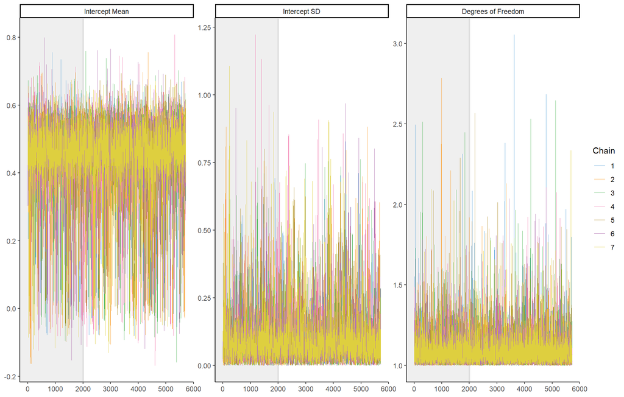

**NOTE**: Traceplot. Total chains = 7, total samples per chain = 7,715, warmup samples per chain = 2,000. Total posterior samples = 40,005. The gray-shaded area indicates the warmup samples. *Effective Sample Size* (ESS, Bürkner 2017) = 5,553, 4,949, and 17,731, respectively. Chain convergence ($\hat{R}$, Gelman and Rubin 1992; Vehtari et al. 2021) = 1.001, 1.000, and 1.000, respectively. *Monte Carlo Standard Error* (MCSE, Kruschke 2014) = .002, .001 and .001, respectively. Data for meta-analysis derived from Aarøe and Petersen (2014), Mummolo and Peterson (2019), and Kane et al. (2023).

Figure 10.2: Posterior Predictive Distribution of the Bayesian Meta-Analysis Model

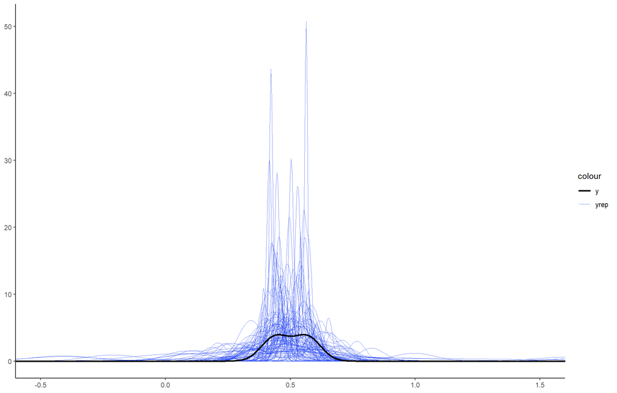

Table 10.3: 13-Number Summary of the Explanatory Power of the Bayesian Meta-Analysis Model

| Percentile | Estimate |
| --- | --- |
| 0% | 0.000 |
| 0.1% | 0.000 |
| 1% | 0.000 |
| 5% | 0.004 |
| 10% | 0.016 |
| 25% | 0.108 |
| 50% | 0.399 |
| 75% | 0.660 |
| 90% | 0.746 |
| 95% | 0.773 |
| 99% | 0.795 |
| 99.9% | 0.799 |
| 100% | 0.800 |

**NOTE**: Posterior distribution of the estimated explained variance ($R^2$, cf. Gelman et al. 2019). Posterior samples = 40,005. Mean = .390. IQR = .552. Skewness = -.045. Kurtosis = -1.510. Data for meta-analysis derived from Aarøe and Petersen (2014), Mummolo and Peterson (2019), and Kane et al. (2023).

Figure 10.3: Explanatory Power of the Bayesian Meta-Analysis Model

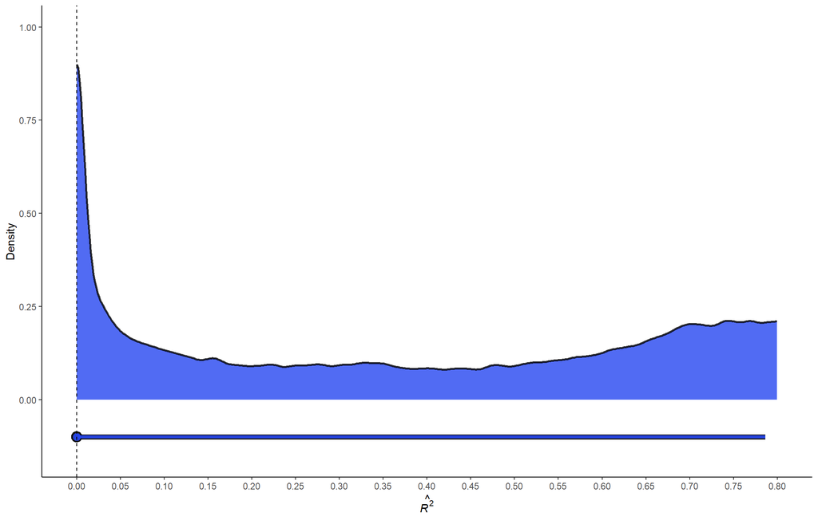

**NOTE**: Posterior distribution of the estimated explained variance ($R^2$, cf. Gelman et al. 2019). Posterior samples = 40,005. The dashed black line indicates an explanatory power of zero. The geometric below the distribution indicates the posterior mode (circle) and the 95% HDCI (thick bar). Data for meta-analysis derived from Aarøe and Petersen (2014), Mummolo and Peterson (2019), and Kane et al. (2023).

### 10.3.4 Model Parameters

Table 10.4: 13-Number Summary of the Meta-Analytical Effect of Deservingness on Welfare Support

| Percentile | Posterior | Likelihood |
| --- | --- | --- |
| 0% | -0.168 | -1.069 |
| 0.1% | -0.090 | 0.134 |
| 1% | -0.007 | 0.334 |
| 5% | 0.153 | 0.415 |
| 10% | 0.308 | 0.443 |
| 25% | 0.418 | 0.475 |
| 50% | 0.464 | 0.503 |
| 75% | 0.506 | 0.531 |
| 90% | 0.545 | 0.563 |
| 95% | 0.566 | 0.590 |
| 99% | 0.610 | 0.669 |
| 99.9% | 0.688 | 0.904 |
| 100% | 0.808 | 1.801 |

**NOTE**: Posterior and (maximum) likelihood distributions of the estimated intercept mean parameter ($\hat{\mu_\alpha}$), estimated with NUTS MCMC (Hoffman and Gelman 2014) and REML-based *Student t*-parametric bootstrap (Efron and Tibshirani 1994), respectively. Posterior/likelihood samples = 40,005. Mean = .439 and .503, respectively. IQR = .088 and .057, respectively. Skewness = -1.965 and .136, respectively. Kurtosis = 42.177 and 4.588, respectively. Data for meta-analysis derived from Aarøe and Petersen (2014), Mummolo and Peterson (2019), and Kane et al. (2023).

Figure 10.4: Meta-Analytical Effect of Deservingness on Welfare Support

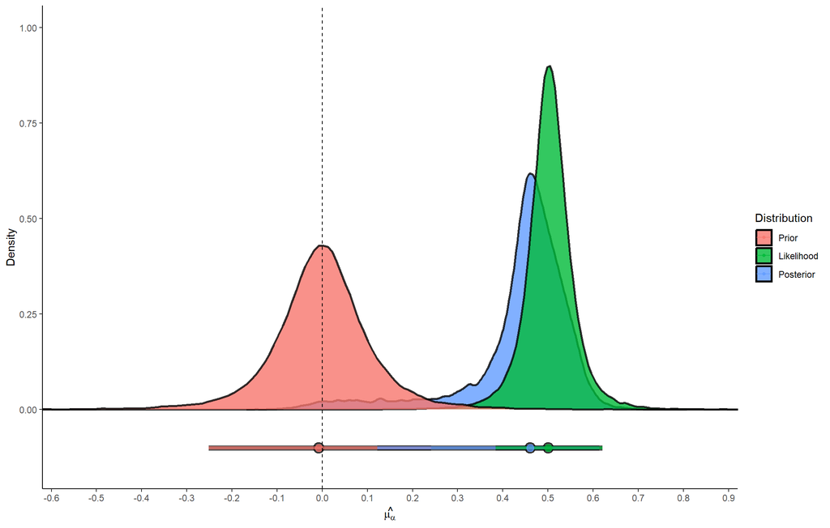

**NOTE**: Posterior, (maximum) likelihood, and prior distributions of the estimated intercept mean parameter ($\hat{\mu_\alpha}$). Posterior/likelihood/prior samples = 40,005; prior is not necessarily correctly visualized due to finite samples. The dashed black line indicates an effect of zero. The geometric below the distributions indicate the posterior mode (circle) and the 95% HDCI (thick bar). Data for meta-analysis derived from Aarøe and Petersen (2014), Mummolo and Peterson (2019), and Kane et al. (2023).

Table 10.5: 13-Number Summary of Meta-Analytical Variability in Effect of Deservingness on Welfare Support

| Percentile | Posterior | Likelihood |
| --- | --- | --- |
| 0% | 0.000 | 0.000 |
| 0.1% | 0.000 | 0.000 |
| 1% | 0.002 | 0.000 |
| 5% | 0.008 | 0.000 |
| 10% | 0.017 | 0.000 |
| 25% | 0.038 | 0.019 |
| 50% | 0.069 | 0.071 |
| 75% | 0.115 | 0.122 |
| 90% | 0.197 | 0.182 |
| 95% | 0.286 | 0.230 |
| 99% | 0.488 | 0.383 |
| 99.9% | 0.801 | 0.808 |
| 100% | 1.224 | 5.461 |

Figure 10.5: Meta-Analytical Variability in Effect of Deservingness on Welfare Support

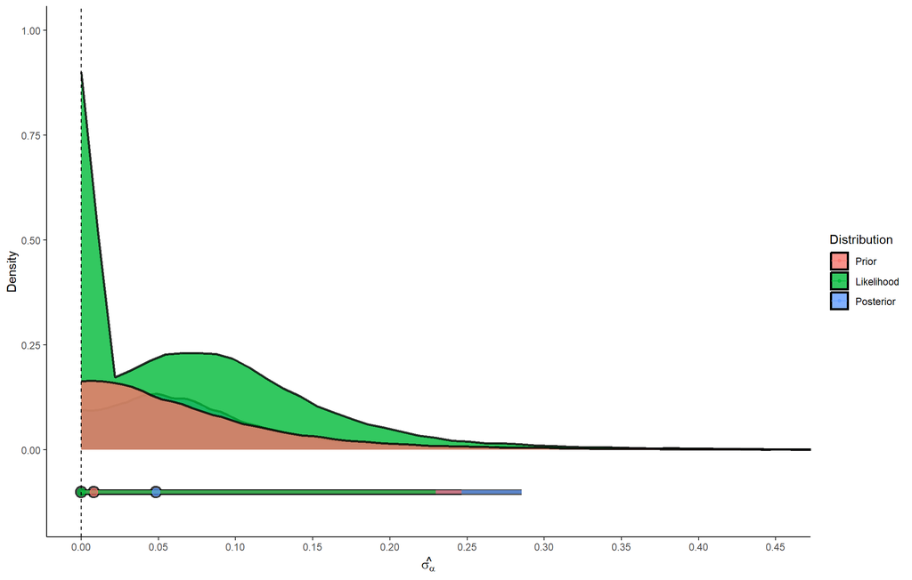

**NOTE**: Posterior, (maximum) likelihood, and prior distributions of the estimated intercept dispersion parameter ($\hat{\sigma_\alpha}$). Posterior/likelihood/prior samples = 40,005; prior is not necessarily correctly visualized due to finite samples. The dashed black line indicates an effect variability of zero across studies. The geometric below the distributions indicate the posterior mode (circle) and the 95% HDCI (thick bar). Data for meta-analysis derived from Aarøe and Petersen (2014), Mummolo and Peterson (2019), and Kane et al. (2023).

Table 10.6: 13-Number Summary of the Degrees of Freedom of the Bayesian Meta-Analysis Model

| Percentile | Posterior |
| --- | --- |
| 0% | 1.00 |
| 0.1% | 1.00 |
| 1% | 1.00 |
| 5% | 1.00 |
| 10% | 1.01 |
| 25% | 1.03 |
| 50% | 1.06 |
| 75% | 1.11 |
| 90% | 1.18 |
| 95% | 1.24 |
| 99% | 1.44 |
| 99.9% | 1.93 |
| 100% | 3.06 |

**NOTE**: Posterior distribution of the estimated model degrees of freedom parameter ($\hat{\nu}$). Posterior samples = 40,005. Mean = 1.084. IQR = .082. Skewness = 4.437. Kurtosis = 40.748. Data for meta-analysis derived from Aarøe and Petersen (2014), Mummolo and Peterson (2019), and Kane et al. (2023).

Figure 10.6: Degrees of Freedom of the Bayesian Meta-Analysis Model

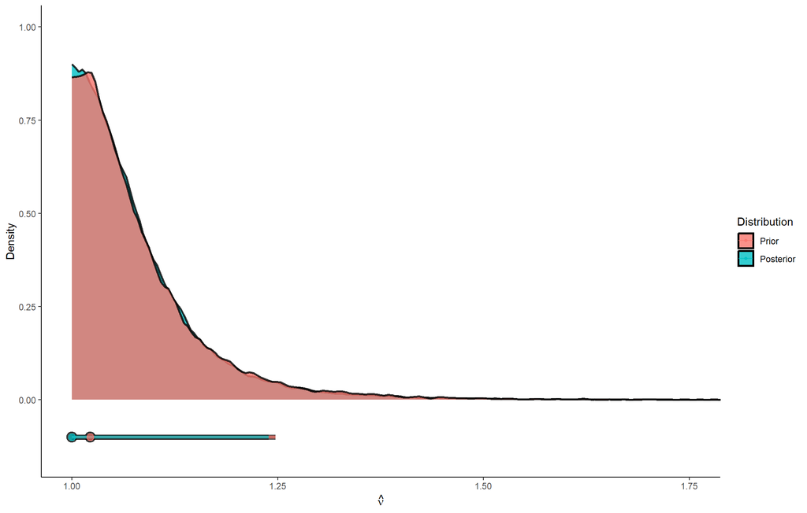

**NOTE**: Posterior and prior distributions of the estimated model degrees of freedom parameter ($\hat{\nu}$). Posterior/prior samples = 40,005; prior is not necessarily correctly visualized due to finite samples. The geometric below the distributions indicate the posterior mode (circle) and the 95% HDCI (thick bar). Data for meta-analysis derived from Aarøe and Petersen (2014), Mummolo and Peterson (2019), and Kane et al. (2023).

## 10.4 Simulated Data

### 10.4.1 US State Residence

This section gives an overview of the distribution of US State residencies in the simulated data, as well as census-based estimates of the US population for comparison. This is provided metrically in table 10.7 and graphically in figure 10.7. The mode of this discrete distribution of the sample is ‘California’ (10.80%). With a sample size of 1,009, the simulated sample manages to capture 98.82% of the information about the US State residencies in the population.

Table 10.7: Distribution of US States

| State | Sample Frequency | Sample Percentage (%) | Population Percentage (%) | Difference (pp) |
| --- | --- | --- | --- | --- |
| Alabama | 20 | 1.982 | 1.601 | 0.381 |
| Alaska | 1 | 0.099 | 0.192 | -0.092 |
| Arizona | 26 | 2.577 | 2.170 | 0.407 |
| Arkansas | 12 | 1.189 | 0.950 | 0.239 |
| California | 109 | 10.803 | 10.185 | 0.618 |
| Colorado | 16 | 1.586 | 1.812 | -0.226 |
| Connecticut | 14 | 1.388 | 1.115 | 0.273 |
| Delaware | 4 | 0.396 | 0.318 | 0.078 |
| District Of Columbia | 2 | 0.198 | 0.214 | -0.016 |
| Florida | 60 | 5.946 | 6.671 | -0.724 |
| Georgia | 36 | 3.568 | 3.292 | 0.276 |
| Hawaii | 1 | 0.099 | 0.455 | -0.355 |
| Idaho | 6 | 0.595 | 0.572 | 0.023 |
| Illinois | 44 | 4.361 | 3.852 | 0.509 |
| Indiana | 16 | 1.586 | 2.117 | -0.531 |
| Iowa | 9 | 0.892 | 1.013 | -0.121 |
| Kansas | 14 | 1.388 | 0.890 | 0.497 |
| Kentucky | 11 | 1.090 | 1.452 | -0.362 |
| Louisiana | 20 | 1.982 | 1.400 | 0.582 |
| Maine | 7 | 0.694 | 0.466 | 0.227 |
| Maryland | 16 | 1.586 | 1.896 | -0.311 |
| Massachusetts | 13 | 1.288 | 2.217 | -0.929 |
| Michigan | 25 | 2.478 | 3.190 | -0.712 |
| Minnesota | 16 | 1.586 | 1.780 | -0.194 |
| Mississippi | 7 | 0.694 | 0.916 | -0.223 |
| Missouri | 22 | 2.180 | 1.966 | 0.215 |
| Montana | 2 | 0.198 | 0.350 | -0.152 |
| Nebraska | 10 | 0.991 | 0.604 | 0.387 |
| Nevada | 9 | 0.892 | 0.922 | -0.030 |
| New Hampshire | 4 | 0.396 | 0.460 | -0.063 |
| New Jersey | 33 | 3.271 | 2.775 | 0.496 |
| New Mexico | 3 | 0.297 | 0.570 | -0.273 |
| New York | 58 | 5.748 | 5.959 | -0.211 |
| North Carolina | 26 | 2.577 | 3.301 | -0.724 |
| North Dakota | 0 | 0.000 | 0.245 | -0.245 |
| Ohio | 46 | 4.559 | 3.741 | 0.818 |
| Oklahoma | 18 | 1.784 | 1.138 | 0.646 |
| Oregon | 13 | 1.288 | 1.351 | -0.063 |
| Pennsylvania | 49 | 4.856 | 4.106 | 0.750 |
| Rhode Island | 0 | 0.000 | 0.320 | -0.320 |
| South Carolina | 25 | 2.478 | 1.698 | 0.780 |
| South Dakota | 7 | 0.694 | 0.276 | 0.418 |
| Tennessee | 17 | 1.685 | 2.267 | -0.582 |
| Texas | 77 | 7.631 | 8.222 | -0.590 |
| Utah | 12 | 1.189 | 0.975 | 0.214 |
| Vermont | 1 | 0.099 | 0.221 | -0.122 |
| Virginia | 19 | 1.883 | 2.691 | -0.808 |
| Washington | 26 | 2.577 | 2.431 | 0.146 |
| West Virginia | 3 | 0.297 | 0.585 | -0.287 |
| Wisconsin | 21 | 2.081 | 1.907 | 0.175 |
| Wyoming | 3 | 0.297 | 0.186 | 0.111 |
| <NA> | 0 | 0.000 | 0.000 | 0.000 |
| Total | 1,009 | 100.000 | 100.000 | 0.000 |

**NOTE**: Comparison of simulated versus ‘population’ data. The population percentage is an estimate based on census data. $n_{simulation}$ = 1,009; $n_{census}$ = 2,366,924. pp = Percentage points. NA = Missing data. Both the simulated and ‘population’ data is based on data by the IPUMS (Ruggles et al. 2024) and ANES (2021).

Figure 10.7: Distribution of US States

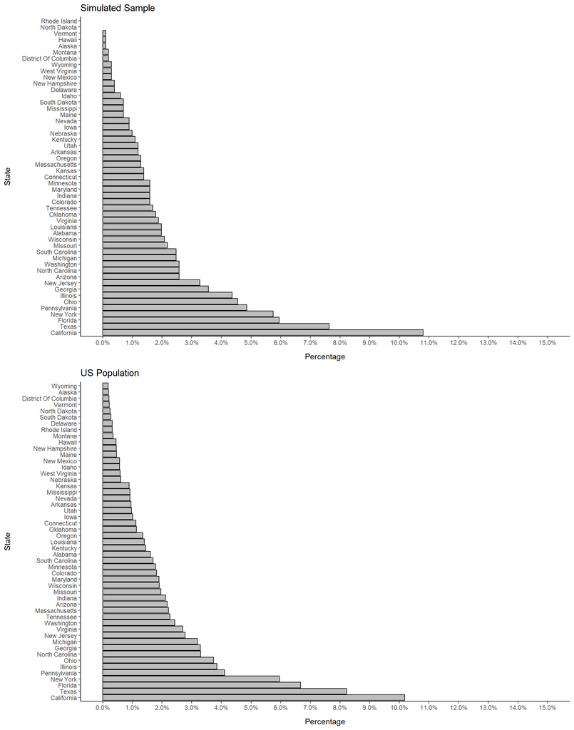

**NOTE**: Comparison of simulated versus ‘population’ data. The population percentage is an estimate based on census data. $n_{simulation}$ = 1,009; $n_{census}$ = 2,366,924. Both the simulated and ‘population’ data is based on data by the IPUMS (Ruggles et al. 2024) and ANES (2021).

### 10.4.2 Ethnoracial Group

This section gives an overview of the distribution of ‘ethnoracial groups’ (i.e., a racial/ethnic/national label employed in the US) in the simulated data, as well as census-based estimates of the US population for comparison. This is provided metrically in table 10.8 and graphically in figure 10.8. The mode of this discrete distribution of the sample is ‘White’ (75.12%). With a sample size of 1,009, the simulated sample manages to capture 99.98% of the information about the ‘ethnoracial groups’ in the population.

Table 10.8: Distribution of Race/Ethnicity/Nationality

| Race/Ethnicity/Nationality | Sample Frequency | Sample Percentage (%) | Population Percentage (%) | Difference (pp) |
| --- | --- | --- | --- | --- |
| Argentinean | 0 | 0.000 | 0.085 | -0.085 |
| Bangladeshi | 2 | 0.198 | 0.073 | 0.125 |
| Bhutanese | 0 | 0.000 | 0.004 | -0.004 |
| Black/African American | 81 | 8.028 | 8.831 | -0.803 |
| Bolivian | 0 | 0.000 | 0.025 | -0.025 |
| Burmese | 0 | 0.000 | 0.049 | -0.049 |
| Cambodian | 1 | 0.099 | 0.088 | 0.012 |
| Chilean | 0 | 0.000 | 0.046 | -0.046 |
| Chinese | 19 | 1.883 | 1.709 | 0.174 |
| Colombian | 8 | 0.793 | 0.282 | 0.511 |
| Costa Rican | 0 | 0.000 | 0.038 | -0.038 |
| Cuban | 5 | 0.496 | 0.643 | -0.148 |
| Dominican | 4 | 0.396 | 0.245 | 0.151 |
| Ecuadorian | 2 | 0.198 | 0.105 | 0.093 |
| Fijian | 0 | 0.000 | 0.011 | -0.011 |
| Filipino | 7 | 0.694 | 1.155 | -0.461 |
| Guatemalan | 0 | 0.000 | 0.186 | -0.186 |
| Hawaiian | 0 | 0.000 | 0.050 | -0.050 |
| Honduran | 2 | 0.198 | 0.125 | 0.073 |
| Indian | 18 | 1.784 | 1.405 | 0.379 |
| Indonesian | 1 | 0.099 | 0.030 | 0.069 |
| Japanese | 1 | 0.099 | 0.314 | -0.215 |
| Korean | 4 | 0.396 | 0.541 | -0.145 |
| Laotian | 0 | 0.000 | 0.057 | -0.057 |
| Malaysian | 0 | 0.000 | 0.009 | -0.009 |
| Mexican | 57 | 5.649 | 5.417 | 0.233 |
| Mongolian | 0 | 0.000 | 0.007 | -0.007 |
| Native American | 5 | 0.496 | 0.856 | -0.361 |
| Nepalese | 1 | 0.099 | 0.060 | 0.039 |
| Nicaraguan | 2 | 0.198 | 0.081 | 0.117 |
| Pakistani | 4 | 0.396 | 0.172 | 0.224 |
| Panamanian | 0 | 0.000 | 0.051 | -0.051 |
| Paraguayan | 1 | 0.099 | 0.006 | 0.093 |
| Peruvian | 2 | 0.198 | 0.129 | 0.069 |
| Puerto Rican | 8 | 0.793 | 0.941 | -0.148 |
| Salvadoran | 3 | 0.297 | 0.250 | 0.047 |
| Spaniard | 2 | 0.198 | 0.251 | -0.053 |
| Sri Lankan | 0 | 0.000 | 0.020 | -0.020 |
| Taiwanese | 0 | 0.000 | 0.100 | -0.100 |
| Thai | 1 | 0.099 | 0.078 | 0.021 |
| Uruguayan | 0 | 0.000 | 0.018 | -0.018 |
| Venezuelan | 3 | 0.297 | 0.144 | 0.153 |
| Vietnamese | 7 | 0.694 | 0.663 | 0.030 |
| White | 758 | 75.124 | 74.647 | 0.477 |
| <NA> | 0 | 0.000 | 0.000 | 0.000 |
| Total | 1,009 | 100.000 | 100.000 | 0.000 |

**NOTE**: Comparison of simulated versus ‘population’ data. The population percentage is an estimate based on census data. $n_{simulation}$ = 1,009; $n_{census}$ = 2,366,924. pp = Percentage points. NA = Missing data. Both the simulated and ‘population’ data is based on data by the IPUMS (Ruggles et al. 2024) and ANES (2021).

Figure 10.8: Distribution of Race/Ethnicity/Nationality

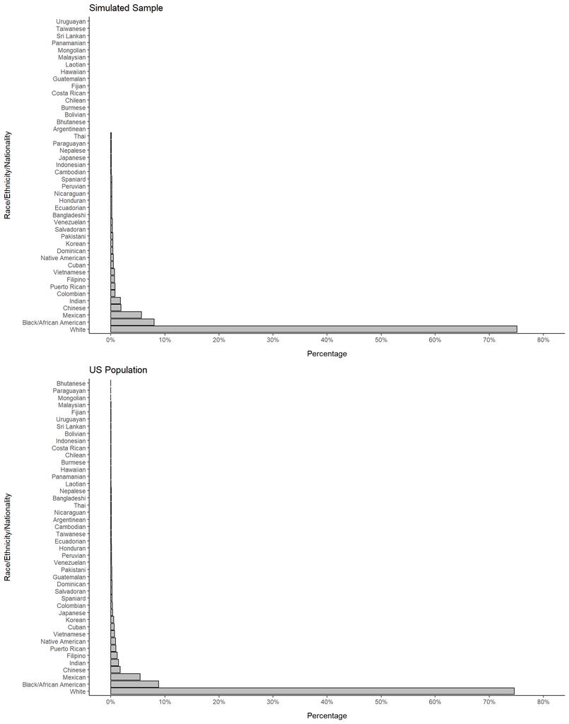

**NOTE**: Comparison of simulated versus ‘population’ data. The population percentage is an estimate based on census data. $n_{simulation}$ = 1,009; $n_{census}$ = 2,366,924. Both the simulated and ‘population’ data is based on data by the IPUMS (Ruggles et al. 2024) and ANES (2021).

### 10.4.3 Education

This section gives an overview of the distribution of levels of education in the simulated data, as well as census-based estimates of the US population for comparison. This is provided metrically in table 10.9 and graphically in figure 10.9. The mode of this discrete distribution of the sample is ‘Some Post-High School, No Bachelor’s Degree’ (30.62%). With a sample size of 1,009, the simulated sample manages to capture 99.80% of the information about the levels of education in the population.

Table 10.9: Distribution of Education

| Education | Sample Frequency | Sample Percentage (%) | Population Percentage (%) | Difference (pp) |
| --- | --- | --- | --- | --- |
| Bachelor’s Degree | 198 | 19.62 | 21.93 | -2.308 |
| Graduate Degree | 151 | 14.96 | 14.57 | 0.395 |
| High School Credential | 263 | 26.07 | 26.45 | -0.380 |
| Less Than High School Credential | 88 | 8.72 | 8.31 | 0.410 |
| Some Post-High School, No Bachelor’s Degree | 309 | 30.62 | 28.74 | 1.883 |
| <NA> | 0 | 0.00 | 0.00 | 0.000 |
| Total | 1,009 | 100.00 | 100.00 | 0.000 |

**NOTE**: Comparison of simulated versus ‘population’ data. The population percentage is an estimate based on census data. $n_{simulation}$ = 1,009; $n_{census}$ = 2,366,924. pp = Percentage points. NA = Missing data. Both the simulated and ‘population’ data is based on data by the IPUMS (Ruggles et al. 2024) and ANES (2021).

Figure 10.9: Distribution of Education

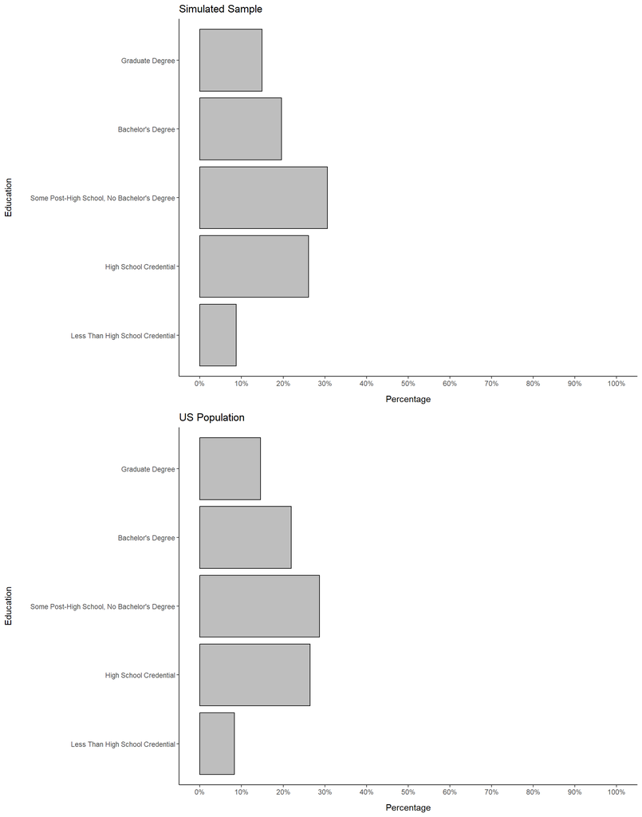

**NOTE**: Comparison of simulated versus ‘population’ data. The population percentage is an estimate based on census data. $n_{simulation}$ = 1,009; $n_{census}$ = 2,366,924. Both the simulated and ‘population’ data is based on data by the IPUMS (Ruggles et al. 2024) and ANES (2021).

### 10.4.4 Age

This section gives an overview of the distribution of age in the simulated data, as well as census-based estimates of the US population for comparison. This is provided metrically in table 10.10 and graphically in figure 10.10. While arguably continuous, the mode of this discretized distribution of the sample is ‘53’ (2.48%), complemented by the mean, standard deviation (SD), median, and interquartile range (IQR) of the sample and population being listed under the table and figure. With a sample size of 1,009, the simulated sample manages to capture 97.00% of the information about age in the population.

Table 10.10: Distribution of Age

| Age | Sample Frequency | Sample Percentage (%) | Population Percentage (%) | Difference (pp) |
| --- | --- | --- | --- | --- |
| 18 | 15 | 1.487 | 1.206 | 0.281 |
| 19 | 4 | 0.396 | 1.049 | -0.653 |
| 20 | 12 | 1.189 | 1.074 | 0.116 |
| 21 | 12 | 1.189 | 1.142 | 0.047 |
| 22 | 10 | 0.991 | 1.208 | -0.217 |
| 23 | 10 | 0.991 | 1.237 | -0.246 |
| 24 | 16 | 1.586 | 1.253 | 0.333 |
| 25 | 20 | 1.982 | 1.290 | 0.693 |
| 26 | 14 | 1.388 | 1.311 | 0.077 |
| 27 | 13 | 1.288 | 1.349 | -0.060 |
| 28 | 16 | 1.586 | 1.383 | 0.203 |
| 29 | 13 | 1.288 | 1.413 | -0.124 |
| 30 | 17 | 1.685 | 1.511 | 0.174 |
| 31 | 12 | 1.189 | 1.504 | -0.315 |
| 32 | 15 | 1.487 | 1.550 | -0.064 |
| 33 | 12 | 1.189 | 1.520 | -0.330 |
| 34 | 7 | 0.694 | 1.496 | -0.802 |
| 35 | 12 | 1.189 | 1.513 | -0.324 |
| 36 | 20 | 1.982 | 1.519 | 0.463 |
| 37 | 18 | 1.784 | 1.520 | 0.264 |
| 38 | 19 | 1.883 | 1.507 | 0.376 |
| 39 | 9 | 0.892 | 1.500 | -0.608 |
| 40 | 15 | 1.487 | 1.558 | -0.072 |
| 41 | 18 | 1.784 | 1.509 | 0.275 |
| 42 | 13 | 1.288 | 1.515 | -0.226 |
| 43 | 19 | 1.883 | 1.444 | 0.439 |
| 44 | 13 | 1.288 | 1.429 | -0.140 |
| 45 | 20 | 1.982 | 1.432 | 0.550 |
| 46 | 19 | 1.883 | 1.385 | 0.498 |
| 47 | 9 | 0.892 | 1.410 | -0.518 |
| 48 | 13 | 1.288 | 1.413 | -0.124 |
| 49 | 19 | 1.883 | 1.427 | 0.456 |
| 50 | 15 | 1.487 | 1.565 | -0.079 |
| 51 | 15 | 1.487 | 1.642 | -0.155 |
| 52 | 19 | 1.883 | 1.638 | 0.245 |
| 53 | 25 | 2.478 | 1.597 | 0.881 |
| 54 | 18 | 1.784 | 1.570 | 0.214 |
| 55 | 15 | 1.487 | 1.613 | -0.126 |
| 56 | 14 | 1.388 | 1.649 | -0.262 |
| 57 | 18 | 1.784 | 1.764 | 0.020 |
| 58 | 18 | 1.784 | 1.825 | -0.041 |
| 59 | 11 | 1.090 | 1.851 | -0.761 |
| 60 | 20 | 1.982 | 1.910 | 0.072 |
| 61 | 23 | 2.279 | 1.924 | 0.356 |
| 62 | 21 | 2.081 | 1.973 | 0.108 |
| 63 | 20 | 1.982 | 1.938 | 0.044 |
| 64 | 25 | 2.478 | 1.967 | 0.511 |
| 65 | 18 | 1.784 | 1.974 | -0.190 |
| 66 | 17 | 1.685 | 1.904 | -0.219 |
| 67 | 18 | 1.784 | 1.862 | -0.078 |
| 68 | 19 | 1.883 | 1.831 | 0.052 |
| 69 | 18 | 1.784 | 1.770 | 0.014 |
| 70 | 9 | 0.892 | 1.709 | -0.817 |
| 71 | 15 | 1.487 | 1.618 | -0.131 |
| 72 | 21 | 2.081 | 1.562 | 0.519 |
| 73 | 13 | 1.288 | 1.516 | -0.228 |
| 74 | 15 | 1.487 | 1.487 | -0.001 |
| 75 | 14 | 1.388 | 1.499 | -0.112 |
| 76 | 9 | 0.892 | 1.125 | -0.233 |
| 77 | 15 | 1.487 | 1.029 | 0.458 |
| 78 | 11 | 1.090 | 0.999 | 0.092 |
| 79 | 2 | 0.198 | 0.976 | -0.778 |
| 80 | 6 | 0.595 | 0.838 | -0.244 |
| 81 | 14 | 1.388 | 0.736 | 0.652 |
| 82 | 7 | 0.694 | 0.656 | 0.038 |
| 83 | 4 | 0.396 | 0.600 | -0.203 |
| 84 | 3 | 0.297 | 0.531 | -0.233 |
| 85 | 6 | 0.595 | 0.462 | 0.133 |
| 86 | 2 | 0.198 | 0.408 | -0.210 |
| 87 | 1 | 0.099 | 0.361 | -0.262 |
| 88 | 1 | 0.099 | 0.294 | -0.195 |
| 89 | 3 | 0.297 | 0.231 | 0.067 |
| 90 | 1 | 0.099 | 0.162 | -0.063 |
| 91 | 1 | 0.099 | 0.071 | 0.029 |
| 92 | 3 | 0.297 | 0.151 | 0.147 |
| 93 | 4 | 0.396 | 0.145 | 0.251 |
| 94 | 3 | 0.297 | 0.278 | 0.019 |
| 95 | 5 | 0.496 | 0.206 | 0.289 |
| <NA> | 0 | 0.000 | 0.000 | 0.000 |
| Total | 1,009 | 100.000 | 100.000 | 0.000 |

**NOTE**: Comparison of simulated versus ‘population’ data. Mean age = 51.724 (SD = 18.535) and 51.845 (SD = 18.594), respectively. Median age = 53.000 (IQR = 29.000) and 53.000 (IQR = 31.000), respectively. The population percentage is an estimate based on census data. $n_{simulation}$ = 1,009; $n_{census}$ = 2,366,924. pp = Percentage points. NA = Missing data. Both the simulated and ‘population’ data is based on data by the IPUMS (Ruggles et al. 2024) and ANES (2021).

Figure 10.10: Distribution of Age

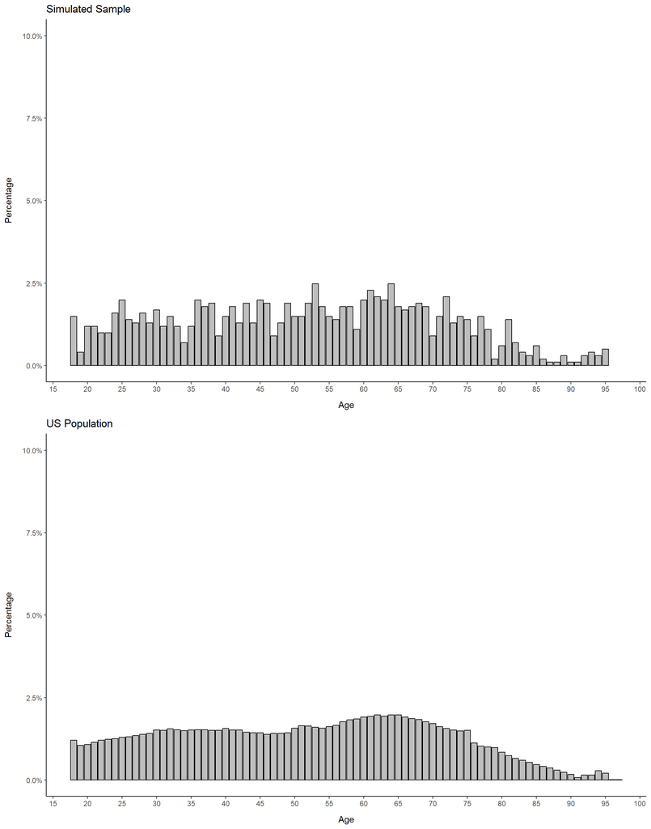

**NOTE**: Comparison of simulated versus ‘population’ data. Mean age = 51.724 (SD = 18.535) and 51.845 (SD = 18.594), respectively. Median age = 53.000 (IQR = 29.000) and 53.000 (IQR = 31.000), respectively. The population percentage is an estimate based on census data. $n_{simulation}$ = 1,009; $n_{census}$ = 2,366,924. Both the simulated and ‘population’ data is based on data by the IPUMS (Ruggles et al. 2024) and ANES (2021).

### 10.4.5 Household Income

This section gives an overview of the distribution of annual household gross incomes (in 2022 $US) in the simulated data, as well as census-based estimates of the US population for comparison. This is provided metrically in table 10.11 and graphically in figure 10.11. While arguably continuous, the mode of this discretized distribution of the sample is ‘100,000’ (1.09%), complemented by the mean, standard deviation (SD), median, and interquartile range (IQR) of the sample and population being listed under the table and figure. With a sample size of 1,009, the simulated sample manages to capture 77.01% of the information about household incomes in the population.

Table 10.11: Distribution of Household Incomes

| Household Income ($US) | Sample Frequency | Sample Percentage (%) | Population Percentage (%) | Difference (pp) |
| --- | --- | --- | --- | --- |
| -1996 | 1 | 0.099 | 0.000 | 0.099 |
| -6910 | 1 | 0.099 | 0.000 | 0.099 |
| 0 | 10 | 0.991 | 1.030 | -0.039 |
| 100 | 1 | 0.099 | 0.012 | 0.087 |
| 10000 | 2 | 0.198 | 0.243 | -0.045 |
| 100000 | 11 | 1.090 | 0.718 | 0.373 |
| 100200 | 1 | 0.099 | 0.029 | 0.070 |
| 100900 | 1 | 0.099 | 0.016 | 0.083 |
| 10100 | 1 | 0.099 | 0.102 | -0.003 |
| 101000 | 2 | 0.198 | 0.156 | 0.042 |
| 101300 | 1 | 0.099 | 0.020 | 0.079 |
| 101500 | 1 | 0.099 | 0.030 | 0.069 |
| 101600 | 1 | 0.099 | 0.029 | 0.070 |
| 102000 | 2 | 0.198 | 0.209 | -0.011 |
| 102800 | 1 | 0.099 | 0.024 | 0.075 |
| 103000 | 1 | 0.099 | 0.182 | -0.083 |
| 103640 | 1 | 0.099 | 0.001 | 0.098 |
| 103800 | 2 | 0.198 | 0.023 | 0.175 |
| 104000 | 2 | 0.198 | 0.177 | 0.021 |
| 105000 | 7 | 0.694 | 0.340 | 0.354 |
| 106000 | 2 | 0.198 | 0.163 | 0.035 |
| 106800 | 1 | 0.099 | 0.023 | 0.076 |
| 107000 | 2 | 0.198 | 0.164 | 0.034 |
| 107200 | 1 | 0.099 | 0.024 | 0.075 |
| 107500 | 1 | 0.099 | 0.029 | 0.070 |
| 10800 | 1 | 0.099 | 0.062 | 0.037 |
| 108000 | 1 | 0.099 | 0.194 | -0.095 |
| 108600 | 1 | 0.099 | 0.021 | 0.078 |
| 108700 | 2 | 0.198 | 0.017 | 0.181 |
| 109600 | 1 | 0.099 | 0.027 | 0.072 |

[output cut: 653 more lines]

**NOTE**: Comparison of simulated versus ‘population’ data. Mean income = 114,228 (SD = 117,339) and 116,894 (SD = 123,866), respectively. Median income = 82,000 (IQR = 99,000) and 85,000 (IQR = 100,600), respectively. The population percentage is an estimate based on census data. $n_{simulation}$ = 1,009; $n_{census}$ = 2,366,924. pp = Percentage points. NA = Missing data. Both the simulated and ‘population’ data is based on data by the IPUMS (Ruggles et al. 2024) and ANES (2021).

Figure 10.11: Distribution of Household Incomes

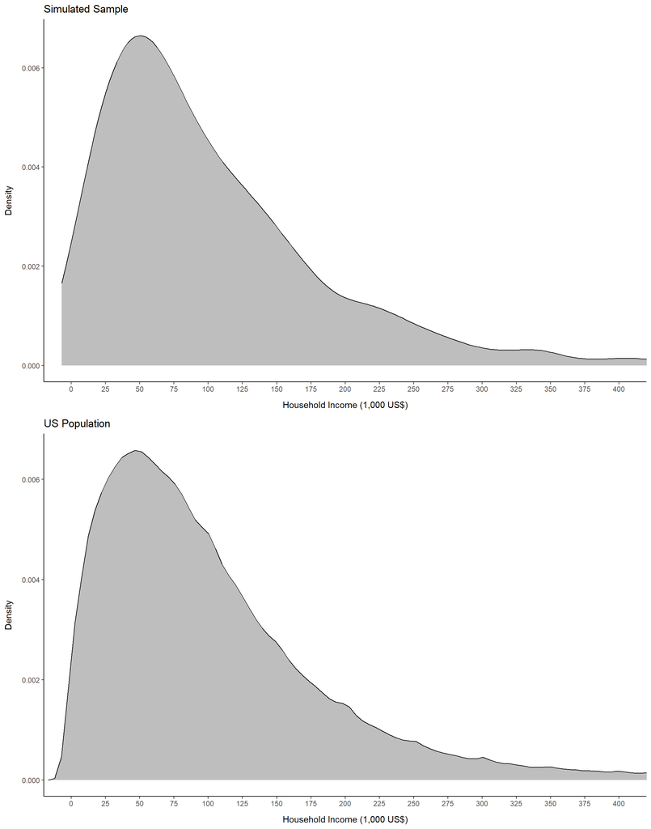

**NOTE**: Comparison of simulated versus ‘population’ data. Mean income = 114,228 (SD = 117,339) and 116,894 (SD = 123,866), respectively. Median income = 82,000 (IQR = 99,000) and 85,000 (IQR = 100,600), respectively. The population percentage is an estimate based on census data. $n_{simulation}$ = 1,009; $n_{census}$ = 2,366,924. Both the simulated and ‘population’ data is based on data by the IPUMS (Ruggles et al. 2024) and ANES (2021).

### 10.4.6 Number of Children

This section gives an overview of the distribution of children in the simulated data, as well as census-based estimates of the US population for comparison. This is provided metrically in table 10.12 and graphically in figure 10.12. The mode of this discrete distribution of the sample is ‘0’ (64.62%). With a sample size of 1,009, the simulated sample manages to capture 99.99% of the information about children in the population.

Table 10.12: Distribution of Children

| Number of Children | Sample Frequency | Sample Percentage (%) | Population Percentage (%) | Difference (pp) |
| --- | --- | --- | --- | --- |
| 0 | 652 | 64.62 | 65.39 | -0.768 |
| 1 | 177 | 17.54 | 17.07 | 0.475 |
| 2 | 121 | 11.99 | 11.52 | 0.472 |
| 3 | 44 | 4.36 | 4.23 | 0.133 |
| 4 Or More | 15 | 1.49 | 1.80 | -0.311 |
| <NA> | 0 | 0.00 | 0.00 | 0.000 |
| Total | 1,009 | 100.00 | 100.00 | 0.000 |

**NOTE**: Comparison of simulated versus ‘population’ data. The population percentage is an estimate based on census data. $n_{simulation}$ = 1,009; $n_{census}$ = 2,366,924. pp = Percentage points. NA = Missing data. Both the simulated and ‘population’ data is based on data by the IPUMS (Ruggles et al. 2024) and ANES (2021).

Figure 10.12: Distribution of Children

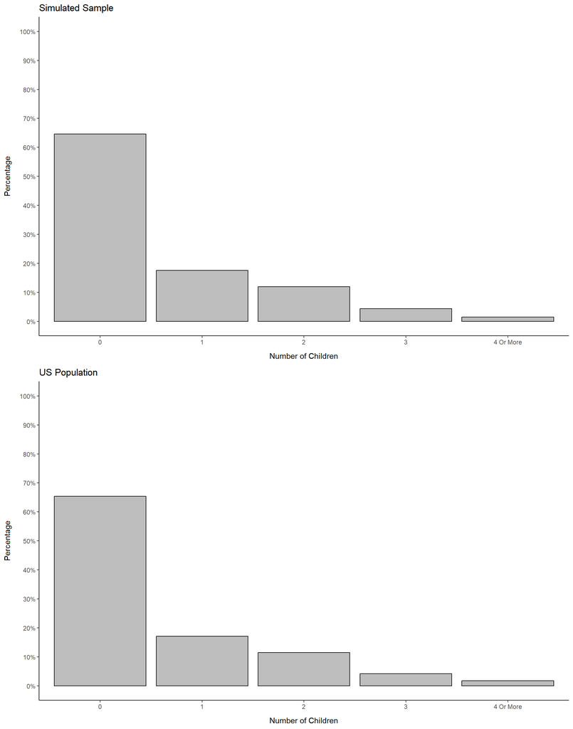

**NOTE**: Comparison of simulated versus ‘population’ data. The population percentage is an estimate based on census data. $n_{simulation}$ = 1,009; $n_{census}$ = 2,366,924. Both the simulated and ‘population’ data is based on data by the IPUMS (Ruggles et al. 2024) and ANES (2021).

### 10.4.7 Area of Residence

This section gives an overview of the distribution of area residencies in the simulated data, as well as census-based estimates of the US population for comparison. This is provided metrically in table 10.13 and graphically in figure 10.13. The mode of this discrete distribution of the sample is ‘Small Town Or Surburb’ (78.20%). With a sample size of 1,009, the simulated sample manages to capture 100.00% of the information about area residencies in the population.

Table 10.13: Distribution of Area Residencies

| Area Residence | Sample Frequency | Sample Percentage (%) | Population Percentage (%) | Difference (pp) |
| --- | --- | --- | --- | --- |
| City | 105 | 10.4 | 10.9 | -0.465 |
| Rural Area | 115 | 11.4 | 10.9 | 0.453 |
| Small Town Or Surburb | 789 | 78.2 | 78.2 | 0.012 |
| <NA> | 0 | 0.0 | 0.0 | 0.000 |
| Total | 1,009 | 100.0 | 100.0 | 0.000 |

**NOTE**: Comparison of simulated versus ‘population’ data. The population percentage is an estimate based on census data. $n_{simulation}$ = 1,009; $n_{census}$ = 2,366,924. pp = Percentage points. NA = Missing data. Both the simulated and ‘population’ data is based on data by the IPUMS (Ruggles et al. 2024) and ANES (2021).

Figure 10.13: Distribution of Area Residencies

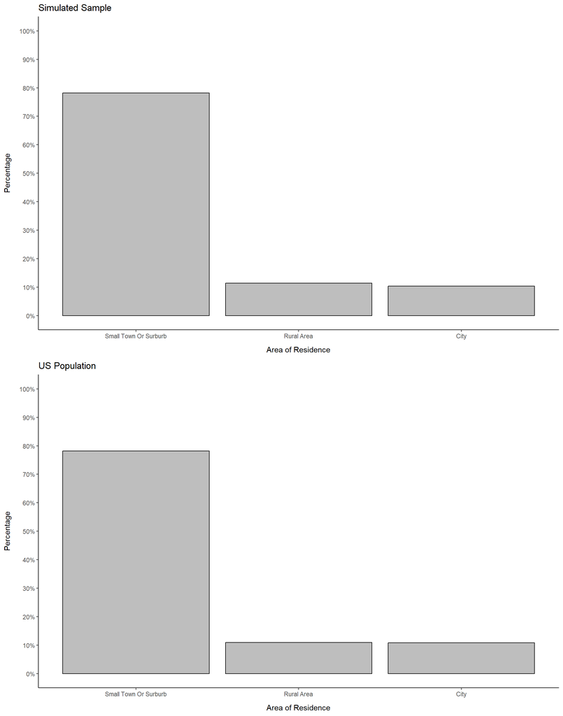

**NOTE**: Comparison of simulated versus ‘population’ data. The population percentage is an estimate based on census data. $n_{simulation}$ = 1,009; $n_{census}$ = 2,366,924. Both the simulated and ‘population’ data are based on data by the IPUMS (Ruggles et al. 2024) and ANES (2021).

### 10.4.8 Sex

This section gives an overview of the distribution of sex in the simulated data, as well as census-based estimates of the US population for comparison. This is provided metrically in table 10.14 and graphically in figure 10.14. The mode of this discrete distribution of the sample is ‘Female’ (52.82%). With a sample size of 1,009, the simulated sample manages to capture 99.99% of the information about sex in the population.

Table 10.14: Distribution of Sexes

| Sex | Sample Frequency | Sample Percentage (%) | Population Percentage (%) | Difference (pp) |
| --- | --- | --- | --- | --- |
| Female | 533 | 52.8 | 52.2 | 0.585 |
| Male | 476 | 47.2 | 47.8 | -0.585 |
| <NA> | 0 | 0.0 | 0.0 | 0.000 |
| Total | 1,009 | 100.0 | 100.0 | 0.000 |

**NOTE**: Comparison of simulated versus ‘population’ data. The population percentage is an estimate based on census data. $n_{simulation}$ = 1,009; $n_{census}$ = 2,366,924. pp = Percentage points. NA = Missing data. Both the simulated and ‘population’ data is based on data by the IPUMS (Ruggles et al. 2024) and ANES (2021).

Figure 10.14: Distribution of Sexes

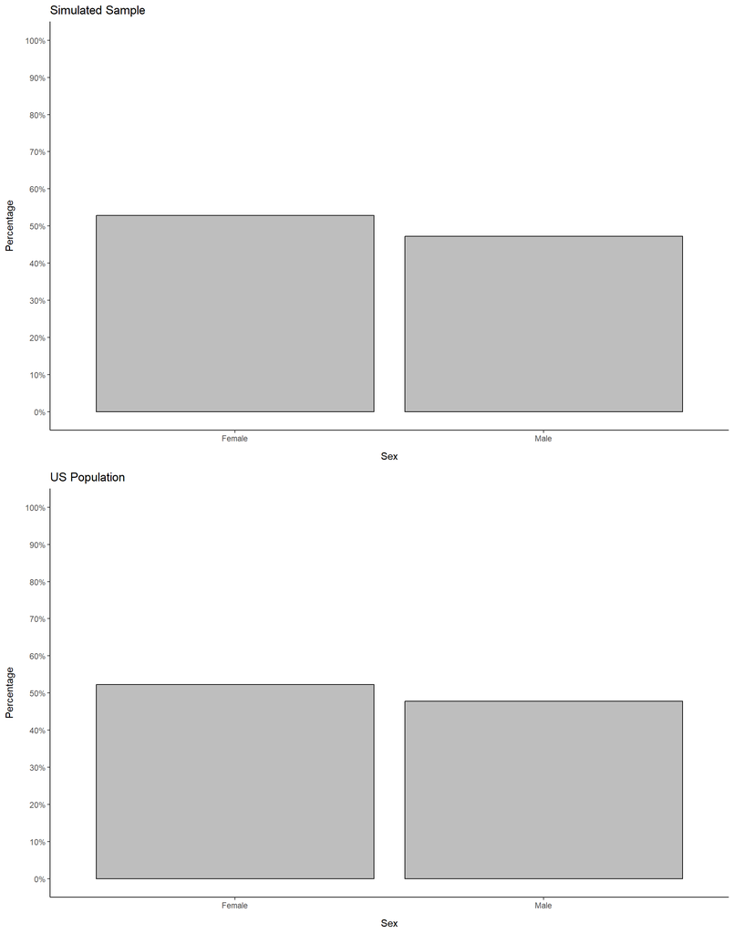

**NOTE**: Comparison of simulated versus ‘population’ data. The population percentage is an estimate based on census data. $n_{simulation}$ = 1,009; $n_{census}$ = 2,366,924. Both the simulated and ‘population’ data are based on data by the IPUMS (Ruggles et al. 2024) and ANES (2021).

### 10.4.9 Marital Status

This section gives an overview of the distribution of marital status in the simulated data, as well as census-based estimates of the US population for comparison. This is provided metrically in table 10.15 and graphically in figure 10.15. The mode of this discrete distribution of the sample is ‘Married’ (56.69%). With a sample size of 1,009, the simulated sample manages to capture 99.92% of the information about marital status in the population.

Table 10.15: Distribution of Marital Status

| Marital Status | Sample Frequency | Sample Percentage (%) | Population Percentage (%) | Difference (pp) |
| --- | --- | --- | --- | --- |
| Divorced | 118 | 11.695 | 11.35 | 0.341 |
| Married | 572 | 56.690 | 56.67 | 0.017 |
| Not Married | 223 | 22.101 | 23.80 | -1.702 |
| Separated | 10 | 0.991 | 1.42 | -0.433 |
| Widowed | 86 | 8.523 | 6.75 | 1.776 |
| <NA> | 0 | 0.000 | 0.00 | 0.000 |
| Total | 1,009 | 100.000 | 100.00 | 0.000 |

**NOTE**: Comparison of simulated versus ‘population’ data. The population percentage is an estimate based on census data. $n_{simulation}$ = 1,009; $n_{census}$ = 2,366,924. pp = Percentage points. NA = Missing data. Both the simulated and ‘population’ data is based on data by the IPUMS (Ruggles et al. 2024) and ANES (2021).

Figure 10.15: Distribution of Marital Status

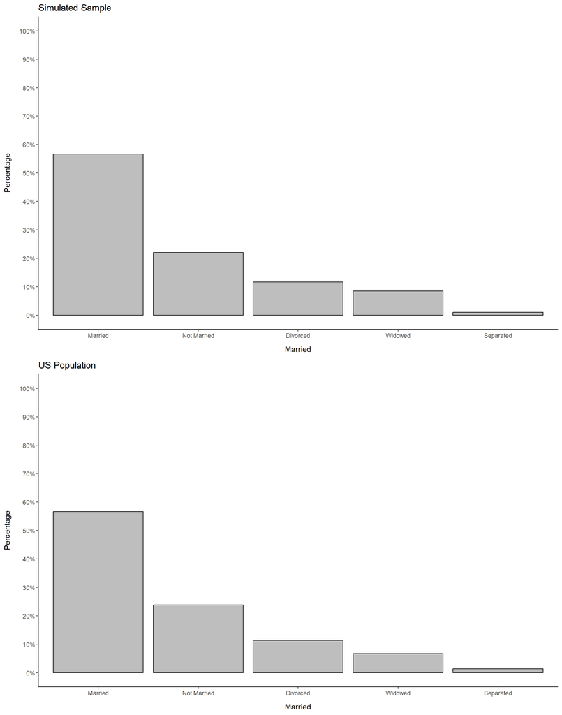

**NOTE**: Comparison of simulated versus ‘population’ data. The population percentage is an estimate based on census data. $n_{simulation}$ = 1,009; $n_{census}$ = 2,366,924. Both the simulated and ‘population’ data are based on data by the IPUMS (Ruggles et al. 2024) and ANES (2021).

### 10.4.10 Employment Status

This section gives an overview of the distribution of employment status in the simulated data, as well as census-based estimates of the US population for comparison. This is provided metrically in table 10.16 and graphically in figure 10.16. The mode of this discrete distribution of the sample is ‘Employed’ (60.36%). With a sample size of 1,009, the simulated sample manages to capture 99.96% of the information about employment status in the population.

Table 10.16: Distribution of Employment Status

| Employment Status | Sample Frequency | Sample Percentage (%) | Population Percentage (%) | Difference (pp) |
| --- | --- | --- | --- | --- |
| Employed | 609 | 60.36 | 59.05 | 1.303 |
| Not In Labor Force | 376 | 37.27 | 38.67 | -1.408 |
| Unemployed | 24 | 2.38 | 2.27 | 0.105 |
| <NA> | 0 | 0.00 | 0.00 | 0.000 |
| Total | 1,009 | 100.00 | 100.00 | 0.000 |

**NOTE**: Comparison of simulated versus ‘population’ data. The population percentage is an estimate based on census data. $n_{simulation}$ = 1,009; $n_{census}$ = 2,366,924. pp = Percentage points. NA = Missing data. Both the simulated and ‘population’ data is based on data by the IPUMS (Ruggles et al. 2024) and ANES (2021).

Figure 10.16: Distribution of Employment Status

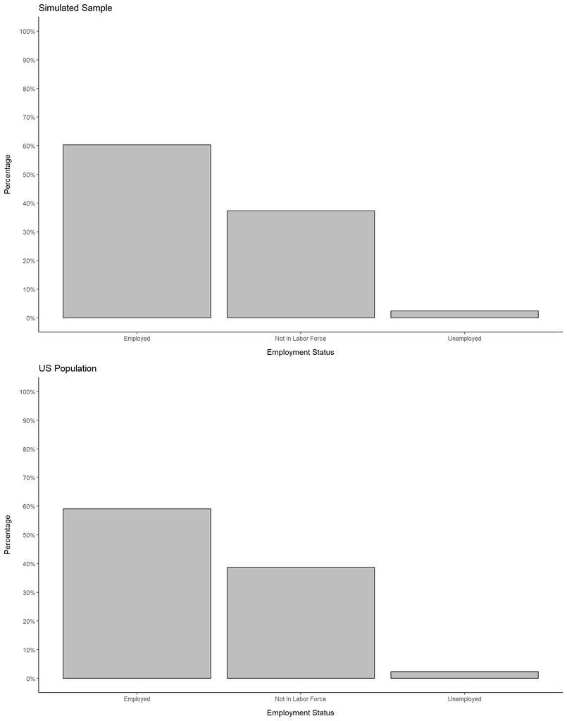

**NOTE**: Comparison of simulated versus ‘population’ data. The population percentage is an estimate based on census data. $n_{simulation}$ = 1,009; $n_{census}$ = 2,366,924. Both the simulated and ‘population’ data is based on data by the IPUMS (Ruggles et al. 2024) and ANES (2021).

### 10.4.11 Political Party

This section gives an overview of the distribution of political parties in the simulated data, as well as census-based estimates of the US population for comparison. This is provided metrically in table 10.17 and graphically in figure 10.17. The mode of this discrete distribution of the sample is ‘Democratic Party’ (53.72%). With a sample size of 1,009, the simulated sample manages to capture 99.95% of the information about political parties in the population.

Table 10.17: Distribution of Preferred Political Parties

| Political Party | Sample Frequency | Sample Percentage (%) | Population Percentage (%) | Difference (pp) |
| --- | --- | --- | --- | --- |
| Democratic Party | 542 | 53.7 | 55.3 | -1.58 |
| Republican Party | 467 | 46.3 | 44.7 | 1.58 |
| <NA> | 0 | 0.0 | 0.0 | 0.00 |
| Total | 1,009 | 100.0 | 100.0 | 0.00 |

**NOTE**: Comparison of simulated versus ‘population’ data. The population percentage is an estimate based on census data. $n_{simulation}$ = 1,009; $n_{census}$ = 2,366,924. pp = Percentage points. NA = Missing data. Both the simulated and ‘population’ data is based on data by the IPUMS (Ruggles et al. 2024) and ANES (2021).

Figure 10.17: Distribution of Preferred Political Parties

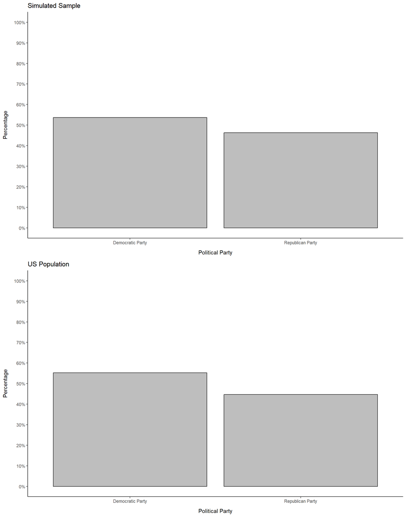

**NOTE**: Comparison of simulated versus ‘population’ data. The population percentage is an estimate based on census data. $n_{simulation}$ = 1,009; $n_{census}$ = 2,366,924. Both the simulated and ‘population’ data are based on data by the IPUMS (Ruggles et al. 2024) and ANES (2021).

### 10.4.12 Political Ideology

This section gives an overview of the distribution of political ideologies in the simulated data, as well as census-based estimates of the US population for comparison. This is provided metrically in table 10.18 and graphically in figure 10.18. The mode of this discrete distribution of the sample is ‘Conservative’ (43.01%). With a sample size of 1,009, the simulated sample manages to capture 99.83% of the information about political ideologies in the population.

Table 10.18: Distribution of Political Ideologies

| Political Ideology | Sample Frequency | Sample Percentage (%) | Population Percentage (%) | Difference (pp) |
| --- | --- | --- | --- | --- |
| Extremely Liberal | 6 | 0.595 | 0.503 | 0.092 |
| Liberal | 192 | 19.029 | 19.982 | -0.953 |
| Slightly Liberal | 70 | 6.938 | 6.233 | 0.705 |
| Moderate; Middle Of The Road | 282 | 27.948 | 29.519 | -1.571 |
| Slightly Conservative | 17 | 1.685 | 2.313 | -0.628 |
| Conservative | 434 | 43.013 | 40.395 | 2.618 |
| Extremely Conservative | 8 | 0.793 | 1.056 | -0.263 |
| <NA> | 0 | 0.000 | 0.000 | 0.000 |
| Total | 1,009 | 100.000 | 100.000 | 0.000 |

**NOTE**: Comparison of simulated versus ‘population’ data. The population percentage is an estimate based on census data. $n_{simulation}$ = 1,009; $n_{census}$ = 2,366,924. pp = Percentage points. NA = Missing data. Both the simulated and ‘population’ data is based on data by the IPUMS (Ruggles et al. 2024) and ANES (2021).

Figure 10.18: Distribution of Political Ideologies

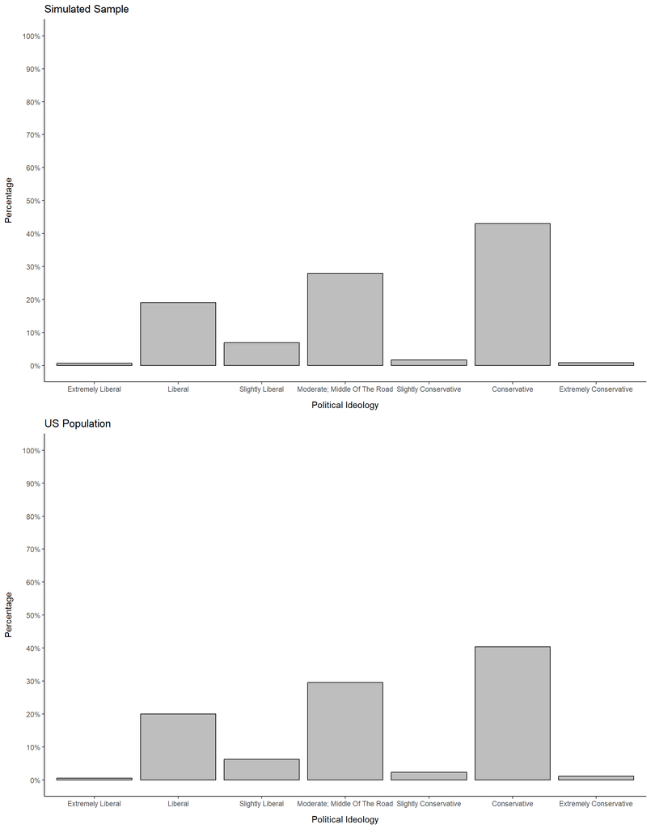

**NOTE**: Comparison of simulated versus ‘population’ data. The population percentage is an estimate based on census data. $n_{simulation}$ = 1,009; $n_{census}$ = 2,366,924. Both the simulated and ‘population’ data are based on data by the IPUMS (Ruggles et al. 2024) and ANES (2021).

## 10.5 Synthetic Data

### 10.5.1 Welfare Support

This section gives an overview of the distribution of welfare support as measured among the synthetic respondents across the the ‘lazy’ and ‘unlucky’ welfare recipient manipulation conditions. The distributions of welfare support in the synthetic data across the two conditions is provided metrically in table 10.19 and graphically in figure 10.19, respectively. The modes of these discrete distributions are ‘6 Agree’ (35.58%) and ‘1 Strongly disagree’ (86.22%), respectively.

Table 10.19: Distribution of Support for Restricting Welfare Eligibility

| Support for Restricting Welfare Eligibility | Lazy Frequency | Lazy Percentage (%) | Unlucky Frequency | Unlucky Percentage (%) | Difference (pp) |
| --- | --- | --- | --- | --- | --- |
| 1 Strongly disagree | 10 | 0.991 | 870 | 86.22 | -85.23 |
| 2 Disagree | 108 | 10.704 | 80 | 7.93 | 2.77 |
| 3 Somewhat disagree | 335 | 33.201 | 0 | 0.00 | 33.20 |
| 4 Neither agree or disagree | 40 | 3.964 | 59 | 5.85 | -1.88 |
| 5 Somewhat agree | 157 | 15.560 | 0 | 0.00 | 15.56 |
| 6 Agree | 359 | 35.580 | 0 | 0.00 | 35.58 |
| 7 Strongly agree | 0 | 0.000 | 0 | 0.00 | 0.00 |
| <NA> | 0 | 0.000 | 0 | 0.00 | 0.00 |
| Total | 1,009 | 100.000 | 1,009 | 100.00 | 0.00 |

**NOTE**: Comparison of support for restricting welfare eligibility across group conditions. $n$ = 1,009. Results derived from synthetic data generated by OpenAI’s (2024a) gpt-4o-mini using vignettes and questions created by Aarøe and Petersen (2014) and Petersen et al. (2012), as well as data by the IPUMS (Ruggles et al. 2024) and ANES (2021).

Figure 10.19: Distribution of Support for Restricting Welfare Eligibility

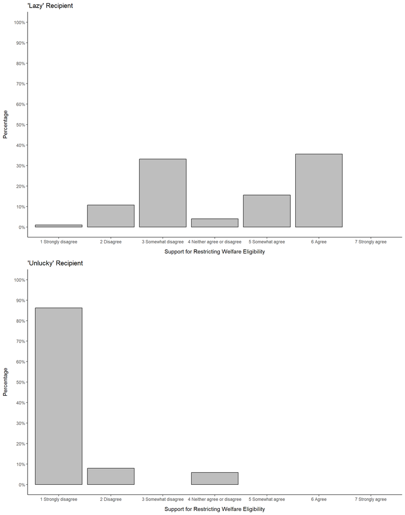

**NOTE**: Comparison of support for restricting welfare eligibility across group conditions. $n$ = 1,009. Results derived from synthetic data generated by OpenAI’s (2024a) gpt-4o-mini using vignettes and questions created by Aarøe and Petersen (2014) and Petersen et al. (2012), as well as data by the IPUMS (Ruggles et al. 2024) and ANES (2021).

### 10.5.2 Simultaneity Test

This section gives an overview of the diagnostics and estimates from the Bayesian Generalized Linear Model (BGLM) used to test the simultaneity assumption (see table 4.8). A traceplot of chain convergence of this model is provided graphically in 10.20. The model’s goodness-of-fit is provided as a posterior predictive plot in figure 10.21, with explained variance ($R^2$, cf. Gelman et al. 2019) *not* being reported due to being entirely invariant. Building on Bowley (1910) and Tukey (1910), a 13-number summary of the estimated mean time difference ($\hat{\delta}$) is provided in table 10.20 and visually in figure 10.22, while the estimated dispersion ($\hat{\varsigma}$) is provided in table 10.21 and figure 10.23. When possible and meaningful, the mode, median, mean, *interquartile range* (IQR), *skewness*, *kurtosis*, *posterior predictive p-value* ($PP_P$, Gelman et al. 1996), chain convergence ($\hat{R}$, Gelman and Rubin 1992; Vehtari et al. 2021), *effective sample size* (ESS, Bürkner 2017), and *Monte-Carlo Standard Error* (MCSE, Kruschke 2014) are listed in the table notes.

#### 10.5.2.1 Model Diagnostics

Figure 10.20: Chain Convergence of the Simultaneity Test BGLM

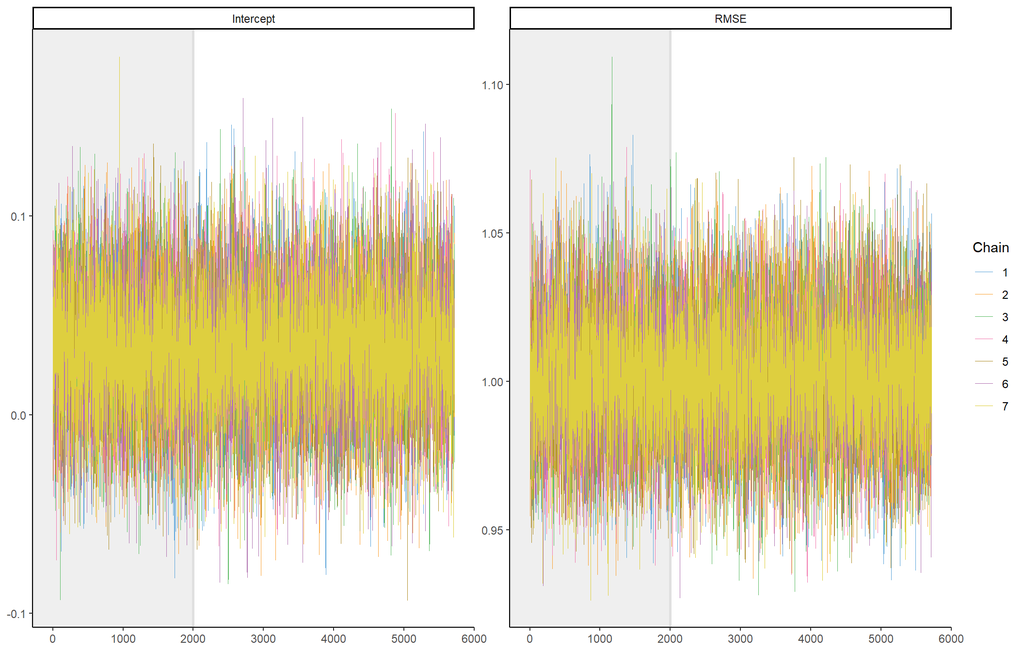

Figure 10.21: Posterior Predictive Distribution of the Simultaneity Test BGLM

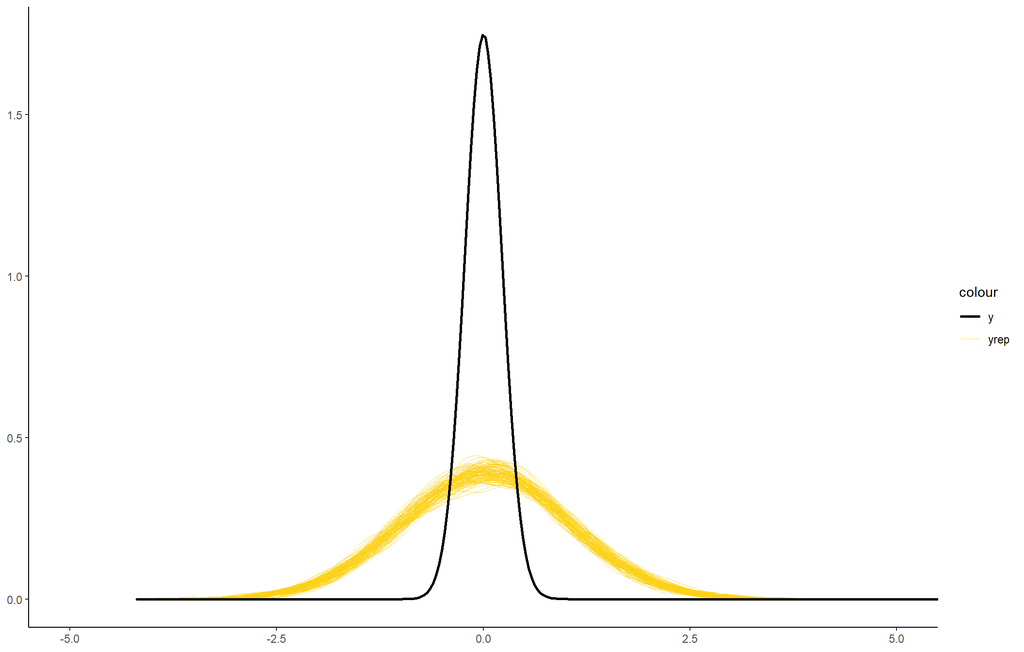

#### 10.5.2.2 Model Parameters

Table 10.20: 13-Number Summary of the Measurement Time Difference Between Manipulations Conditions

| Percentile | Posterior | Likelihood |
| --- | --- | --- |
| 0% | -0.093 | -0.002 |
| 0.1% | -0.065 | -0.001 |
| 1% | -0.041 | 0.000 |
| 5% | -0.019 | 0.001 |
| 10% | -0.007 | 0.001 |
| 25% | 0.012 | 0.002 |
| 50% | 0.033 | 0.033 |
| 75% | 0.054 | 0.063 |
| 90% | 0.073 | 0.066 |
| 95% | 0.085 | 0.096 |
| 99% | 0.107 | 0.128 |
| 99.9% | 0.130 | 0.160 |
| 100% | 0.180 | 0.222 |

**NOTE**: Posterior and (maximum) likelihood distributions of the estimated mean parameter ($\hat{\delta}$), estimated with NUTS MCMC (Hoffman and Gelman 2014) and OLS-based non-parametric bootstrap (Efron and Tibshirani 1994), respectively. Posterior/likelihood samples = 40,005. Mean = .033 and .033, respectively. IQR = .042 and .061, respectively. Skewness = .004 and .994, respectively. Kurtosis = 1.001 and .041, respectively. Results derived from synthetic data generated by OpenAI’s (2024a) gpt-4o-mini using vignettes and questions created by Aarøe and Petersen (2014) and Petersen et al. (2012), as well as data by the IPUMS (Ruggles et al. 2024) and ANES (2021).

Figure 10.22: Measurement Time Difference Between Manipulations Conditions

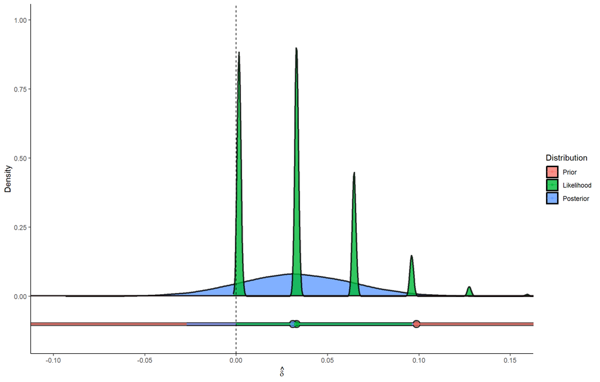

**NOTE**: Posterior, (maximum) likelihood, and prior distributions of the estimated intercept mean parameter ($\hat{\delta}$) in time difference standard deviations. Posterior/likelihood/prior samples = 40,005; prior is not necessarily correctly visualized due to finite samples. To visualize posterior and likelihood distributions, the prior distributions is not visible due to being substantially wider than both. The dashed black line indicates a time difference of zero. The geometric below the distributions indicate the posterior mode (circle) and the 95% HDCI (thick bar). Results derived from synthetic data generated by OpenAI’s (2024a) gpt-4o-mini using vignettes and questions created by Aarøe and Petersen (2014) and Petersen et al. (2012), as well as data by the IPUMS (Ruggles et al. 2024) and ANES (2021).

Table 10.21: 13-Number Summary of the Explanatory Error of the Simultaneity Test BGLM

| Percentile | Posterior | Likelihood |
| --- | --- | --- |
| 0% | 0.926 | 0.010 |
| 0.1% | 0.938 | 0.015 |
| 1% | 0.954 | 0.019 |
| 5% | 0.968 | 0.023 |
| 10% | 0.975 | 0.026 |
| 25% | 0.987 | 0.031 |
| 50% | 1.001 | 1.000 |
| 75% | 1.015 | 1.414 |
| 90% | 1.029 | 1.414 |
| 95% | 1.036 | 1.731 |
| 99% | 1.051 | 1.997 |
| 99.9% | 1.068 | 2.232 |
| 100% | 1.109 | 2.638 |

**NOTE**: Posterior and (maximum) likelihood distributions of the estimated dispersion parameter ($\hat{\varsigma}$), estimated with NUTS MCMC (Hoffman and Gelman 2014) and OLS-based non-parametric bootstrap (Efron and Tibshirani 1994), respectively. Posterior/likelihood samples = 40,005. Mean = 1.001 and .785, respectively. IQR = .028 and 1.382, respectively. Skewness = .086 and -.079, respectively. Kurtosis = -1.312 and .002, respectively. Results derived from synthetic data generated by OpenAI’s (2024a) gpt-4o-mini using vignettes and questions created by Aarøe and Petersen (2014) and Petersen et al. (2012), as well as data by the IPUMS (Ruggles et al. 2024) and ANES (2021).

Figure 10.23: Explanatory Error of the Simultaneity Test BGLM

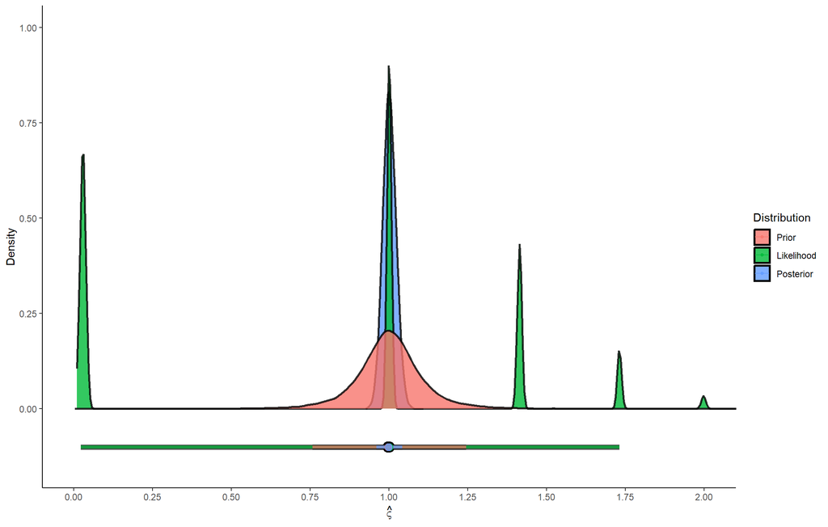

**NOTE**: Posterior, (maximum) likelihood, and prior distributions of the estimated dispersion parameter ($\hat{\varsigma}$). Posterior/likelihood/prior samples = 40,005; prior is not necessarily correctly visualized due to finite samples. The geometric below the distributions indicate the posterior mode (circle) and the 95% HDCI (thick bar). Results derived from synthetic data generated by OpenAI’s (2024a) gpt-4o-mini using vignettes and questions created by Aarøe and Petersen (2014) and Petersen et al. (2012), as well as data by the IPUMS (Ruggles et al. 2024) and ANES (2021).

### 10.5.3 Deservingness & Welfare Support

This section gives an overview of the diagnostics and estimates of the the Multilevel Bayesian Generalized Linear Model (ML-BGLM) for testing the relationship between deservingness and welfare support (see table 4.10). Building on Bowley (1910) and Tukey (1910), this includes 13-number summaries. A traceplot of chain convergence of this model is provided graphically in 10.24, while the model’s goodness-of-fit is provided as a posterior predictive distribution in figure 10.25 and as explained variance ($R^2$, cf. Gelman et al. 2019), metrically in table 10.22 and visually in figure 10.26. The estimated coefficient ($\hat{\beta_G}$) is provided metrically in table 10.23 and visually in figure 10.27, while the estimated intercept mean ($\hat{\mu_\alpha}$) and dispersion ($\hat{\sigma_\alpha}$) are provided in tables 10.24 and 10.25, and in figures 10.28 and 10.29, respectively. The model’s estimated dispersion parameter ($\hat{\sigma}$) is provided in table 10.26 and figure 10.30. The model’s estimated degrees of freedom (*df*) parameter ($\hat{\nu}$) is provided in table 10.27 and figure 10.31. When possible and meaningful, the mode, median, mean, *interquartile range* (IQR), *skewness*, *kurtosis*, *posterior predictive p-value* ($PP_P$, Gelman et al. 1996), chain convergence ($\hat{R}$, Gelman and Rubin 1992; Vehtari et al. 2021), *effective sample size* (ESS, Bürkner 2017), and *Monte-Carlo Standard Error* (MCSE, Kruschke 2014) are listed in the table notes.